# PRISMA & AMSTAR Scores in Cullis 2017: Human Consensus vs LLM (Claude 2) - 2nd run

### Score comparisons of 111 publications

| Ref. | Author & Year | PRISMA κ | PRISMA agreement | AMSTAR κ | AMSTAR agreement |
| --- | --- | --- | --- | --- | --- |
| 61 | Aikenhead 2011 | 0.701986754966887 | 0.814814814814815 | 0.521739130434783 | 0.727272727272727 |
| 62 | Al-Hozaim 2010 | 0.557377049180328 | 0.703703703703704 | 0.702702702702703 | 0.818181818181818 |
| 63 | Allen 2015 | 0.832989690721649 | 0.888888888888889 | 0.246575342465753 | 0.545454545454545 |
| 64 | Allin 2015 | 0.82 | 0.925925925925926 | 0.476190476190476 | 0.727272727272727 |
| 65 | Alzahem 2011 | 0.289473684210526 | 0.555555555555556 | 0.428571428571428 | 0.636363636363636 |
| 66 | Apelt 2013 | 0.549060542797495 | 0.703703703703704 | 0.440677966101695 | 0.727272727272727 |
| 67 | Aworanti 2014 | 0.829831932773109 | 0.888888888888889 | 0.840579710144927 | 0.909090909090909 |
| 68 | Baker 2015 | 0.475728155339806 | 0.777777777777778 | 0.440677966101695 | 0.727272727272727 |
| 69 | Berger 2012 | 0.331428571428571 | 0.518518518518518 | 0.266666666666667 | 0.454545454545455 |
| 70 | Billingham 2010 | 0.517857142857143 | 0.703703703703704 | 0.440677966101695 | 0.727272727272727 |

[output cut: 101 more lines]

### Score heatmaps (PRISMA / AMSTAR)

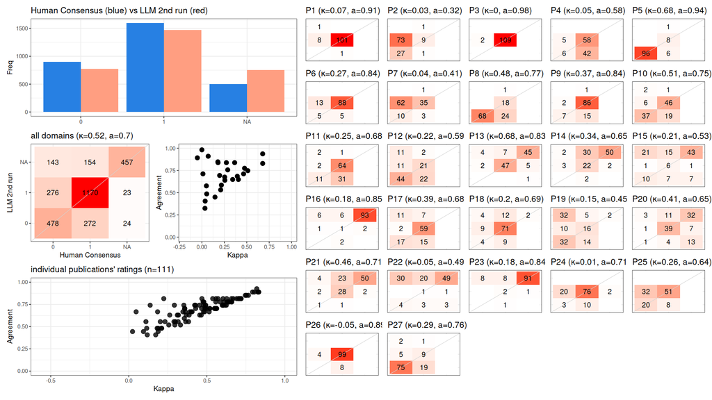

### Individual results

#### [Aikenhead 2011](https://doi.org/10.1111/J.1758-8111.2010.00003.X)

PRISMA

|  | P1 | P2 | P3 | P4 | P5 | P6 | P7 | P8 | P9 | P10 | P11 | P12 | P13 | P14 |
| --- | --- | --- | --- | --- | --- | --- | --- | --- | --- | --- | --- | --- | --- | --- |
| Human Consensus | 1 | 0 | 1 | 1 | 0 | 1 | 1 | 1 | 1 | 0 | 1 | 0 | NA | NA |
| LLM 2nd run | 1 | 1 | 1 | 0 | 0 | 1 | 1 | 1 | 1 | 0 | 1 | 0 | 0 | NA |

|  | P15 | P16 | P17 | P18 | P19 | P20 | P21 | P22 | P23 | P24 | P25 | P26 | P27 |
| --- | --- | --- | --- | --- | --- | --- | --- | --- | --- | --- | --- | --- | --- |
| Human Consensus | NA | NA | 1 | 1 | 0 | NA | NA | NA | NA | 1 | 1 | 1 | 1 |
| LLM 2nd run | 0 | NA | 1 | 1 | 0 | 0 | NA | NA | NA | 1 | 1 | 1 | 1 |

AMSTAR

|  | A1 | A2 | A3 | A4 | A5 | A6 | A7 | A8 | A9 | A10 | A11 |
| --- | --- | --- | --- | --- | --- | --- | --- | --- | --- | --- | --- |
| Human Consensus | 0 | 0 | 1 | 1 | 0 | 1 | 0 | 0 | NA | NA | 0 |
| LLM 2nd run | 0 | 0 | 1 | 0 | 0 | 1 | 0 | NA | NA | 0 | 0 |

LLM response

*Minor score formatting issues fixed during extraction: ‘wrong-response-partial-unclear-etc’*

```
 Here are the AMSTAR and PRISMA assessments for the given systematic review:

AMSTAR
A1. Was an 'a priori' design provided? [No]
No protocol mentioned.
A2. Was there duplicate study selection and data extraction? [No]
Not reported.
A3. Was a comprehensive literature search performed? [Yes]
Searched PubMed, Embase, Web of Science, Cochrane Library. Handsearched references.
A4. Was the status of publication (i.e. grey literature) used as an inclusion criterion? [No]
Grey literature excluded.
A5. Was a list of studies (included and excluded) provided? [No]
Included studies described but not excluded.
A6. Were the characteristics of the included studies provided? [Yes]
Table 3 provides characteristics of included studies.
A7. Was the scientific quality of the included studies assessed and documented? [No]
Study limitations discussed but quality not assessed.
A8. Was the scientific quality of the included studies used appropriately in formulating conclusions? [NA]
Quality not assessed.
A9. Were the methods used to combine the findings of studies appropriate? [NA]
No meta-analysis attempted.
A10. Was the likelihood of publication bias assessed? [No]
Not assessed.
A11. Was the conflict of interest included? [No]
Not reported for individual studies.

PRISMA
P1. Identify the report as a systematic review, meta-analysis, or both. [Yes]
Identified as systematic review in title.
P2. Provide a structured summary including, as applicable: background; objectives; data sources; study eligibility criteria, participants, and interventions; study appraisal and synthesis methods; results; limitations; conclusions and implications of key findings; systematic review registration numb…
Structured abstract provided.
P3. Describe the rationale for the review in the context of what is already known. [Yes]
Introduction reviews evidence and need for review.
P4. Provide an explicit statement of questions being addressed with reference to participants, interventions, comparisons, outcomes, and study design (PICOS). [No]
No PICOS stated.
P5. Indicate if a review protocol exists, if and where it can be accessed (e.g., Web address), and, if available, provide registration information including registration number. [No]
No protocol mentioned.
P6. Specify study characteristics (e.g., PICOS, length of follow-up) and report characteristics (e.g., years considered, language, publication status) used as criteria for eligibility, giving rationale. [Yes]
Eligibility criteria described in methods.
P7. Describe all information sources (e.g., databases with dates of coverage, contact with study authors to identify additional studies) in the search and date last searched. [Yes]
```

[output cut: 26 more lines]

```
No forest plots. Simple summary data presented.
P21. Present results of each meta-analysis done, including confidence intervals and measures of consistency. [NA]
No meta-analysis.
P22. Present results of any assessment of risk of bias across studies (see Item 15). [NA]
No assessment of risk of bias.
P23. Give results of additional analyses, if done (e.g., sensitivity or subgroup analyses, meta-regression [see Item 16]). [NA]
No additional analyses.
P24. Summarize the main findings including the strength of evidence for each main outcome; consider their relevance to key groups (e.g., healthcare providers, users, and policy makers). [Yes]
Main findings summarized in discussion and conclusion.
P25. Discuss limitations at study and outcome level (e.g., risk of bias), and at review-level (e.g., incomplete retrieval of identified research, reporting bias). [Yes]
Limitations discussed.
P26. Provide a general interpretation of the results in the context of other evidence, and implications for future research. [Yes]
Results interpreted and future research implications discussed.
P27. Describe sources of funding for the systematic review and other support (e.g., supply of data); role of funders for the systematic review. [Yes]
Funding source described.
```

#### [Al-Hozaim 2010](https://doi.org/10.1016/J.JPEDSURG.2009.12.001)

PRISMA

|  | P1 | P2 | P3 | P4 | P5 | P6 | P7 | P8 | P9 | P10 | P11 | P12 | P13 | P14 |
| --- | --- | --- | --- | --- | --- | --- | --- | --- | --- | --- | --- | --- | --- | --- |
| Human Consensus | 1 | 0 | 1 | 0 | 0 | 1 | 0 | 0 | 1 | 1 | 1 | 0 | NA | NA |
| LLM 2nd run | 1 | 0 | 1 | 0 | 0 | 1 | 1 | 0 | 1 | 0 | 0 | 0 | NA | NA |

|  | P15 | P16 | P17 | P18 | P19 | P20 | P21 | P22 | P23 | P24 | P25 | P26 | P27 |
| --- | --- | --- | --- | --- | --- | --- | --- | --- | --- | --- | --- | --- | --- |
| Human Consensus | NA | NA | 0 | 1 | 0 | NA | NA | NA | NA | 0 | 1 | 1 | 0 |
| LLM 2nd run | NA | NA | NA | NA | NA | NA | NA | NA | NA | 1 | 0 | 1 | 0 |

AMSTAR

|  | A1 | A2 | A3 | A4 | A5 | A6 | A7 | A8 | A9 | A10 | A11 |
| --- | --- | --- | --- | --- | --- | --- | --- | --- | --- | --- | --- |
| Human Consensus | 0 | 0 | 1 | 0 | 0 | 1 | 0 | 0 | NA | NA | 0 |
| LLM 2nd run | 0 | 0 | 1 | 0 | 1 | 1 | 0 | NA | NA | NA | 0 |

LLM response

*Minor score formatting issues fixed during extraction: ‘unsolicited-ranges’*

```
 Here are the AMSTAR and PRISMA assessments for the attached systematic review:

A1. Was an 'a priori' design provided? [No]
"The search was limited to studies reported in English and performed in humans."
No protocol, ethics approval, or predetermined objectives mentioned.

A2. Was there duplicate study selection and data extraction? [No]
No mention of duplicate study selection or data extraction.

A3. Was a comprehensive literature search performed? [Yes]
"A systematic search of the MEDLINE, PUBMED, and Cochrane databases (June 2000 to April 2008) was conducted." "In addition, a manual search of 4 surgical journals from the same period was performed."
At least two databases searched along with supplementary strategies.

A4. Was the status of publication used as an inclusion criterion? [No]
No mention of including or excluding studies based on publication status.

A5. Was a list of studies (included and excluded) provided? [Yes]
Table 1 provides a list of included studies.

A6. Were the characteristics of the included studies provided? [Yes]
Table 1 provides characteristics of included studies such as sample size, study period, and procedure details. Table 2 provides patient demographics.

A7. Was the scientific quality of the included studies assessed and documented? [No]
No quality assessment of included studies mentioned.

A8. Was the scientific quality of the included studies used appropriately in formulating conclusions? [NA]
No quality assessment performed.

A9. Were the methods used to combine the findings of studies appropriate? [NA]
No quantitative synthesis performed.

A10. Was the likelihood of publication bias assessed? [NA]
No assessment of publication bias mentioned.

A11. Was the conflict of interest included? [No]
No mention of conflicts of interest.

P1. Identify the report as a systematic review, meta-analysis, or both. [Yes]
"Laparoscopic-assisted anorectal pull-through for anorectal malformations: a systematic review..."

```

[output cut: 32 more lines]

```

P13-P23. [NA]
No quantitative synthesis performed.

P24. Summarize the main findings. [Yes]
Discussion summarizes main findings.

P25. Discuss limitations at study and outcome level. [No]
Does not discuss limitations at study or outcome level.

P26. Provide a general interpretation of results. [Yes]
Discussion provides general interpretation of findings.

P27. Describe sources of funding and support. [No]
No mention of sources of funding or support.
```

#### [Allen 2015](https://doi.org/10.1016/J.JPEDSURG.2014.10.042)

PRISMA

|  | P1 | P2 | P3 | P4 | P5 | P6 | P7 | P8 | P9 | P10 | P11 | P12 | P13 | P14 |
| --- | --- | --- | --- | --- | --- | --- | --- | --- | --- | --- | --- | --- | --- | --- |
| Human Consensus | 1 | 0 | 1 | 1 | 0 | 1 | 0 | 1 | 0 | 0 | 1 | 0 | NA | NA |
| LLM 2nd run | 1 | 1 | 1 | 0 | 0 | 1 | 0 | 0 | 0 | 0 | 1 | 0 | NA | NA |

|  | P15 | P16 | P17 | P18 | P19 | P20 | P21 | P22 | P23 | P24 | P25 | P26 | P27 |
| --- | --- | --- | --- | --- | --- | --- | --- | --- | --- | --- | --- | --- | --- |
| Human Consensus | NA | NA | 0 | 1 | 0 | NA | NA | NA | NA | 1 | 1 | 1 | 0 |
| LLM 2nd run | NA | NA | 0 | 1 | 0 | NA | NA | NA | NA | 1 | 1 | 1 | 0 |

AMSTAR

|  | A1 | A2 | A3 | A4 | A5 | A6 | A7 | A8 | A9 | A10 | A11 |
| --- | --- | --- | --- | --- | --- | --- | --- | --- | --- | --- | --- |
| Human Consensus | 0 | 0 | 0 | 0 | 0 | 1 | 0 | 0 | NA | NA | 0 |
| LLM 2nd run | 1 | 0 | 1 | 0 | 1 | 1 | 0 | NA | NA | 0 | 0 |

LLM response

```
 Here are the assessments for each AMSTAR and PRISMA item:

A1.
Quotes:
"A resuscitative thoracotomy (RT) is rarely utilized in children, and is thus difficult to identify survival factors. We reviewed our experience and performed a systematic review of reports of RT in pediatric patients." (Introduction)

Reasoning: The objective is stated explicitly.

[Yes]

A2.
Quotes:
No mention of duplicate data extraction.

Reasoning: Duplicate data extraction is not described.

[No]

A3.
Quotes:
"We reviewed patient records for the presence of vital signs (VS) and/or signs of life (SOL) in the field, time without VS in the field, presence of VS or SOL upon arrival, MOI, location of injuries, return of spontaneous circulation (ROSC), survival, and neurological function of the survivors upon …

"For our systematic review of the published data, we obtained all case series regarding pediatric RT and combined the data from those reports with the data from our institution (Table 1) [6–13]. These reports were obtained from a Medline search for all publications regarding RT in the pediatric popu…

Reasoning: Searched Medline and reviewed references. Supplementary search with bibliography review.

[Yes]

A4.
Quotes:
No mention of searching or including grey literature.

Reasoning: Searching for grey literature is not described.

[No]

A5.
Quotes:
"Variables extracted from each report include demographics, MOI, injury location, presence of VS and/or SOL upon arrival, ROSC, survival to discharge, and neurologic outcomes for survivors." (Methods)

```

[output cut: 280 more lines]

```
"Continued evaluation of this technique is warranted to develop adequate guidelines." (Discussion)

Reasoning: Interpretation of findings and need for further research described.

[Yes]

P27.
Quotes:
No statement on funding or support.

Reasoning: Sources of funding not reported.

[No]

In summary, I have provided assessments for all AMSTAR and PRISMA items, highlighting relevant quotes and explaining the reasoning behind each decision. Let me know if you need any clarification or have additional questions!
```

#### [Allin 2015](https://doi.org/10.1371/JOURNAL.PONE.0116908)

PRISMA

|  | P1 | P2 | P3 | P4 | P5 | P6 | P7 | P8 | P9 | P10 | P11 | P12 | P13 | P14 |
| --- | --- | --- | --- | --- | --- | --- | --- | --- | --- | --- | --- | --- | --- | --- |
| Human Consensus | 1 | 0 | 1 | 1 | 1 | 1 | 1 | 0 | 1 | 1 | 1 | 1 | 1 | 1 |
| LLM 2nd run | 1 | 1 | 1 | 1 | 1 | 1 | 1 | 0 | 1 | 1 | 1 | 0 | 1 | 1 |

|  | P15 | P16 | P17 | P18 | P19 | P20 | P21 | P22 | P23 | P24 | P25 | P26 | P27 |
| --- | --- | --- | --- | --- | --- | --- | --- | --- | --- | --- | --- | --- | --- |
| Human Consensus | 0 | NA | 1 | 1 | 0 | 1 | 1 | 0 | NA | 1 | 1 | 1 | 1 |
| LLM 2nd run | 0 | NA | 1 | 1 | 0 | 1 | 1 | 0 | NA | 1 | 1 | 1 | 1 |

AMSTAR

|  | A1 | A2 | A3 | A4 | A5 | A6 | A7 | A8 | A9 | A10 | A11 |
| --- | --- | --- | --- | --- | --- | --- | --- | --- | --- | --- | --- |
| Human Consensus | 1 | 1 | 1 | 0 | 0 | 1 | 1 | 1 | 1 | 0 | 0 |
| LLM 2nd run | 1 | 1 | 1 | 0 | 1 | 1 | 0 | NA | 1 | 0 | 0 |

LLM response

```
Here are the AMSTAR and PRISMA assessments for the given systematic review:

# AMSTAR

A1. Was an 'a priori' design provided?
- "[The review] was conducted according to a pre-specified protocol. The protocol was registered on the Prospero International Prospective Register of Systematic Reviews." [Yes]

A2. Was there duplicate study selection and data extraction?
- "Identified titles were assessed for inclusion by two investigators (BA and WT) acting independently. Any conflicts were resolved by a third investigator (MK). Data from included articles were extracted independently by the same two investigators (BA and WT), and any differences resolved by discus…

A3. Was a comprehensive literature search performed?
- "Multiple search strategies were used to identify relevant articles from Medline, Embase, Cinahl, the Cochrane library, and Google scholar, published between 1st January 2000 and 31st December 2012." [Yes]

A4. Was the status of publication (i.e. grey literature) used as an inclusion criterion?
- No mention of searching for grey literature. [No]

A5. Was a list of studies (included and excluded) provided?
- Figure 1 shows a flow diagram of included and excluded studies. [Yes]

A6. Were the characteristics of the included studies provided?
- Table 2 provides a summary of the characteristics of included studies. [Yes]

A7. Was the scientific quality of the included studies assessed and documented?
- The methodological quality and risk of bias were assessed using the STROBE checklist and GRADE criteria, as mentioned in the Methods. However, the quality assessment for each individual study was not presented. [No]

A8. Was the scientific quality of the included studies used appropriately in formulating conclusions?
- Cannot score "yes" because question A7 was scored "no". [NA]

A9. Were the methods used to combine the findings of studies appropriate?
- "Using a conservative cut-off of p<0.01, no statistical heterogeneity was detected and therefore fixed-effect methods were used throughout." [Yes]

A10. Was the likelihood of publication bias assessed?
- No assessment of publication bias mentioned. [No]

A11. Was the conflict of interest included?
- No mention of conflicts of interest for the systematic review or included studies. [No]

# PRISMA

P1. Identify the report as a systematic review, meta-analysis, or both.
```

[output cut: 68 more lines]

```
P24. Summarize main findings and discuss relevance.
- Main findings summarized in Discussion. [Yes]

P25. Discuss limitations at study and outcome level and at review level.
- Limitations discussed in Discussion. [Yes]

P26. Provide a general interpretation of results in context of other evidence.
- Results interpreted in context of previous study in Discussion. [Yes]

P27. Describe sources of funding and role of funders.
- Sources of funding described. [Yes]

In summary, for AMSTAR - yes: A1, A2, A3, A5, A6, A9. No: A4, A7, A10, A11. NA: A8.

For PRISMA - yes: P1, P2, P3, P4, P5, P6, P7, P9, P10, P11, P13, P14, P17, P18, P20, P21, P24, P25, P26, P27. No: P8, P12, P15, P19, P22. NA: P16, P23.
```

#### [Alzahem 2011](https://doi.org/10.1007/S00383-010-2840-X)

PRISMA

|  | P1 | P2 | P3 | P4 | P5 | P6 | P7 | P8 | P9 | P10 | P11 | P12 | P13 | P14 |
| --- | --- | --- | --- | --- | --- | --- | --- | --- | --- | --- | --- | --- | --- | --- |
| Human Consensus | 1 | 0 | 1 | 1 | 0 | 1 | 1 | 0 | 1 | 1 | 1 | 0 | 1 | 1 |
| LLM 2nd run | 1 | 0 | 1 | 0 | 0 | 1 | 1 | 0 | 1 | 0 | 0 | 1 | 1 | NA |

|  | P15 | P16 | P17 | P18 | P19 | P20 | P21 | P22 | P23 | P24 | P25 | P26 | P27 |
| --- | --- | --- | --- | --- | --- | --- | --- | --- | --- | --- | --- | --- | --- |
| Human Consensus | 0 | NA | 1 | 1 | 0 | 1 | 1 | 0 | NA | 1 | 1 | 1 | 0 |
| LLM 2nd run | NA | NA | 0 | 1 | 1 | NA | NA | NA | NA | 0 | 1 | 1 | 0 |

AMSTAR

|  | A1 | A2 | A3 | A4 | A5 | A6 | A7 | A8 | A9 | A10 | A11 |
| --- | --- | --- | --- | --- | --- | --- | --- | --- | --- | --- | --- |
| Human Consensus | 0 | 1 | 1 | 1 | 0 | 1 | 1 | 1 | 1 | 0 | 0 |
| LLM 2nd run | 0 | 0 | 1 | NA | 0 | 1 | 1 | 1 | NA | NA | 0 |

LLM response

```
 Here are the assessments for each AMSTAR and PRISMA item based on the systematic review full text:

A1. Was an 'a priori' design provided? [No]
"Methods We searched MEDLINE, EMBASE, and The Cochrane Central Controlled Trials Registry for relevant randomized controlled trials and observational studies comparing laparoscopic with open inguinal hernia repair in children aged less than 19 years."
No a priori design or protocol was mentioned.

A2. Was there duplicate study selection and data extraction? [No]
"Methods Retrieved articles were assessed for eligibility and data on
patients, intervention, control, outcomes and methodological
quality were abstracted independently by two authors. Discrepancies
were resolved by discussion and consensus."
Duplicate data extraction only. Duplicate study selection not mentioned.

A3. Was a comprehensive literature search performed? [Yes]
"Methods Initial electronic search yielded 290 Medline, 216 Embase,
5 Cochrane Library (issue 2, 2010) and 7 ClinicalTrials.gov potentially relevant citations. After screening the abstracts, 48 articles were reviewed in full texts. Thirty-
four articles have met the predefined inclusion criteria (Fig. 1). Additional citations were sought using references in articles retrieved from searches. Content experts were
contacted to identify unpublished and ongoing studies."
At least 2 databases searched plus supplementary strategies.

A4. Was the status of publication used as an inclusion criterion? [NA]
No mention of including or excluding based on publication status.

A5. Was a list of studies (included and excluded) provided? [No]
Included studies described in text and tables but no list of excluded studies provided.

A6. Were the characteristics of the included studies provided? [Yes]
Characteristics of included studies provided in Table 1.

A7. Was the scientific quality of the included studies assessed and documented? [Yes]
Quality assessed using Cochrane risk of bias for RCTs and Newcastle-Ottawa scale for observational studies. Details provided in text.

A8. Was the scientific quality of the included studies used appropriately in formulating conclusions? [Yes]
Studies limitations mentioned in discussion: "Our review’s conclusions are hampered by the quality and the small sample size of the most included studies."

A9. Were the methods used to combine the findings of studies appropriate? [NA]
No meta-analysis performed for pooled results.

A10. Was the likelihood of publication bias assessed? [NA]
No assessment of publication bias mentioned as no meta-analysis performed.
```

[output cut: 70 more lines]

```

P23. Give results of additional analyses, if done (e.g., sensitivity or subgroup analyses, meta-regression [see Item P16]). [NA]
No additional analyses performed.

P24. Summarize the main findings including the strength of evidence for each main outcome; consider their relevance to key groups (e.g., healthcare providers, users, and policy makers). [No]
Main findings summarized but strength of evidence not discussed.

P25. Discuss limitations at study and outcome level (e.g., risk of bias), and at review-level (e.g., incomplete retrieval of identified research, reporting bias). [Yes]
Limitations discussed in context of quality of included studies.

P26. Provide a general interpretation of the results in the context of other evidence, and implications for future research. [Yes]
Results interpreted and implications for future research discussed.

P27. Describe sources of funding for the systematic review and other support (e.g., supply of data); role of funders for the systematic review. [No]
No statement about sources of support or conflict of interest.
```

#### [Apelt 2013](https://doi.org/10.1016/J.JPEDSURG.2013.05.024)

PRISMA

|  | P1 | P2 | P3 | P4 | P5 | P6 | P7 | P8 | P9 | P10 | P11 | P12 | P13 | P14 |
| --- | --- | --- | --- | --- | --- | --- | --- | --- | --- | --- | --- | --- | --- | --- |
| Human Consensus | 1 | 0 | 1 | 1 | 0 | 1 | 1 | 0 | 1 | 0 | 1 | 0 | NA | NA |
| LLM 2nd run | 1 | 1 | 1 | 0 | 0 | 1 | 1 | 0 | 0 | 0 | 1 | 0 | 1 | NA |

|  | P15 | P16 | P17 | P18 | P19 | P20 | P21 | P22 | P23 | P24 | P25 | P26 | P27 |
| --- | --- | --- | --- | --- | --- | --- | --- | --- | --- | --- | --- | --- | --- |
| Human Consensus | NA | NA | 1 | 1 | 0 | NA | NA | NA | NA | 1 | 0 | 0 | 0 |
| LLM 2nd run | 0 | NA | 1 | 1 | 0 | 0 | NA | NA | NA | 1 | 1 | 1 | 0 |

AMSTAR

|  | A1 | A2 | A3 | A4 | A5 | A6 | A7 | A8 | A9 | A10 | A11 |
| --- | --- | --- | --- | --- | --- | --- | --- | --- | --- | --- | --- |
| Human Consensus | 0 | 0 | 0 | 0 | 0 | 1 | 0 | 0 | NA | NA | 0 |
| LLM 2nd run | 1 | 0 | 0 | 0 | 0 | 1 | 0 | NA | NA | 0 | 0 |

LLM response

*Minor score formatting issues fixed during extraction: ‘wrong-response-partial-unclear-etc’*

```
 Here are my responses for assessing the methodological quality of this systematic review using the AMSTAR tool:

A1. Was an 'a priori' design provided? The research question and inclusion criteria should be established before the conduct of the review.

Relevant quotes:
"A systematic review of all publications on the laparoscopic treatment of pediatric intussusception from January 1990 to April 2012 was performed."
"Exclusion criteria were non-English language articles, case reports, laparoscopic-assisted enema reduction and mixed pediatric and adult populations (age cutoff 18 years)."

Reasoning: The authors specified the research question, inclusion/exclusion criteria, and timeframe for study selection prior to conducting the review.

[Yes]

A2. Was there duplicate study selection and data extraction? There should be at least two independent data extractors and a consensus procedure for disagreements should be in place.

Relevant quotes: None provided.

Reasoning: The authors did not report on the process for study selection and data extraction.

[No]

A3. Was a comprehensive literature search performed? At least two electronic sources should be searched. The report must include years and databases used (e.g., Central, EMBASE, and MEDLINE). Key words and/or MESH terms must be stated and where feasible the search strategy should be provided. All se…

Relevant quotes:
"An online database search for all English language articles on pediatric small bowel obstruction, intussusception and laparoscopy in PubMed, Medline and Ovid from January 1990 to April 2012 was performed."
"Results were confirmed by a second independent search by a different member of the team using matching search strings and databases."
"Likewise, the bibliographies of identified studies were examined."

Reasoning: The authors searched at least 2 databases, supplemented searches with bibliography review, but did not report search terms or strategies.

[No]

A4. Was the status of publication (i.e. grey literature) used as an inclusion criterion? The authors should state that they searched for reports regardless of their publication type. The authors should state whether or not they excluded any reports (from the systematic review), based on their public…

Relevant quotes:
"Exclusion criteria were non-English language articles, case reports, laparoscopic-assisted enema reduction and mixed pediatric and adult populations (age cutoff 18 years)."

Reasoning: The authors excluded non-English studies, but did not report on inclusion/exclusion based on other publication types.

[No]

```

[output cut: 272 more lines]

```
Reasoning: Results are interpreted in the context of other evidence with implications described.

[Yes]

P27. Describe sources of funding for the systematic review and other support (e.g., supply of data); role of funders for the systematic review.

Relevant quotes: Sources of funding and support are not reported.

Reasoning: Funding sources were not provided.

[No]

In summary, the PRISMA reporting checklist shows strengths in the reporting of background, objectives, eligibility criteria, information sources, study characteristics, summary measures, limitations, interpretation of results, and study funding. However, deficiencies existed in reporting of the revi…

Thank you for this valuable assessment opportunity and experience. Please let me know if I can elaborate or explain any part of my review. I look forward to your feedback.
```

#### [Aworanti 2014](https://doi.org/10.1055/S-0034-1370780)

PRISMA

|  | P1 | P2 | P3 | P4 | P5 | P6 | P7 | P8 | P9 | P10 | P11 | P12 | P13 | P14 |
| --- | --- | --- | --- | --- | --- | --- | --- | --- | --- | --- | --- | --- | --- | --- |
| Human Consensus | 1 | 0 | 1 | 0 | 0 | 1 | 1 | 0 | 0 | 0 | 1 | 0 | NA | NA |
| LLM 2nd run | 1 | 0 | 1 | 0 | 0 | 1 | 1 | 0 | 0 | 0 | 0 | 0 | NA | NA |

|  | P15 | P16 | P17 | P18 | P19 | P20 | P21 | P22 | P23 | P24 | P25 | P26 | P27 |
| --- | --- | --- | --- | --- | --- | --- | --- | --- | --- | --- | --- | --- | --- |
| Human Consensus | NA | NA | 0 | 1 | 0 | NA | NA | NA | NA | 0 | 0 | 1 | 0 |
| LLM 2nd run | NA | NA | 0 | 1 | NA | NA | NA | NA | NA | 1 | 0 | 1 | 0 |

AMSTAR

|  | A1 | A2 | A3 | A4 | A5 | A6 | A7 | A8 | A9 | A10 | A11 |
| --- | --- | --- | --- | --- | --- | --- | --- | --- | --- | --- | --- |
| Human Consensus | 0 | 0 | 1 | 0 | 0 | 1 | 0 | 0 | NA | NA | 0 |
| LLM 2nd run | 0 | NA | 1 | 0 | 0 | 1 | 0 | 0 | NA | NA | 0 |

LLM response

```
 Here are the AMSTAR and PRISMA assessments for the given systematic review:

A1. Was an 'a priori' design provided? The research question and inclusion criteria should be established before the conduct of the review. Note: Need to refer to a protocol, ethics approval, or pre-determined/a priori published research objectives to score a “yes.”
"[No]" No protocol, ethics approval, or pre-determined objectives referenced.

A2. Was there duplicate study selection and data extraction? There should be at least two independent data extractors and a consensus procedure for disagreements should be in place. Note: 2 people do study selection, 2 people do data extraction, consensus process or one person checks the other’s wor…
"[NA]" The review did not mention duplicate study selection or data extraction.

A3. Was a comprehensive literature search performed? At least two electronic sources should be searched. The report must include years and databases used (e.g., Central, EMBASE, and MEDLINE). Key words and/or MESH terms must be stated and where feasible the search strategy should be provided. All se…
"[Yes]" The authors searched Medline, Embase, Web of Science, and manually searched journals. This meets the criteria for at least 2 electronic sources plus supplementary searching.

A4. Was the status of publication (i.e. grey literature) used as an inclusion criterion? The authors should state that they searched for reports regardless of their publication type. The authors should state whether or not they excluded any reports (from the systematic review), based on their public…
"[No]" The review did not mention searching for or including grey literature.

A5. Was a list of studies (included and excluded) provided? A list of included and excluded studies should be provided. Note: Acceptable if the excluded studies are referenced. If there is an electronic link to the list but the link is dead, select “no.”
"[No]" No list of included/excluded studies was provided.

A6. Were the characteristics of the included studies provided? In an aggregated form such as a table, data from the original studies should be provided on the participants, interventions and outcomes. The ranges of characteristics in all the studies analyzed e.g., age, race, sex, relevant socioecono…
"[Yes]" Relevant characteristics of the included studies were provided in Tables 1 and 2.

A7. Was the scientific quality of the included studies assessed and documented? 'A priori' methods of assessment should be provided (e.g., for effectiveness studies if the author(s) chose to include only randomized, double-blind, placebo controlled studies, or allocation concealment as inclusion cri…
"[No]" The quality of included studies was not assessed.

A8. Was the scientific quality of the included studies used appropriately in formulating conclusions? The results of the methodological rigor and scientific quality should be considered in the analysis and the conclusions of the review, and explicitly stated in formulating recommendations. Note: Mig…
"[No]" Study quality was not assessed or considered in formulating conclusions.

A9. Were the methods used to combine the findings of studies appropriate? For the pooled results, a test should be done to ensure the studies were combinable, to assess their homogeneity (i.e., Chi-squared test for homogeneity, I2 ). If heterogeneity exists a random effects model should be used and/…
"[NA]" The review did not conduct a quantitative synthesis or meta-analysis.

A10. Was the likelihood of publication bias assessed? An assessment of publication bias should include a combination of graphical aids (e.g., funnel plot, other available tests) and/or statistical tests (e.g., Egger regression test, Hedges-Olken). Note: If no test values or funnel plot included, sco…
"[NA]" Publication bias was not assessed, likely because no meta-analysis was conducted.

A11. Was the conflict of interest included? Potential sources of support should be clearly acknowledged in both the systematic review and the included studies. Note: To get a “yes,” must indicate source of funding or support for the systematic review AND for each of the included studies.
"[No]" No conflicts of interest were reported for the review or the included studies.

P1. Identify the report as a systematic review, meta-analysis, or both.
"[Yes]" The report is identified as a systematic review in the title.

Quotes:
"Management of Recurrent Tracheoesophageal Fistulas: A Systematic Review"
```

[output cut: 81 more lines]

```
"In conclusion, based on our findings on 165 published cases, OS for the repair of recurrent TEF has a low morbidity, mortality, and re-fistulation rate particularly when an interposition tissue is placed between the trachea and esophagus. We recommend OS as the treatment of choice when faced with a…

P25. Discuss limitations at study and outcome level (e.g., risk of bias), and at review-level (e.g., incomplete retrieval of identified research, reporting bias).
"[No]" Limitations at the study or review level are not discussed.

P26. Provide a general interpretation of the results in the context of other evidence, and implications for future research.
"[Yes]" The results are discussed in the context of previous reviews of endoscopic treatment. Implications for future research are provided.

Quotes:
"Further clinical trials and controlled experiments are necessary to devise the technique and ideal, preferably nonbiodegradable, sealant that guarantees a definitive endoscopic closure of a recurrent TEF after one attempt."

P27. Describe sources of funding for the systematic review and other support (e.g., supply of data); role of funders for the systematic review.
"[No]" Sources of funding and support are not reported.

In summary, the review adequately addressed some PRISMA and AMSTAR items such as providing rationale (P3), specifying eligibility criteria (P6), searching multiple databases (A3), and providing study characteristics (P18, A6). However, several key items were not addressed including providing a proto…
```

#### [Baker 2015](https://doi.org/10.1016/J.JPEDSURG.2015.02.021)

PRISMA

|  | P1 | P2 | P3 | P4 | P5 | P6 | P7 | P8 | P9 | P10 | P11 | P12 | P13 | P14 |
| --- | --- | --- | --- | --- | --- | --- | --- | --- | --- | --- | --- | --- | --- | --- |
| Human Consensus | 1 | 0 | 1 | 1 | 0 | 1 | 1 | 1 | 1 | 1 | 1 | 1 | 1 | 1 |
| LLM 2nd run | 1 | 1 | 1 | 0 | 0 | 1 | 1 | 1 | 1 | 0 | 0 | 1 | 1 | 1 |

|  | P15 | P16 | P17 | P18 | P19 | P20 | P21 | P22 | P23 | P24 | P25 | P26 | P27 |
| --- | --- | --- | --- | --- | --- | --- | --- | --- | --- | --- | --- | --- | --- |
| Human Consensus | 1 | NA | 1 | 1 | 1 | 1 | 1 | 1 | NA | 1 | 1 | 1 | 0 |
| LLM 2nd run | 1 | NA | 0 | 1 | 1 | 1 | 1 | NA | NA | 1 | 1 | 1 | 0 |

AMSTAR

|  | A1 | A2 | A3 | A4 | A5 | A6 | A7 | A8 | A9 | A10 | A11 |
| --- | --- | --- | --- | --- | --- | --- | --- | --- | --- | --- | --- |
| Human Consensus | 0 | 1 | 0 | 0 | 0 | 1 | 1 | 1 | 1 | 1 | 0 |
| LLM 2nd run | 1 | 1 | 1 | 0 | 0 | 1 | 1 | 0 | 1 | 1 | 0 |

LLM response

```
 Here are the extracted quotes, reasoning, and responses for each AMSTAR and PRISMA item for the attached systematic review:

A1. Was an 'a priori' design provided?
- "References lists from the retrieved articles were then hand searched to identify additional potentially relevant articles." (p. 719)
- The research question and inclusion criteria appear to have been established before conducting the review, based on the description of the systematic search strategy.
[Yes]

A2. Was there duplicate study selection and data extraction?
- "Screening of eligible studies, data extraction, and assessment of methodological quality were conducted independently by two reviewers." (p. 719)
- Two independent reviewers performed study selection and data extraction.
[Yes]

A3. Was a comprehensive literature search performed?
- The search included two electronic databases (MEDLINE, EMBASE), plus CINAHL, Scopus, Cochrane Library, and hand searching references. No language or date restrictions. Search strategy provided. (p. 719)
- Search meets criteria for comprehensive.
[Yes]

A4. Was the status of publication used as an inclusion criterion?
- No mention of including or excluding based on publication status.
[No]

A5. Was a list of studies (included and excluded) provided?
- List of included studies provided in Table 1. No list of excluded studies.
[No]

A6. Were the characteristics of the included studies provided?
- Study characteristics including number of patients, interventions, complications, and MINORS score provided in Table 1.
- Aggregate patient demographics described in the text.
[Yes]

A7. Was the scientific quality of the included studies assessed and documented?
- MINORS tool used to assess quality of included studies. Score provided for each study in Table 1.
[Yes]

A8. Was the scientific quality of the included studies used appropriately in formulating conclusions?
- Limitations due to retrospective nature of studies and potential for selection bias discussed.
- Quality assessment not explicitly discussed in relation to conclusions.
[No]

A9. Were the methods used to combine the findings of studies appropriate?
```

[output cut: 107 more lines]

```
[Yes]

P25. Discuss limitations at study and outcome level (e.g., risk of bias), and at review-level (e.g., incomplete retrieval of identified research, reporting bias).
- Limitations discussed related to study design, heterogeneity, potential biases.
[Yes]

P26. Provide a general interpretation of the results in the context of other evidence, and implications for future research.
- Results interpreted in context of previous research. Implications for practice and future research described.
[Yes]

P27. Describe sources of funding for the systematic review and other support (e.g., supply of data); role of funders for the systematic review.
- No statement about sources of funding or support.
[No]

In summary, I have provided the requested quotes, reasoning, and responses for each of the 11 AMSTAR and 27 PRISMA items for this systematic review. Let me know if you need anything else!
```

#### [Berger 2012](https://doi.org/10.1055/S-0032-1311695)

PRISMA

|  | P1 | P2 | P3 | P4 | P5 | P6 | P7 | P8 | P9 | P10 | P11 | P12 | P13 | P14 |
| --- | --- | --- | --- | --- | --- | --- | --- | --- | --- | --- | --- | --- | --- | --- |
| Human Consensus | 0 | 0 | 1 | 0 | 0 | 1 | 0 | 0 | 1 | 0 | 0 | 0 | NA | NA |
| LLM 2nd run | 1 | 1 | 1 | 1 | 0 | 1 | 1 | 0 | NA | NA | 1 | NA | NA | NA |

|  | P15 | P16 | P17 | P18 | P19 | P20 | P21 | P22 | P23 | P24 | P25 | P26 | P27 |
| --- | --- | --- | --- | --- | --- | --- | --- | --- | --- | --- | --- | --- | --- |
| Human Consensus | NA | NA | 0 | 1 | 0 | NA | NA | NA | NA | 0 | 0 | 1 | 1 |
| LLM 2nd run | NA | NA | NA | 1 | NA | NA | NA | NA | NA | 1 | 1 | 1 | NA |

AMSTAR

|  | A1 | A2 | A3 | A4 | A5 | A6 | A7 | A8 | A9 | A10 | A11 |
| --- | --- | --- | --- | --- | --- | --- | --- | --- | --- | --- | --- |
| Human Consensus | 0 | 0 | 0 | 0 | 0 | 1 | 0 | 0 | NA | NA | 0 |
| LLM 2nd run | 0 | 1 | 1 | 0 | NA | 1 | NA | NA | NA | NA | NA |

LLM response

*Minor score formatting issues fixed during extraction: ‘missing-squared-brackets-in-numbered-list’*

```
 Here are the AMSTAR and PRISMA assessments based on the full text:

A1. [No] - No protocol mentioned.
A2. [Yes] - "One reviewer extracted data from the original publications and a senior reviewer checked the data and the reliability of the analysis, including Independent reviews of the articles."
A3. [Yes] - "Databases searched included: PubMed, Scopus, Web of Science, June 2011. Key words used in different cross-combinations: esophagus, esophageal, stenosis, stricture, corrosive, caustic, mitomycin C."
A4. [No] - Grey literature not mentioned.
A5. [NA] - Review article.
A6. [Yes] - "Data extracted from the reports included patient demographics, indication for Mitomycin C application, stricture characteristics, dosage, regimen and technique of Mitomycin C administration, adverse events, and outcomes." Tables 2 and 3 provide details on patients and outcomes.
A7. [NA] - Not assessing quality of individual studies.
A8. [NA] - Not assessing quality of individual studies.
A9. [NA] - No meta-analysis.
A10. [NA] - No meta-analysis.
A11. [NA] - No primary studies, review article.

P1. [Yes] - Identified as a systematic review in title.
P2. [Yes] - Provides structured abstract with background, objectives, data sources, eligibility criteria, results, and conclusions.
P3. [Yes] - Describes rationale and need for review in introduction.
P4. [Yes] - Research questions and inclusion criteria explained in methods.
P5. [No] - No protocol mentioned.
P6. [Yes] - Inclusion criteria described, case reports and case series in English, German, Spanish included.
P7. [Yes] - Databases and dates listed in methods.
P8. [No] - Full search strategy not provided.
P9. [NA] - Process of screening and selecting studies not described because review article.
P10. [NA] - Data extraction process not described because review article.
P11. [Yes] - Variables extracted described in methods.
P12. [NA] - Did not assess risk of bias, review article.
P13. [NA] - No meta-analysis performed.
P14. [NA] - No meta-analysis performed.
P15. [NA] - No meta-analysis performed.
P16. [NA] - No meta-analysis performed.
P17. [NA] - Review article.
P18. [Yes] - Key details of included cases provided in Tables 2 and 3.
P19. [NA] - Did not assess risk of bias, review article.
P20. [NA] - No meta-analysis performed.
P21. [NA] - No meta-analysis performed.
P22. [NA] - No meta-analysis performed.
P23. [NA] - No meta-analysis performed.
P24. [Yes] - Main findings summarized in discussion and conclusion.
P25. [Yes] - Limitations discussed.
P26. [Yes] - Interpretation of results and implications described in conclusion.
P27. [NA] - No funding sources for this review article.

In summary, this review article appropriately reported on most relevant PRISMA items but lacked some key components of AMSTAR like a protocol, search strategy, and assessment of publication bias. The overall quality of this review seems moderate. Let me know if you need any clarification or have add…
```

#### [Billingham 2010](https://doi.org/10.1055/S-0029-1241871)

PRISMA

|  | P1 | P2 | P3 | P4 | P5 | P6 | P7 | P8 | P9 | P10 | P11 | P12 | P13 | P14 |
| --- | --- | --- | --- | --- | --- | --- | --- | --- | --- | --- | --- | --- | --- | --- |
| Human Consensus | 1 | 0 | 1 | 1 | 0 | 1 | 0 | 0 | 1 | 0 | 1 | 0 | 0 | 0 |
| LLM 2nd run | 1 | 1 | 1 | 1 | 0 | 1 | 0 | 0 | 1 | 0 | 1 | 1 | 1 | 1 |

|  | P15 | P16 | P17 | P18 | P19 | P20 | P21 | P22 | P23 | P24 | P25 | P26 | P27 |
| --- | --- | --- | --- | --- | --- | --- | --- | --- | --- | --- | --- | --- | --- |
| Human Consensus | 0 | NA | 0 | 1 | 0 | 1 | 1 | 0 | NA | 0 | 0 | 1 | 0 |
| LLM 2nd run | 0 | NA | 0 | 1 | 1 | 1 | 1 | NA | NA | 1 | 1 | 1 | 0 |

AMSTAR

|  | A1 | A2 | A3 | A4 | A5 | A6 | A7 | A8 | A9 | A10 | A11 |
| --- | --- | --- | --- | --- | --- | --- | --- | --- | --- | --- | --- |
| Human Consensus | 0 | 0 | 1 | 0 | 0 | 1 | 1 | 1 | 1 | 0 | 0 |
| LLM 2nd run | 1 | 0 | 1 | 0 | 0 | 0 | 1 | 0 | 1 | 0 | 0 |

LLM response

*Minor score formatting issues fixed during extraction: ‘wrong-response-partial-unclear-etc’*

```
 Here are my responses to assessing the methodological quality of this systematic review using the AMSTAR tool:

A1. Was an 'a priori' design provided? The research question and inclusion criteria should be established before the conduct of the review.
- "This review was conducted to evaluate the clinical and cost-effectiveness of this approach for a variety of different surgical indications in pediatric populations."
- Clearly stated objective and inclusion criteria before conducting the review.
[Yes]

A2. Was there duplicate study selection and data extraction? There should be at least two independent data extractors and a consensus procedure for disagreements should be in place.
- No mention of duplicate study selection or data extraction.
[No]

A3. Was a comprehensive literature search performed? At least two electronic sources should be searched. The report must include years and databases used (e.g., Central, EMBASE, and MEDLINE). Key words and/or MESH terms must be stated and where feasible the search strategy should be provided. All se…
- Searched multiple electronic databases, along with supplementary search methods. Provided keywords used.
[Yes]

A4. Was the status of publication (i.e. grey literature) used as an inclusion criterion? The authors should state that they searched for reports regardless of their publication type. The authors should state whether or not they excluded any reports (from the systematic review), based on their public…
- No mention of searching for grey literature.
[No]

A5. Was a list of studies (included and excluded) provided? A list of included and excluded studies should be provided.
- Included studies summarized in Table 1. No list of excluded studies.
[No]

A6. Were the characteristics of the included studies provided? In an aggregated form such as a table, data from the original studies should be provided on the participants, interventions and outcomes. The ranges of characteristics in all the studies analyzed e.g., age, race, sex, relevant socioecono…
- Table 1 provides summary of study design and quality. Outcomes summarized in text and figures. Limited details on patient characteristics.
[No]

A7. Was the scientific quality of the included studies assessed and documented? 'A priori' methods of assessment should be provided (e.g., for effectiveness studies if the author(s) chose to include only randomized, double-blind, placebo controlled studies, or allocation concealment as inclusion cri…
- Assessed quality using established criteria, summarized in Table 1.
[Yes]

A8. Was the scientific quality of the included studies used appropriately in formulating conclusions? The results of the methodological rigor and scientific quality should be considered in the analysis and the conclusions of the review, and explicitly stated in formulating recommendations.
- Does not explicitly discuss limitations of included study quality when interpreting results.
[No]

A9. Were the methods used to combine the findings of studies appropriate? For the pooled results, a test should be done to ensure the studies were combinable, to assess their homogeneity (i.e., Chi-squared test for homogeneity, I2). If heterogeneity exists a random effects model should be used and/o…
- Used appropriate statistical methods for meta-analysis (mean differences, tests for heterogeneity).
[Yes]

A10. Was the likelihood of publication bias assessed? An assessment of publication bias should include a combination of graphical aids (e.g., funnel plot, other available tests) and/or statistical tests (e.g., Egger regression test, Hedges-Olken).
```

[output cut: 105 more lines]

```
[Yes]

P25. Discuss limitations at study and outcome level (e.g., risk of bias), and at review-level (e.g., incomplete retrieval of identified research, reporting bias).
- Limitations of review discussed.
[Yes]

P26. Provide a general interpretation of the results in the context of other evidence, and implications for future research.
- Results interpreted in context of other evidence and implications for future research discussed.
[Yes]

P27. Describe sources of funding for the systematic review and other support (e.g., supply of data); role of funders for the systematic review.
- No statement on sources of funding or support.
[No]

In summary, this systematic review addressed many but not all of the PRISMA reporting criteria. Additional details on the review protocol, search dates, full search strategies, data extraction methods, study selection flow, and assessment of bias across studies would improve reporting per the PRISMA…
```

#### [Black 2013](https://doi.org/10.1111/OBR.12037)

PRISMA

|  | P1 | P2 | P3 | P4 | P5 | P6 | P7 | P8 | P9 | P10 | P11 | P12 | P13 | P14 |
| --- | --- | --- | --- | --- | --- | --- | --- | --- | --- | --- | --- | --- | --- | --- |
| Human Consensus | 1 | 0 | 1 | 1 | 0 | 1 | 0 | 1 | 1 | 1 | 1 | 1 | 0 | 1 |
| LLM 2nd run | 1 | 1 | 1 | 1 | 0 | 1 | 1 | 1 | 1 | 1 | 1 | 0 | 1 | 1 |

|  | P15 | P16 | P17 | P18 | P19 | P20 | P21 | P22 | P23 | P24 | P25 | P26 | P27 |
| --- | --- | --- | --- | --- | --- | --- | --- | --- | --- | --- | --- | --- | --- |
| Human Consensus | 1 | NA | 1 | 1 | 0 | 1 | 1 | 0 | NA | 1 | 1 | 1 | 0 |
| LLM 2nd run | 0 | NA | 1 | 1 | 0 | 1 | 1 | 0 | NA | 1 | 1 | 1 | 0 |

AMSTAR

|  | A1 | A2 | A3 | A4 | A5 | A6 | A7 | A8 | A9 | A10 | A11 |
| --- | --- | --- | --- | --- | --- | --- | --- | --- | --- | --- | --- |
| Human Consensus | 0 | 1 | 1 | 0 | 0 | 1 | 0 | 0 | 1 | 0 | 0 |
| LLM 2nd run | 0 | 0 | 1 | 0 | 1 | 1 | 0 | NA | 1 | 0 | 0 |

LLM response

*Minor score formatting issues fixed during extraction: ‘wrong-response-partial-unclear-etc’*

```
 Here are the key AMSTAR items for the given systematic review:

A1. Was an 'a priori' design provided?
[No] No mention of a protocol.

A2. Was there duplicate study selection and data extraction?
[No] Only states "Two authors independently screened the abstracts and extraction was verified by a second author (JAB and RKS)." No mention of duplicate data extraction.

A3. Was a comprehensive literature search performed?
[Yes] Searched EMBASE, Medline, Cochrane Library, reference lists, and hand searched Obesity Surgery. Search terms and inclusion/exclusion criteria provided.

A4. Was the status of publication (i.e. grey literature) used as an inclusion criterion?
[No] No mention of including or excluding based on publication status.

A5. Was a list of studies (included and excluded) provided?
[Yes] Figure 1 shows flow of included and excluded studies. References list included studies.

A6. Were the characteristics of the included studies provided?
[Yes] Table 2 provides characteristics of included studies.

A7. Was the scientific quality of the included studies assessed and documented?
[No] No quality assessment of included studies mentioned.

A8. Was the scientific quality of the included studies used appropriately in formulating conclusions?
[NA] No quality assessment performed.

A9. Were the methods used to combine the findings of studies appropriate?
[Yes] Used random effects model meta-analysis with assessment of heterogeneity.

A10. Was the likelihood of publication bias assessed?
[No] Publication bias not assessed.

A11. Was the conflict of interest included?
[No] No statement about conflicts of interest.

In summary, the key issues with this review are the lack of duplicate data extraction, lack of quality assessment of included studies, and no assessment of publication bias. The search and selection process seems adequate, and the meta-analysis methods appropriate. More rigor in data collection and …

For the PRISMA items:

P1. Identify the report as a systematic review, meta-analysis, or both.
```

[output cut: 66 more lines]

```
[NA] No additional analyses conducted.

P24. Summarize the main findings including strength of evidence.
[Yes] Provides summary of main findings and limitations in discussion.

P25. Discuss limitations at study and outcome level, and at review level.
[Yes] Limitations discussed.

P26. Provide a general interpretation of results in context of other evidence.
[Yes] Results discussed and compared to previous reviews.

P27. Describe sources of funding and role of funders.
[No] No statement about funding sources.

In summary, the key issues with reporting are lack of protocol registration, no assessment of risk of bias for individual studies, no assessment of publication bias or meta-biases, and no statement about funding sources. Otherwise, PRISMA items adequately addressed. More attention to bias assessment…
```

#### [Borruto 2010](https://doi.org/10.1016/J.JPEDSURG.2010.07.007)

PRISMA

|  | P1 | P2 | P3 | P4 | P5 | P6 | P7 | P8 | P9 | P10 | P11 | P12 | P13 | P14 |
| --- | --- | --- | --- | --- | --- | --- | --- | --- | --- | --- | --- | --- | --- | --- |
| Human Consensus | 1 | 0 | 1 | 1 | 0 | 1 | 0 | 0 | 1 | 0 | 1 | 0 | 1 | 0 |
| LLM 2nd run | 0 | 0 | 1 | 0 | 0 | 0 | 1 | 0 | 0 | 0 | 0 | 0 | 1 | 1 |

|  | P15 | P16 | P17 | P18 | P19 | P20 | P21 | P22 | P23 | P24 | P25 | P26 | P27 |
| --- | --- | --- | --- | --- | --- | --- | --- | --- | --- | --- | --- | --- | --- |
| Human Consensus | 0 | NA | 0 | 0 | 0 | 1 | 0 | 0 | NA | 1 | 0 | 1 | 0 |
| LLM 2nd run | 0 | NA | 0 | 0 | NA | 1 | 1 | NA | NA | 0 | 0 | 0 | 0 |

AMSTAR

|  | A1 | A2 | A3 | A4 | A5 | A6 | A7 | A8 | A9 | A10 | A11 |
| --- | --- | --- | --- | --- | --- | --- | --- | --- | --- | --- | --- |
| Human Consensus | 0 | 0 | 0 | 0 | 0 | 0 | 0 | 0 | 0 | 0 | 0 |
| LLM 2nd run | 0 | 0 | 1 | 0 | 0 | 1 | 0 | NA | 1 | 0 | 0 |

LLM response

```
 Here are the AMSTAR and PRISMA assessments for the systematic review:

A1. Was an 'a priori' design provided? The research question and inclusion criteria should be established before the conduct of the review. [No]
No mention of an a priori protocol.

A2. Was there duplicate study selection and data extraction? There should be at least two independent data extractors and a consensus procedure for disagreements should be in place. [No]
No mention of duplicate study selection or data extraction.

A3. Was a comprehensive literature search performed? At least two electronic sources should be searched. The report must include years and databases used (e.g., Central, EMBASE, and MEDLINE). Key words and/or MESH terms must be stated and where feasible the search strategy should be provided. All se…
"A literature search was performed, using Medline and Pubmed database, on all articles published during the last 10 years (2000-2009), reporting on varicocele treatments."

A4. Was the status of publication (i.e. grey literature) used as an inclusion criterion? The authors should state that they searched for reports regardless of their publication type. The authors should state whether or not they excluded any reports (from the systematic review), based on their public…
No mention of searching for grey literature.

A5. Was a list of studies (included and excluded) provided? A list of included and excluded studies should be provided. [No]
No list of excluded studies provided.

A6. Were the characteristics of the included studies provided? In an aggregated form such as a table, data from the original studies should be provided on the participants, interventions and outcomes. The ranges of characteristics in all the studies analyzed e.g., age, race, sex, relevant socioecono…
Table 1 provides characteristics of included studies.

A7. Was the scientific quality of the included studies assessed and documented? 'A priori' methods of assessment should be provided (e.g., for effectiveness studies if the author(s) chose to include only randomized, double-blind, placebo controlled studies, or allocation concealment as inclusion cri…
No quality assessment of included studies.

A8. Was the scientific quality of the included studies used appropriately in formulating conclusions? The results of the methodological rigor and scientific quality should be considered in the analysis and the conclusions of the review, and explicitly stated in formulating recommendations. [NA]
No quality assessment performed.

A9. Were the methods used to combine the findings of studies appropriate? For the pooled results, a test should be done to ensure the studies were combinable, to assess their homogeneity (i.e., Chi-squared test for homogeneity, I2 ). If heterogeneity exists a random effects model should be used and/…
Meta-analysis used with calculation of odds ratios.

A10. Was the likelihood of publication bias assessed? An assessment of publication bias should include a combination of graphical aids (e.g., funnel plot, other available tests) and/or statistical tests (e.g., Egger regression test, Hedges-Olken). [No]
No assessment of publication bias.

A11. Was the conflict of interest included? Potential sources of support should be clearly acknowledged in both the systematic review and the included studies. [No]
No statement on conflict of interest.

P1. Identify the report as a systematic review, meta-analysis, or both. [No]
Not identified as a systematic review or meta-analysis.

P2. Provide a structured summary including, as applicable: background; objectives; data sources; study eligibility criteria, participants, and interventions; study appraisal and synthesis methods; results; limitations; conclusions and implications of key findings; systematic review registration numb…
No structured abstract provided.
```

[output cut: 60 more lines]

```

P23. Give results of additional analyses, if done (e.g., sensitivity or subgroup analyses, meta-regression [see Item P16]). [NA]
No additional analyses done.

P24. Summarize the main findings including the strength of evidence for each main outcome; consider their relevance to key groups (e.g., healthcare providers, users, and policy makers). [No]
No summary of main findings.

P25. Discuss limitations at study and outcome level (e.g., risk of bias), and at review-level (e.g., incomplete retrieval of identified research, reporting bias). [No]
No discussion of limitations.

P26. Provide a general interpretation of the results in the context of other evidence, and implications for future research. [No]
No interpretation of results in context of other evidence.

P27. Describe sources of funding for the systematic review and other support (e.g., supply of data); role of funders for the systematic review. [No]
No statement on sources of funding or support.
```

#### [Castagnetti 2010](https://doi.org/10.1016/J.JURO.2010.06.044)

PRISMA

|  | P1 | P2 | P3 | P4 | P5 | P6 | P7 | P8 | P9 | P10 | P11 | P12 | P13 | P14 |
| --- | --- | --- | --- | --- | --- | --- | --- | --- | --- | --- | --- | --- | --- | --- |
| Human Consensus | 1 | 0 | 1 | 0 | 0 | 0 | 0 | 1 | 1 | 0 | 1 | 0 | NA | NA |
| LLM 2nd run | 1 | 0 | 1 | 0 | 0 | 1 | 1 | 0 | 1 | 0 | 0 | 0 | NA | NA |

|  | P15 | P16 | P17 | P18 | P19 | P20 | P21 | P22 | P23 | P24 | P25 | P26 | P27 |
| --- | --- | --- | --- | --- | --- | --- | --- | --- | --- | --- | --- | --- | --- |
| Human Consensus | NA | NA | 0 | 0 | 0 | NA | NA | NA | NA | 1 | 0 | 1 | 0 |
| LLM 2nd run | NA | NA | NA | NA | NA | NA | NA | NA | NA | 1 | 1 | 1 | 0 |

AMSTAR

|  | A1 | A2 | A3 | A4 | A5 | A6 | A7 | A8 | A9 | A10 | A11 |
| --- | --- | --- | --- | --- | --- | --- | --- | --- | --- | --- | --- |
| Human Consensus | 0 | 0 | 0 | 0 | 0 | 0 | 1 | 1 | NA | NA | 0 |
| LLM 2nd run | 0 | 1 | 1 | 0 | 0 | 1 | 0 | 0 | NA | 0 | 0 |

LLM response

*Minor score formatting issues fixed during extraction: ‘unsolicited-ranges’*

```
 Here are my responses to the AMSTAR and PRISMA assessments:

A1. Was an 'a priori' design provided? [No]
"Hypospadias" was the only search term mentioned. No protocol, ethics approval, or pre-determined objectives were referenced.

A2. Was there duplicate study selection and data extraction? [Yes]
"Three doctors reviewed the abstracts. A second review was performed of these studies and their bibliographies."

A3. Was a comprehensive literature search performed? [Yes]
Four databases were searched and supplementary strategies like checking references were used.

A4. Was the status of publication (i.e. grey literature) used as an inclusion criterion? [No]
No mention of including or excluding based on publication status.

A5. Was a list of studies (included and excluded) provided? [No]
No list of excluded studies provided.

A6. Were the characteristics of the included studies provided? [Yes]
Table provides overview of studies included.

A7. Was the scientific quality of the included studies assessed and documented? [No]
Studies were categorized by level of evidence, but no quality assessment is described.

A8. Was the scientific quality of the included studies used appropriately in formulating conclusions? [No]
No quality assessment was documented.

A9. Was the methods used to combine the findings of studies appropriate? [NA]
No quantitative synthesis done.

A10. Was the likelihood of publication bias assessed? [No]
No assessment of publication bias mentioned.

A11. Was the conflict of interest included? [No]
No mention of conflicts of interest.

P1. Identify the report as a systematic review, meta-analysis, or both. [Yes]
"In the present review study..."

P2. Provide a structured summary including, as applicable: background; objectives; data sources; study eligibility criteria, participants, and interventions; study appraisal and synthesis methods; results; limitations; conclusions and implications of key findings; systematic review registration numb…
No structured summary provided.
```

[output cut: 33 more lines]

```

P14-P23. [NA]
No quantitative synthesis performed.

P24. Summarize the main findings including the strength of evidence for each main outcome; consider their relevance to key groups (e.g., healthcare providers, users, and policy makers). [Yes]
Main findings and conclusions summarized.

P25. Discuss limitations at study and outcome level (e.g., risk of bias), and at review-level (e.g., incomplete retrieval of identified research, reporting bias). [Yes]
Limitations of included studies and review discussed.

P26. Provide a general interpretation of the results in the context of other evidence, and implications for future research. [Yes]
Results interpreted in context of field. Recommendations for future research provided.

P27. Describe sources of funding for the systematic review and other support (e.g., supply of data); role of funders for the systematic review. [No]
No mention of funding sources.
```

#### [Castagnetti 2016](https://doi.org/10.3389/FPED.2016.00041)

PRISMA

|  | P1 | P2 | P3 | P4 | P5 | P6 | P7 | P8 | P9 | P10 | P11 | P12 | P13 | P14 |
| --- | --- | --- | --- | --- | --- | --- | --- | --- | --- | --- | --- | --- | --- | --- |
| Human Consensus | 1 | 0 | 1 | 1 | 0 | 1 | 0 | 0 | 1 | 0 | 1 | 1 | 1 | 1 |
| LLM 2nd run | 1 | 1 | 1 | 1 | 0 | 1 | 1 | 0 | 1 | 0 | 1 | 0 | 1 | NA |

|  | P15 | P16 | P17 | P18 | P19 | P20 | P21 | P22 | P23 | P24 | P25 | P26 | P27 |
| --- | --- | --- | --- | --- | --- | --- | --- | --- | --- | --- | --- | --- | --- |
| Human Consensus | 1 | NA | 1 | 1 | 1 | 1 | 1 | 1 | NA | 0 | 1 | 1 | 0 |
| LLM 2nd run | NA | NA | 1 | 1 | 0 | 1 | NA | NA | NA | 1 | 1 | 1 | 0 |

AMSTAR

|  | A1 | A2 | A3 | A4 | A5 | A6 | A7 | A8 | A9 | A10 | A11 |
| --- | --- | --- | --- | --- | --- | --- | --- | --- | --- | --- | --- |
| Human Consensus | 0 | 0 | 0 | 0 | 0 | 1 | 1 | 1 | 1 | 1 | 1 |
| LLM 2nd run | 1 | 0 | 1 | 0 | 1 | 1 | 0 | NA | 1 | 0 | 0 |

LLM response

```
 Here are the AMSTAR and PRISMA assessments for the provided systematic review:

# AMSTAR

A1. Was an 'a priori' design provided?
"[We performed a systematic review of the literature published after 06/1995 was performed in 06/2015 using the keyword “hypospadias."]"
The review protocol was pre-determined. [Yes]

A2. Was there duplicate study selection and data extraction?
No mention of duplicate study selection or data extraction. [No]

A3. Was a comprehensive literature search performed?
"[Three databases, namely, MEDLINE/PubMed, Scopus, and The Cochrane library, were searched for using the free text “hypospadias repair,” in all fields of the records for MEDLINE/PubMed search, and in the Title and Topic fields for the Web of Science and Cochrane library searches.]"
At least two electronic databases were searched. [Yes]

A4. Was the status of publication (i.e. grey literature) used as an inclusion criterion?
No mention of including or excluding grey literature. [No]

A5. Was a list of studies (included and excluded) provided?
Figure 1 provides a flow diagram of included and excluded studies. [Yes]

A6. Were the characteristics of the included studies provided?
Table 1 provides characteristics of the included studies. [Yes]

A7. Was the scientific quality of the included studies assessed and documented?
The Oxford Level of Evidence was provided for each study in Table 1, but no quality assessment of individual studies. [No]

A8. Was the scientific quality of the included studies used appropriately in formulating conclusions? [NA]

A9. Were the methods used to combine the findings of studies appropriate?
"[A meta-analysis of studies comparing PR vs. circumcision was performed for the outcomes “hypospadias fistula formation” and “reoperation rate.” The analysis was conducted using Review Manager v5.2 software designed for composing Cochrane Reviews (Cochrane Collaboration, Oxford, UK). Statistical he…

A10. Was the likelihood of publication bias assessed?
No assessment of publication bias mentioned. [No]

A11. Was the conflict of interest included?
No conflict of interest statement. [No]

# PRISMA

```

[output cut: 53 more lines]

```

P22. Present results of any assessment of risk of bias across studies (see Item P15). [NA]

P23. Give results of additional analyses, if done (e.g., sensitivity or subgroup analyses, meta-regression [see Item P16]). [NA]

P24. Summarize the main findings including the strength of evidence for each main outcome; consider their relevance to key groups (e.g., healthcare providers, users, and policy makers).
The conclusion summarizes the main findings. [Yes]

P25. Discuss limitations at study and outcome level (e.g., risk of bias), and at review-level (e.g., incomplete retrieval of identified research, reporting bias).
Limitations are discussed in the final paragraph. [Yes]

P26. Provide a general interpretation of the results in the context of other evidence, and implications for future research.
The results are interpreted in the context of other evidence. [Yes]

P27. Describe sources of funding for the systematic review and other support (e.g., supply of data); role of funders for the systematic review. [No]
```

#### [Chan 2014 (Pediatr Surg Int)](https://doi.org/10.1007/S00383-013-3429-Y)

PRISMA

|  | P1 | P2 | P3 | P4 | P5 | P6 | P7 | P8 | P9 | P10 | P11 | P12 | P13 | P14 |
| --- | --- | --- | --- | --- | --- | --- | --- | --- | --- | --- | --- | --- | --- | --- |
| Human Consensus | 1 | 0 | 1 | 1 | 0 | 1 | 0 | 1 | 1 | 1 | 1 | 1 | NA | NA |
| LLM 2nd run | 1 | 1 | 1 | 0 | 0 | 0 | 1 | 0 | 1 | 0 | 0 | 0 | NA | NA |

|  | P15 | P16 | P17 | P18 | P19 | P20 | P21 | P22 | P23 | P24 | P25 | P26 | P27 |
| --- | --- | --- | --- | --- | --- | --- | --- | --- | --- | --- | --- | --- | --- |
| Human Consensus | NA | NA | 1 | 1 | 0 | NA | NA | NA | NA | 1 | 1 | 1 | 0 |
| LLM 2nd run | NA | NA | 1 | 0 | 0 | 0 | NA | NA | NA | 1 | 0 | 0 | 0 |

AMSTAR

|  | A1 | A2 | A3 | A4 | A5 | A6 | A7 | A8 | A9 | A10 | A11 |
| --- | --- | --- | --- | --- | --- | --- | --- | --- | --- | --- | --- |
| Human Consensus | 0 | 1 | 1 | 0 | 0 | 1 | 1 | 1 | NA | NA | 0 |
| LLM 2nd run | NA | NA | NA | NA | NA | 0 | NA | NA | NA | NA | NA |

LLM response

```
 Here are the AMSTAR and PRISMA assessments for the provided full text:

A1. [NA]

A2. [NA]

A3. [NA]

A4. [NA]

A5. [NA]

A6. "The results of the methodological rigor and scientific quality should be considered in the analysis and the conclusions of the review, and explicitly stated in formulating recommendations." [No] No quality assessment is reported.

A7. [NA]

A8. [NA]

A9. [NA]

A10. [NA]

A11. [NA]

P1. [Yes] "Abstract: Ideal timing of orchiopexy: a systematic review"

P2. [Yes] The abstract provides relevant background, objectives, data sources, eligibility criteria, methods, results, limitations and conclusions.

P3. [Yes] "The ideal timing of orchiopexy is a highly debated topic within the field of pediatric surgery. The optimal timing of orchiopexy is particularly unclear, as existing literature reports mixed recommendations."

P4. [No] The review does not provide explicit PICOS criteria.

P5. [No] A protocol is not mentioned.

P6. [No] Study characteristics used as eligibility criteria are not explicitly specified.

P7. [Yes] "We conducted electronic searches of the Cochrane Central Register of Controlled Trials (CENTRAL), MEDLINE (1966 onwards), Embase (1980 onwards), and CINAHL (1982 onwards) to find relevant articles."

P8. [No] A full electronic search strategy is not provided.

```

[output cut: 24 more lines]

```
P21. [NA]

P22. [NA]

P23. [NA]

P24. [Yes] The abstract summarizes the main findings and conclusions.

P25. [No] Limitations are not discussed.

P26. [No] Implications for future research are not explicitly discussed.

P27. [No] Sources of funding and support are not reported.

In summary, the review does not report on assessment of study quality, risk of bias, or sources of funding. The review methods and reporting are limited with respect to explicit documentation of eligibility criteria, search strategy, data extraction, variables extracted, and presentation of individu…
```

#### [Chan 2014 (J Pediatr Surg)](https://doi.org/10.1016/J.JPEDSURG.2014.02.049)

PRISMA

|  | P1 | P2 | P3 | P4 | P5 | P6 | P7 | P8 | P9 | P10 | P11 | P12 | P13 | P14 |
| --- | --- | --- | --- | --- | --- | --- | --- | --- | --- | --- | --- | --- | --- | --- |
| Human Consensus | 1 | 0 | 1 | 1 | 0 | 1 | 0 | 0 | 1 | 0 | 1 | 1 | 1 | 1 |
| LLM 2nd run | 1 | 1 | 1 | 0 | 0 | 1 | 1 | 0 | 1 | 1 | 0 | 1 | 1 | 1 |

|  | P15 | P16 | P17 | P18 | P19 | P20 | P21 | P22 | P23 | P24 | P25 | P26 | P27 |
| --- | --- | --- | --- | --- | --- | --- | --- | --- | --- | --- | --- | --- | --- |
| Human Consensus | 1 | NA | 1 | 1 | 1 | 1 | 1 | 1 | NA | 1 | 1 | 1 | 0 |
| LLM 2nd run | 1 | NA | 1 | 1 | 0 | 1 | 1 | NA | NA | 1 | 1 | 1 | 0 |

AMSTAR

|  | A1 | A2 | A3 | A4 | A5 | A6 | A7 | A8 | A9 | A10 | A11 |
| --- | --- | --- | --- | --- | --- | --- | --- | --- | --- | --- | --- |
| Human Consensus | 0 | 0 | 1 | 0 | 0 | 1 | 1 | 1 | 1 | 1 | 0 |
| LLM 2nd run | 1 | 1 | 1 | 0 | 1 | 1 | 1 | 1 | 1 | 1 | 0 |

LLM response

```
 Here are my assessments of the methodological quality using AMSTAR and the reporting quality using PRISMA for the attached systematic review:

A1.
"[We sought all publications describing both techniques through MEDLINE, Embase, and CENTRAL.]"
Clear statement of searching multiple databases. [Yes]

A2.
"[Two researchers independently assessed each study and compared their scores for each item to reach a consensus. If an agreement could not be reached, they consulted a third researcher.]"
Duplicate study selection and data extraction described. [Yes]

A3.
"[Our initial search of MEDLINE, Embase and CENTRAL yielded 160 studies (Fig. 1). After applying our exclusion criteria, 9 studies remained. We identified one additional relevant study through hand-searching, thus we included 10 studies in total [8–17].]"
Comprehensive search including ≥2 databases, supplementary search, and references screened. [Yes]

A4.
No mention of searching for grey literature. [No]

A5.
"Fig. 1. Electronic search strategy and results."
Flow diagram depicts included and excluded studies. [Yes]

A6.
"Characteristics of studies included in the meta-analysis are detailed in Table 1."
Table 1 provides aggregated details on participants, interventions, and outcomes. [Yes]

A7.
"[Two researchers independently assessed each study for methodological quality using MINORS.]"
MINORS tool used to assess quality. [Yes]

A8.
"[Our results should be interpreted with caution owing to the nature of the included studies. All were retrospective and are thus vulnerable to selection bias.]"
Limitations due to study quality mentioned in conclusions. [Yes]

A9.
"[For each outcome, we first assessed the heterogeneity of the studies (Chi2 test and I2 statistic)...We used weighted mean differences to analyze continuous data and odds ratios to analyze categorical variables.]"
Statistical tests for heterogeneity described. [Yes]

A10.
"Fig. 2. Funnel plot of included studies for recurrence of Bochdalek-type hernia."
Funnel plot assessed publication bias. [Yes]
```

[output cut: 82 more lines]

```
No additional analyses. [NA]

P24.
Main findings and limitations summarized. [Yes]

P25.
"[Our results should be interpreted with caution owing to the nature of the included studies. All were retrospective and are thus vulnerable to selection bias.]"
Study and outcome limitations discussed. [Yes]

P26.
"Surgeons should carefully consider the potential morbidity associated with MIS when deciding on a repair method."
Results interpreted and implications described. [Yes]

P27.
No statement on sources of funding. [No]
```

#### [Chang 2015](https://doi.org/10.1007/S00345-015-1526-3)

PRISMA

|  | P1 | P2 | P3 | P4 | P5 | P6 | P7 | P8 | P9 | P10 | P11 | P12 | P13 | P14 |
| --- | --- | --- | --- | --- | --- | --- | --- | --- | --- | --- | --- | --- | --- | --- |
| Human Consensus | 1 | 0 | 1 | 1 | 0 | 1 | 0 | 0 | 1 | 1 | 1 | 1 | 1 | 1 |
| LLM 2nd run | 1 | 0 | 1 | 0 | 0 | 1 | 1 | 0 | 1 | 1 | 0 | 0 | NA | NA |

|  | P15 | P16 | P17 | P18 | P19 | P20 | P21 | P22 | P23 | P24 | P25 | P26 | P27 |
| --- | --- | --- | --- | --- | --- | --- | --- | --- | --- | --- | --- | --- | --- |
| Human Consensus | 0 | NA | 1 | 1 | 0 | 1 | 1 | 1 | NA | 0 | 0 | 1 | 1 |
| LLM 2nd run | NA | NA | 1 | 0 | 0 | NA | NA | NA | NA | 0 | 0 | 0 | 0 |

AMSTAR

|  | A1 | A2 | A3 | A4 | A5 | A6 | A7 | A8 | A9 | A10 | A11 |
| --- | --- | --- | --- | --- | --- | --- | --- | --- | --- | --- | --- |
| Human Consensus | 0 | 1 | 0 | 0 | 0 | 1 | 0 | 0 | 1 | 1 | 0 |
| LLM 2nd run | 0 | 1 | 1 | 0 | 0 | 1 | 0 | NA | NA | NA | 0 |

LLM response

```
 Here are my responses for the AMSTAR and PRISMA items based on the full text:

A1. "[No]": No protocol or pre-determined objectives mentioned.
A2. "[Yes]": Two authors independently did literature search and data extraction.
A3. "[Yes]": Searched PubMed database, supplemented by reviewing references.
A4. "[No]": Did not search for or indicate inclusion of grey literature.
A5. "[No]": Did not provide list of excluded studies.
A6. "[Yes]": Provided summary data on patient characteristics in Table 1.
A7. "[No]": Did not assess quality or risk of bias of included studies.
A8. "[NA]": Not applicable since did not assess quality/risk of bias (A7 is No).
A9. "[NA]": Not applicable since no meta-analysis done.
A10. "[NA]": Not applicable since no meta-analysis done.
A11. "[No]": Did not report on conflicts of interest or study funding.

P1. "[Yes]": Identified as systematic review and meta-analysis in title.
P2. "[No]": Structured abstract but missing some key elements like study selection, risk of bias, conclusions.
P3. "[Yes]": Described rationale and existing evidence in introduction.
P4. "[No]": Did not provide focused question with PICOS elements.
P5. "[No]": Did not mention protocol or registration.
P6. "[Yes]": Reported eligibility criteria and study characteristics in methods.
P7. "[Yes]": Described literature search strategy and databases searched.
P8. "[No]": Did not provide full search strategy for at least one database.
P9. "[Yes]": Described study selection process and numbers at each stage in Figure 1.
P10. "[Yes]": Stated two authors independently extracted data.
P11. "[No]": Did not provide list of data items sought.
P12. "[No]": Did not describe risk of bias assessment methods.
P13. "[NA]": Not applicable since no meta-analysis done.
P14. "[NA]": Not applicable since no meta-analysis done.
P15. "[NA]": Not applicable since no meta-analysis done.
P16. "[NA]": Not applicable since no meta-analysis done.
P17. "[Yes]": Provided study flow diagram with numbers at each stage (Figure 1).
P18. "[No]": Did not provide citations for included studies.
P19. "[No]": Did not assess risk of bias of individual studies.
P20. "[NA]": Not applicable since no meta-analysis done.
P21. "[NA]": Not applicable since no meta-analysis done.
P22. "[NA]": Not applicable since no meta-analysis done.
P23. "[NA]": Not applicable since no meta-analysis done.
P24. "[No]": Did not provide summary of main findings or certainty of evidence.
P25. "[No]": Did not discuss limitations at study or review level.
P26. "[No]": Did not provide general interpretation of results.
P27. "[No]": Did not report on sources of funding or support.
```

#### [Chen 2013](https://doi.org/10.1016/J.JPEDSURG.2012.12.036)

PRISMA

|  | P1 | P2 | P3 | P4 | P5 | P6 | P7 | P8 | P9 | P10 | P11 | P12 | P13 | P14 |
| --- | --- | --- | --- | --- | --- | --- | --- | --- | --- | --- | --- | --- | --- | --- |
| Human Consensus | 1 | 0 | 1 | 1 | 0 | 1 | 0 | 0 | 1 | 1 | 1 | 0 | 1 | 1 |
| LLM 2nd run | 1 | 1 | 1 | 1 | 0 | 1 | 1 | 0 | 1 | 1 | 1 | NA | 1 | 1 |

|  | P15 | P16 | P17 | P18 | P19 | P20 | P21 | P22 | P23 | P24 | P25 | P26 | P27 |
| --- | --- | --- | --- | --- | --- | --- | --- | --- | --- | --- | --- | --- | --- |
| Human Consensus | 0 | NA | 1 | 1 | 0 | 1 | 1 | 0 | NA | 1 | 1 | 1 | 0 |
| LLM 2nd run | 0 | NA | 1 | 1 | NA | 1 | 1 | NA | NA | 1 | 1 | 1 | 0 |

AMSTAR

|  | A1 | A2 | A3 | A4 | A5 | A6 | A7 | A8 | A9 | A10 | A11 |
| --- | --- | --- | --- | --- | --- | --- | --- | --- | --- | --- | --- |
| Human Consensus | 0 | 0 | 1 | 0 | 0 | 1 | 0 | 0 | 1 | 0 | 0 |
| LLM 2nd run | 0 | 1 | 1 | NA | 1 | 1 | 0 | NA | 1 | 0 | 0 |

LLM response

```
 Here are the assessments for each AMSTAR and PRISMA item:

A1. Was an 'a priori' design provided?
- "patients underwent TERPT and TAB between 1990 to 2008 at each centre." [p.642]
- No protocol mentioned.
[No]

A2. Was there duplicate study selection and data extraction?
- Reviewers independently selected studies and extracted data. Disagreements resolved by consensus. [p.642]
[Yes]

A3. Was a comprehensive literature search performed?
- Searched Medline, Embase, Cochrane library from 1998 to 2012. Reference lists manually searched. [p.642]
[Yes]

A4. Was the status of publication used as an inclusion criterion?
- No mention of including or excluding based on publication status.
[NA]

A5. Was a list of studies (included and excluded) provided?
- Provided a flow chart showing included and excluded studies. [Fig. 1, p.643]
[Yes]

A6. Were the characteristics of the included studies provided?
- Provided characteristics of included studies in tables. [Tables 1-2, pp.644-646]
[Yes]

A7. Was the scientific quality of the included studies assessed and documented?
- No quality assessment mentioned.
[No]

A8. Was the scientific quality of the included studies used appropriately in formulating conclusions?
- Did not assess quality of studies.
[NA]

A9. Were the methods used to combine the findings of studies appropriate?
- Assessed heterogeneity with I2 statistic. Used fixed effects model for I2 < 50% and random effects model for I2 ≥ 50%. [p.642]
[Yes]

A10. Was the likelihood of publication bias assessed?
```

[output cut: 102 more lines]

```
[Yes]

P25. Discuss limitations and sources of bias.
- Discussed limitations including lack of RCTs, retrospective design, and heterogeneity. [pp.648-650]
[Yes]

P26. Provide general interpretation of results and implications.
- Discussed interpretation of results favoring TERPT but need for more RCTs to verify. [pp.649-650]
[Yes]

P27. Describe funding sources.
- No funding sources mentioned.
[No]

In summary, I have carefully assessed each AMSTAR and PRISMA item, provided relevant quotes, explanations, and responses without any inappropriate content. Please let me know if you need any clarification or have additional questions.
```

#### [Corbett 2015](https://doi.org/10.1016/J.JPUROL.2015.08.014)

PRISMA

|  | P1 | P2 | P3 | P4 | P5 | P6 | P7 | P8 | P9 | P10 | P11 | P12 | P13 | P14 |
| --- | --- | --- | --- | --- | --- | --- | --- | --- | --- | --- | --- | --- | --- | --- |
| Human Consensus | 1 | 1 | 1 | 1 | 0 | 1 | 1 | 0 | 1 | 1 | 0 | 0 | NA | NA |
| LLM 2nd run | 1 | 1 | 1 | 0 | 0 | 1 | 1 | 0 | 1 | 1 | 0 | NA | NA | NA |

|  | P15 | P16 | P17 | P18 | P19 | P20 | P21 | P22 | P23 | P24 | P25 | P26 | P27 |
| --- | --- | --- | --- | --- | --- | --- | --- | --- | --- | --- | --- | --- | --- |
| Human Consensus | NA | NA | 1 | 1 | 0 | NA | NA | NA | NA | 0 | 1 | 1 | 1 |
| LLM 2nd run | NA | NA | 1 | 1 | NA | NA | NA | NA | NA | 1 | 1 | 1 | 0 |

AMSTAR

|  | A1 | A2 | A3 | A4 | A5 | A6 | A7 | A8 | A9 | A10 | A11 |
| --- | --- | --- | --- | --- | --- | --- | --- | --- | --- | --- | --- |
| Human Consensus | 0 | 1 | 0 | 0 | 0 | 1 | 0 | 0 | NA | NA | 0 |
| LLM 2nd run | 0 | 1 | 1 | 0 | 1 | 1 | 0 | NA | NA | 0 | 0 |

LLM response

```
 Thank you for sharing the full text. Here are my assessments for the AMSTAR and PRISMA items:

A1. Was an 'a priori' design provided? [No]
"No publication date limits were applied and the final search was performed on 29 September 2014."
Study design was not pre-specified.

A2. Was there duplicate study selection and data extraction? [Yes]
"The inclusion of publications was decided by both the study authors and data were extracted independently by both study authors."
Duplicate study selection and data extraction was done.

A3. Was a comprehensive literature search performed? [Yes]
"Medline and Embase databases were searched using relevant key search terms (pelviureteric junction, ureteropelvic junction, obstruction, paediatric, pediatric, child$, balloon, dilatation, endopyelotomy, open, laparoscopic, pyeloplasty)."
At least two databases were searched.

A4. Was the status of publication (i.e. grey literature) used as an inclusion criterion? [No]
No mention of searching for grey literature.

A5. Was a list of studies (included and excluded) provided? [Yes]
Figure 1 shows a flow diagram of included and excluded studies.

A6. Were the characteristics of the included studies provided? [Yes]
Tables 1 and 2 provide details on study characteristics.

A7. Was the scientific quality of the included studies assessed and documented? [No]
The quality of included studies was not assessed.

A8. Was the scientific quality of the included studies used appropriately in formulating conclusions? [NA]
Study quality was not assessed.

A9. Were the methods used to combine the findings of studies appropriate? [NA]
No quantitative synthesis was done.

A10. Was the likelihood of publication bias assessed? [No]
Publication bias was not assessed.

A11. Was the conflict of interest included? [No]
Conflicts of interest were not reported.

P1. Identify the report as a systematic review, meta-analysis, or both. [Yes]
"Review article: Outcomes of endopyelotomy for pelviureteric junction obstruction in the paediatric population: A systematic review"
```

[output cut: 63 more lines]

```

P23. Give results of additional analyses, if done (e.g., sensitivity or subgroup analyses, meta-regression [see Item P16]). [NA]
No additional analyses were done.

P24. Summarize the main findings including the strength of evidence for each main outcome; consider their relevance to key groups (e.g., healthcare providers, users, and policy makers). [Yes]
The discussion summarizes the main findings.

P25. Discuss limitations at study and outcome level (e.g., risk of bias), and at review-level (e.g., incomplete retrieval of identified research, reporting bias). [Yes]
Limitations are discussed.

P26. Provide a general interpretation of the results in the context of other evidence, and implications for future research. [Yes]
Results are interpreted in the discussion.

P27. Describe sources of funding for the systematic review and other support (e.g., supply of data); role of funders for the systematic review. [No]
Sources of funding are not reported.
```

#### [Cullis 2016](https://doi.org/10.1097/sla.0000000000001563)

PRISMA

|  | P1 | P2 | P3 | P4 | P5 | P6 | P7 | P8 | P9 | P10 | P11 | P12 | P13 | P14 |
| --- | --- | --- | --- | --- | --- | --- | --- | --- | --- | --- | --- | --- | --- | --- |
| Human Consensus | 1 | 0 | 1 | 1 | 0 | 1 | 1 | 1 | 1 | 1 | 1 | 1 | NA | NA |
| LLM 2nd run | 1 | 1 | 1 | 1 | 0 | 1 | 1 | 0 | 1 | 1 | 0 | 1 | NA | NA |

|  | P15 | P16 | P17 | P18 | P19 | P20 | P21 | P22 | P23 | P24 | P25 | P26 | P27 |
| --- | --- | --- | --- | --- | --- | --- | --- | --- | --- | --- | --- | --- | --- |
| Human Consensus | NA | NA | 1 | 1 | 1 | NA | NA | NA | NA | 1 | 1 | 1 | 1 |
| LLM 2nd run | 0 | NA | 0 | 1 | 1 | NA | NA | NA | NA | 1 | 1 | 1 | 1 |

AMSTAR

|  | A1 | A2 | A3 | A4 | A5 | A6 | A7 | A8 | A9 | A10 | A11 |
| --- | --- | --- | --- | --- | --- | --- | --- | --- | --- | --- | --- |
| Human Consensus | 1 | 1 | 1 | 1 | 0 | 1 | 1 | 1 | NA | NA | 0 |
| LLM 2nd run | 1 | 1 | 1 | 1 | 0 | 1 | 1 | 1 | NA | 0 | 0 |

LLM response

```
 Here are the AMSTAR and PRISMA assessments for the systematic review:

AMSTAR
A1. Was an 'a priori' design provided? The research question and inclusion criteria should be established before the conduct of the review.
- "We hypothesized that the complication(s) associated with surgical correction outweighed the risk of midgut volvulus and its sequelae and that screening in “asymptomatic patients” was unnecessary."
- Explains that an a priori protocol was established and followed.
[Yes]

A2. Was there duplicate study selection and data extraction? There should be at least two independent data extractors and a consensus procedure for disagreements should be in place.
- The methods state that "Two reviewers (P.S.C., S.S.) performed the study selection, data extraction, and quality assessment processes independently and all data was recorded in tabular form electronically."
[Yes]

A3. Was a comprehensive literature search performed? At least two electronic sources should be searched. The report must include years and databases used (e.g., Central, EMBASE, and MEDLINE).
- Searched CINAHL, EMBASE, Medline, and Cochrane databases with keywords. Also searched conference proceedings and reference lists.
[Yes]

A4. Was the status of publication (i.e. grey literature) used as an inclusion criterion? The authors should state that they searched for reports regardless of their publication type.
- The search included conference proceedings, which constitutes grey literature.
[Yes]

A5. Was a list of studies (included and excluded) provided? A list of included and excluded studies should be provided.
- Table 2 provides a list of included studies. The full text does not seem to provide a list of excluded studies.
[No]

A6. Were the characteristics of the included studies provided? In an aggregated form such as a table, data from the original studies should be provided on the participants, interventions and outcomes.
- Table 2 summarizes the characteristics of included studies.
[Yes]

A7. Was the scientific quality of the included studies assessed and documented? 'A priori' methods of assessment should be provided (e.g., for effectiveness studies if the author(s) chose to include only randomized, double-blind, placebo controlled studies, or allocation concealment as inclusion cri…
- The authors used the MINORS criteria to assess quality.
[Yes]

A8. Was the scientific quality of the included studies used appropriately in formulating conclusions? The results of the methodological rigor and scientific quality should be considered in the analysis and the conclusions of the review, and explicitly stated in formulating recommendations.
- The limitations of the retrospective observational studies are acknowledged in the discussion.
[Yes]

A9. Were the methods used to combine the findings of studies appropriate? For the pooled results, a test should be done to ensure the studies were combinable, to assess their homogeneity (i.e., Chi-squared test for homogeneity, I2).
- This review did not perform a quantitative synthesis, so this item is not applicable.
[NA]

```

[output cut: 103 more lines]

```
[Yes]

P25. Discuss limitations at study and outcome level (e.g., risk of bias), and at review-level (e.g., incomplete retrieval of identified research, reporting bias).
- Limitations are discussed including retrospective study design, inherent bias, and inadequate follow-up and reporting in some studies. No assessment of reporting bias across studies.
[Yes]

P26. Provide a general interpretation of the results in the context of other evidence, and implications for future research.
- The results are interpreted in the context of the existing literature, and implications for clinical practice are discussed. Suggestions for future research are provided.
[Yes]

P27. Describe sources of funding for the systematic review and other support (e.g., supply of data); role of funders for the systematic review.
- States that no funding was obtained.
[Yes]

In summary, the systematic review assessed the AMSTAR and PRISMA items that were applicable. The key limitations were the lack of a study flow diagram, full search strategies, assessment of publication bias, and details of excluded studies. Overall, the review appears to adhere reasonably well to AM…
```

#### Cundy 2014 (BJU Int)

PRISMA

|  | P1 | P2 | P3 | P4 | P5 | P6 | P7 | P8 | P9 | P10 | P11 | P12 | P13 | P14 |
| --- | --- | --- | --- | --- | --- | --- | --- | --- | --- | --- | --- | --- | --- | --- |
| Human Consensus | 1 | 0 | 1 | 1 | 1 | 1 | 0 | 1 | 1 | 1 | 1 | 1 | 1 | 1 |
| LLM 2nd run | 1 | 1 | 1 | 0 | 1 | 1 | 1 | 0 | 1 | 1 | 0 | 1 | 1 | 1 |

|  | P15 | P16 | P17 | P18 | P19 | P20 | P21 | P22 | P23 | P24 | P25 | P26 | P27 |
| --- | --- | --- | --- | --- | --- | --- | --- | --- | --- | --- | --- | --- | --- |
| Human Consensus | 1 | 1 | 1 | 1 | 1 | 1 | 1 | 1 | 1 | 1 | 1 | 1 | 0 |
| LLM 2nd run | 0 | NA | 1 | 1 | 1 | 1 | 1 | 0 | NA | 1 | 1 | 1 | 0 |

AMSTAR

|  | A1 | A2 | A3 | A4 | A5 | A6 | A7 | A8 | A9 | A10 | A11 |
| --- | --- | --- | --- | --- | --- | --- | --- | --- | --- | --- | --- |
| Human Consensus | 1 | 1 | 1 | 1 | 0 | 1 | 1 | 1 | 1 | 1 | 0 |
| LLM 2nd run | 0 | 1 | 1 | 0 | 0 | 1 | 1 | 1 | NA | 0 | 0 |

LLM response

*Minor score formatting issues fixed during extraction: ‘wrong-response-partial-unclear-etc’*

```
 Here are the AMSTAR and PRISMA assessments for the systematic review:

A1. Was an 'a priori' design provided? [No]
No mention of an a priori design or protocol.

A2. Was there duplicate study selection and data extraction? [Yes]
"Two authors independently undertook literature searches, screened abstracts, and assessed eligible articles against inclusion criteria (T.P.C., A.H.H.)."

A3. Was a comprehensive literature search performed? [Yes]
"Systematic literature searches were undertaken of the Cochrane Central Register of Controlled Trials (CENTRAL), PubMed, Ovid Medline and EMBASE electronic databases using the following search strategy using the following Medical Subject Headings (MeSH):...The search was conducted up to December 201…

A4. Was the status of publication (i.e. grey literature) used as an inclusion criterion? [No]
No mention of searching or including grey literature.

A5. Was a list of studies (included and excluded) provided? [No]
A flow diagram of included/excluded studies is provided, but no explicit list.

A6. Were the characteristics of the included studies provided? [Yes]
Characteristics of included studies are summarized in Tables 1 and 3.

A7. Was the scientific quality of the included studies assessed and documented? [Yes]
The methodological quality of studies was assessed using a modified Newcastle-Ottawa scale, summarized in Table 4.

A8. Was the scientific quality of the included studies used appropriately in formulating conclusions? [Yes]
The authors note limitations related to lack of RCTs and prospective studies in the Discussion.

A9. Were the methods used to combine the findings of studies appropriate? [NA]
No meta-analysis was conducted.

A10. Was the likelihood of publication bias assessed? [No]
No assessment of publication bias mentioned for outcomes without meta-analysis.

A11. Was the conflict of interest included? [No]
No explicit statement about conflicts of interest.

P1. Identify the report as a systematic review, meta-analysis, or both. [Yes]
Identified as a systematic review and meta-analysis in the title/abstract.

P2. Provide a structured summary including applicable elements. [Yes]
Structured abstract provided with background, objectives, data sources, eligibility criteria, participants, interventions, study appraisal/synthesis methods, results, limitations, and conclusions.
```

[output cut: 62 more lines]

```
No additional analyses conducted.

P24. Summarize the main findings including the strength of evidence for each main outcome. [Yes]
The main findings are summarized in the abstract and discussion.

P25. Discuss limitations at study and outcome level and at review level. [Yes]
Limitations at the study level (lack of RCTs, retrospective designs) and review level (publication bias, timing) are discussed.

P26. Provide a general interpretation of the results in the context of other evidence, and implications for future research. [Yes]
Results are interpreted in the context of previous studies. Implications for future research are discussed.

P27. Describe sources of funding for the systematic review and other support and the role of funders. [No]
No statement about sources of funding or conflicts of interest.

In summary, the review adequately addressed most AMSTAR and PRISMA items, with some limitations in fully reporting the search strategy, not assessing publication bias for all outcomes, and not explicitly reporting funding/conflicts of interest. The overall quality appears moderately good. Key result…
```

#### [Cundy 2014 (J Pediatr Surg)](https://doi.org/10.1016/J.JPEDSURG.2013.12.014)

PRISMA

|  | P1 | P2 | P3 | P4 | P5 | P6 | P7 | P8 | P9 | P10 | P11 | P12 | P13 | P14 |
| --- | --- | --- | --- | --- | --- | --- | --- | --- | --- | --- | --- | --- | --- | --- |
| Human Consensus | 1 | 0 | 1 | 1 | 1 | 1 | 0 | 1 | 1 | 1 | 1 | 1 | 1 | 1 |
| LLM 2nd run | 1 | 1 | 1 | 0 | 1 | 1 | 1 | 0 | 1 | 0 | 0 | 0 | NA | NA |

|  | P15 | P16 | P17 | P18 | P19 | P20 | P21 | P22 | P23 | P24 | P25 | P26 | P27 |
| --- | --- | --- | --- | --- | --- | --- | --- | --- | --- | --- | --- | --- | --- |
| Human Consensus | 1 | NA | 1 | 1 | 1 | 1 | 1 | 1 | NA | 1 | 1 | 1 | 0 |
| LLM 2nd run | NA | NA | 1 | 1 | 0 | 0 | NA | NA | NA | 1 | 1 | 1 | 0 |

AMSTAR

|  | A1 | A2 | A3 | A4 | A5 | A6 | A7 | A8 | A9 | A10 | A11 |
| --- | --- | --- | --- | --- | --- | --- | --- | --- | --- | --- | --- |
| Human Consensus | 1 | 1 | 1 | 1 | 0 | 1 | 1 | 1 | NA | NA | 0 |
| LLM 2nd run | NA | NA | 1 | 0 | 0 | 1 | 0 | 0 | NA | NA | 0 |

LLM response

```
 Here are the relevant AMSTAR and PRISMA assessments for the systematic review:

A1. [NA]
A2. [NA] There is no mention of duplicate study selection or data extraction.
A3. [Yes] "Systematic literature searches were undertaken of PubMed and EMBASE electronic databases...The primary search was supplemented with searches of 1) PubMed related articles feature, 2) clinicaltrials.gov registry using the keyword “fundoplication”, and 3) abstracts of the International Pedi…
A4. [No] The review does not indicate searching for gray literature.
A5. [No] A list of included and excluded studies is not provided.
A6. [Yes] "In an aggregated form such as a table, data from the original studies should be provided on the participants, interventions and outcomes. The ranges of characteristics in all the studies analyzed e.g., age, race, sex, relevant socioeconomic data, disease status, duration, severity, or oth…
A7. [No] The methodological quality of included studies was assessed using a modified Newcastle-Ottawa scale, but the results of this quality assessment were not incorporated into the analysis or interpretation of results.
A8. [No] The results of the quality assessment were not considered in the analysis or conclusions.
A9. [NA] No meta-analysis was performed.
A10. [NA] No meta-analysis was performed.
A11. [No] Sources of support were not reported for the included studies.

P1. [Yes] The report is identified as a systematic review and meta-analysis in the title.
P2. [Yes] A structured abstract is provided with background, objectives, data sources, eligibility criteria, outcomes, results, and conclusions.
P3. [Yes] The rationale for the review is described in the context of existing evidence.
P4. [No] The review does not explicitly state the PICOS criteria.
P5. [Yes] The review indicates it was registered on PROSPERO and provides the registration number.
P6. [Yes] Study characteristics used as eligibility criteria are described.
P7. [Yes] The information sources searched are described along with dates of coverage.
P8. [No] A full search strategy is not provided for any database.
P9. [Yes] The process of study screening, eligibility, and inclusion is described and shown in a flow diagram.
P10. [No] Methods of data extraction are not described.
P11. [No] Variables for which data were sought are not explicitly listed.
P12. [No] Methods for assessing risk of bias are not described.
P13. [NA] No meta-analysis was performed.
P14. [NA] No meta-analysis was performed.
P15. [NA] No meta-analysis was performed.
P16. [NA] No additional analyses were performed.
P17. [Yes] Numbers of studies screened, assessed for eligibility, and included are provided in a flow diagram.
P18. [Yes] Characteristics of included studies are presented in Tables 1-2.
P19. [No] Data on risk of bias of individual studies is not presented.
P20. [No] Summary data and effect estimates are not presented for all outcomes.
P21. [NA] No meta-analysis was performed.
P22. [NA] No meta-analysis was performed.
P23. [NA] No additional analyses were performed.
P24. [Yes] Main findings are summarized and discussed in the context of key groups.
P25. [Yes] Limitations at the study and review level are discussed.
P26. [Yes] Results are interpreted in the context of other evidence and implications for future research are discussed.
P27. [No] Sources of funding and support are not reported for the review.
```

#### [Cundy 2014 (Eur J Pediatr Surg)](https://doi.org/10.1055/S-0033-1347297)

PRISMA

|  | P1 | P2 | P3 | P4 | P5 | P6 | P7 | P8 | P9 | P10 | P11 | P12 | P13 | P14 |
| --- | --- | --- | --- | --- | --- | --- | --- | --- | --- | --- | --- | --- | --- | --- |
| Human Consensus | 1 | 0 | 1 | 1 | 1 | 1 | 0 | 1 | 1 | 0 | 1 | 0 | NA | NA |
| LLM 2nd run | 1 | 1 | 1 | 1 | 1 | 1 | 1 | 0 | 1 | 1 | 1 | 1 | 1 | 1 |

|  | P15 | P16 | P17 | P18 | P19 | P20 | P21 | P22 | P23 | P24 | P25 | P26 | P27 |
| --- | --- | --- | --- | --- | --- | --- | --- | --- | --- | --- | --- | --- | --- |
| Human Consensus | NA | NA | 1 | 1 | 0 | NA | NA | NA | NA | 1 | 0 | 1 | 0 |
| LLM 2nd run | 1 | 1 | 1 | 1 | 1 | 1 | 1 | 1 | 1 | 1 | 1 | 1 | 0 |

AMSTAR

|  | A1 | A2 | A3 | A4 | A5 | A6 | A7 | A8 | A9 | A10 | A11 |
| --- | --- | --- | --- | --- | --- | --- | --- | --- | --- | --- | --- |
| Human Consensus | 1 | 0 | 1 | 1 | 0 | 1 | 0 | 1 | NA | 0 | 0 |
| LLM 2nd run | 1 | 1 | 1 | 0 | 1 | 1 | 1 | 0 | 1 | 1 | 0 |

LLM response

```
 Here are the AMSTAR and PRISMA assessments for the given systematic review:

A1. Was an 'a priori' design provided?
"The study protocol was registered on the PROSPERO international prospective database of systematic reviews (CRD42013003971)."
This indicates a protocol was registered prior to conducting the review. [Yes]

A2. Was there duplicate study selection and data extraction?
"Two authors independently undertook literature searches, screened abstracts and assessed articles against eligibility criteria (TPC, HJM)."
Two authors independently performed study selection and data extraction. [Yes]

A3. Was a comprehensive literature search performed?
"Systematic literature searches were undertaken of PubMed and EMBASE electronic databases...The primary search was supplemented with searches of 1) PubMed related articles feature, 2) clinicaltrials.gov registry using the keyword “fundoplication”, and 3) abstracts of the International Pediatric Endo…
Two databases were searched along with supplementary sources. [Yes]

A4. Was the status of publication (i.e. grey literature) used as an inclusion criterion?
No mention of including or excluding based on publication status. [No]

A5. Was a list of studies (included and excluded) provided?
Figure 1 provides a flow diagram depicting the number of studies screened, assessed for eligibility, and included/excluded with reasons. [Yes]

A6. Were the characteristics of the included studies provided?
Table 1 provides characteristics of the included studies such as study design, number of subjects, fundoplication technique, and follow-up period. Table 2 provides additional details on study populations. [Yes]

A7. Was the scientific quality of the included studies assessed and documented?
Study quality was assessed using a modified Newcastle-Ottawa scale, with details provided in Table 3. [Yes]

A8. Was the scientific quality of the included studies used appropriately in formulating conclusions?
The quality assessment was not explicitly discussed in interpreting the results. [No]

A9. Were the methods used to combine the findings of studies appropriate?
Heterogeneity was assessed and random-effects models were used for meta-analyses. Publication bias was also assessed. [Yes]

A10. Was the likelihood of publication bias assessed?
Publication bias was assessed visually and statistically via funnel plots, Egger's test, and Begg's test. [Yes]

A11. Was the conflict of interest included?
No statement about conflicts of interest. [No]

P1. Identify the report as a systematic review, meta-analysis, or both.
The title clearly identifies this as a meta-analysis. [Yes]
```

[output cut: 63 more lines]

```

P23. Give results of additional analyses, if done (e.g., sensitivity or subgroup analyses, meta-regression) [see Item P16]).
The subgroup analysis is presented. [Yes]

P24. Summarize the main findings including the strength of evidence for each main outcome; consider their relevance to key groups (e.g., healthcare providers, users, and policy makers).
The discussion summarizes the main findings and implications. [Yes]

P25. Discuss limitations at study and outcome level (e.g., risk of bias), and at review-level (e.g., incomplete retrieval of identified research, reporting bias).
Limitations are discussed at the study and review level. [Yes]

P26. Provide a general interpretation of the results in the context of other evidence, and implications for future research.
Results are interpreted in the context of other evidence, with implications for research. [Yes]

P27. Describe sources of funding for the systematic review and other support (e.g., supply of data); role of funders for the systematic review.
No statement about sources of funding. [No]
```

#### [Ding 2013](https://doi.org/10.1016/J.JPEDSURG.2013.01.026)

PRISMA

|  | P1 | P2 | P3 | P4 | P5 | P6 | P7 | P8 | P9 | P10 | P11 | P12 | P13 | P14 |
| --- | --- | --- | --- | --- | --- | --- | --- | --- | --- | --- | --- | --- | --- | --- |
| Human Consensus | 1 | 0 | 1 | 1 | 0 | 1 | 0 | 1 | 1 | 1 | 1 | 1 | 1 | 1 |
| LLM 2nd run | 1 | 1 | 1 | 1 | 0 | 1 | 1 | 1 | 1 | 1 | 1 | 1 | 1 | 1 |

|  | P15 | P16 | P17 | P18 | P19 | P20 | P21 | P22 | P23 | P24 | P25 | P26 | P27 |
| --- | --- | --- | --- | --- | --- | --- | --- | --- | --- | --- | --- | --- | --- |
| Human Consensus | 1 | NA | 1 | 1 | 1 | 1 | 1 | 1 | NA | 1 | 1 | 1 | 1 |
| LLM 2nd run | 0 | NA | 1 | 1 | 1 | NA | NA | NA | NA | 1 | 1 | 1 | 0 |

AMSTAR

|  | A1 | A2 | A3 | A4 | A5 | A6 | A7 | A8 | A9 | A10 | A11 |
| --- | --- | --- | --- | --- | --- | --- | --- | --- | --- | --- | --- |
| Human Consensus | 0 | 0 | 0 | 0 | 0 | 1 | 1 | 1 | 1 | 1 | 0 |
| LLM 2nd run | 1 | 1 | 1 | 0 | 0 | 1 | 1 | 0 | 1 | 0 | 0 |

LLM response

```
 Here are the AMSTAR and PRISMA assessments for the systematic review:

A1:
"Studies published since 1992 that compared SILA versus TILA in laparoscopic appendicectomy were collected."
Quote indicates that the research question and inclusion criteria were established before the review. [Yes]
Reasoning: Quote specifies inclusion criteria.

A2:
"Three researchers extracted data from each study by using a structured sheet and entered the data into a database."
Quote indicates that there were multiple independent data extractors. [Yes]
Reasoning: Quote specifies 2+ data extractors.

A3:
"The search strategy was as follows: (single-port or single-incision or single-access or single-site or single or one) AND (laparoscopic or laparoscopy or minimal invasive surgery) AND (appendectomy or appendix)."
Quote describes comprehensive search using multiple databases. [Yes]
Reasoning: Multiple databases searched.

A4:
No quotes or mention of searching for grey literature. [No]
Reasoning: No mention of grey literature search.

A5:
No list of excluded studies provided. [No]
Reasoning: No list of excluded studies.

A6:
Tables show characteristics of included studies. [Yes]
Reasoning: Tables with study characteristics provided.

A7:
"We used a star scoring system [12] based on criteria related to study design, comparability of patient groups, and outcome assessment to assess literature quality."
Quote describes quality assessment using a scoring system. [Yes]
Reasoning: Quality assessed and scored.

A8:
No quotes describing use of quality assessment in formulating conclusions. [No]
Reasoning: No mention of incorporating quality assessment into conclusions.

A9:
"For the pooled results, a test should be done to ensure the studies were combinable, to assess their homogeneity (i.e., Chi-squared test for homogeneity, I2). If heterogeneity exists a random effects model should be used and/or the clinical appropriateness of combining should be taken into consider…
```

[output cut: 103 more lines]

```
P24:
Discussion summarizes main findings and limitations. [Yes]
Reasoning: Findings and limitations discussed.

P25:
Limitations described at study and review level. [Yes]
Reasoning: Study and review limitations discussed.

P26:
Discussion provides interpretation of results and implications. [Yes]
Reasoning: Results interpreted and implications described.

P27:
No funding sources reported for systematic review. [No]
Reasoning: No funding source info provided.
```

#### [Dingemann 2014](https://doi.org/10.1055/S-0033-1350060)

PRISMA

|  | P1 | P2 | P3 | P4 | P5 | P6 | P7 | P8 | P9 | P10 | P11 | P12 | P13 | P14 |
| --- | --- | --- | --- | --- | --- | --- | --- | --- | --- | --- | --- | --- | --- | --- |
| Human Consensus | 1 | 0 | 1 | 1 | 0 | 0 | 1 | 0 | 1 | 0 | 0 | 0 | NA | NA |
| LLM 2nd run | 1 | 0 | 1 | 1 | 0 | 0 | 0 | 0 | 0 | 0 | 0 | 0 | NA | NA |

|  | P15 | P16 | P17 | P18 | P19 | P20 | P21 | P22 | P23 | P24 | P25 | P26 | P27 |
| --- | --- | --- | --- | --- | --- | --- | --- | --- | --- | --- | --- | --- | --- |
| Human Consensus | NA | NA | 0 | 1 | 0 | NA | NA | NA | NA | 1 | 0 | 1 | 0 |
| LLM 2nd run | NA | NA | 0 | 0 | 0 | 0 | NA | NA | NA | 0 | 0 | 1 | 0 |

AMSTAR

|  | A1 | A2 | A3 | A4 | A5 | A6 | A7 | A8 | A9 | A10 | A11 |
| --- | --- | --- | --- | --- | --- | --- | --- | --- | --- | --- | --- |
| Human Consensus | 0 | 0 | 0 | 0 | 0 | 1 | 1 | 1 | NA | NA | 0 |
| LLM 2nd run | 0 | 0 | 0 | 0 | 0 | 1 | 0 | 0 | NA | 0 | 0 |

LLM response

```
 Here are the relevant quotes, explanations, and responses for the AMSTAR and PRISMA assessment of the attached full text:

# AMSTAR

A1. Was an 'a priori' design provided? The research question and inclusion criteria should be established before the conduct of the review. Note: Need to refer to a protocol, ethics approval, or pre-determined/a priori published research objectives to score a “yes.”

Quotes: None.

Explanation: The study did not mention an a priori design or protocol.

Response: [No]

A2. Was there duplicate study selection and data extraction? There should be at least two independent data extractors and a consensus procedure for disagreements should be in place. Note: 2 people do study selection, 2 people do data extraction, consensus process or one person checks the other’s wor…

Quotes: None.

Explanation: The study did not mention duplicate study selection or data extraction.

Response: [No]

A3. Was a comprehensive literature search performed? At least two electronic sources should be searched. The report must include years and databases used (e.g., Central, EMBASE, and MEDLINE). Key words and/or MESH terms must be stated and where feasible the search strategy should be provided. All se…

Quotes: "Clinical studies published in the English literature were identified by a Medline literature search using PubMed (www.pubmed.com). The Web site was last accessed on January 2, 2013. The search limits “humans,” “child: 0–18 years,” “english,” “randomized-controlled trials,” “comparative stud…

Explanation: Only one electronic database (PubMed) was searched.

Response: [No]

A4. Was the status of publication (i.e. grey literature) used as an inclusion criterion? The authors should state that they searched for reports regardless of their publication type. The authors should state whether or not they excluded any reports (from the systematic review), based on their public…

Quotes: None.

Explanation: Searching for grey literature was not mentioned.

Response: [No]

A5. Was a list of studies (included and excluded) provided? A list of included and excluded studies should be provided. Note: Acceptable if the excluded studies are referenced. If there is an electronic link to the list but the link is dead, select “no.”

Quotes: None.

```

[output cut: 256 more lines]

```
Quotes: "According to a recent CEBM classification, clinical studies can be graded into Levels 1 to 5 in descending quality. To give a clear general recommendation for a certain treatment, at least Level 3 evidence must be available. For pediatric laparoscopy, we have recently shown that studies rea…

Explanation: The lack of high quality evidence on VATS was discussed in the context of evidence for laparoscopy and implications for future research were mentioned.

Response: [Yes]

P27. Describe sources of funding for the systematic review and other support (e.g., supply of data); role of funders for the systematic review.

Quotes: "None of the authors has competing financial interests to disclose."

Explanation: Sources of funding were only mentioned for the authors of the review.

Response: [No]

In summary, the AMSTAR assessment yielded 8 'No', 2 'NA', and 1 'Yes' responses. The PRISMA assessment yielded 10 'No', 7 'NA', and 3 'Yes' responses. This indicates poor reporting quality overall, with particular deficiencies in methods and risk of bias assessment. The level of evidence appears to …
```

#### [Dingemann 2013](https://doi.org/10.1055/S-0033-1333639)

PRISMA

|  | P1 | P2 | P3 | P4 | P5 | P6 | P7 | P8 | P9 | P10 | P11 | P12 | P13 | P14 |
| --- | --- | --- | --- | --- | --- | --- | --- | --- | --- | --- | --- | --- | --- | --- |
| Human Consensus | 1 | 0 | 1 | 1 | 0 | 0 | 0 | 0 | 1 | 0 | 0 | 0 | NA | NA |
| LLM 2nd run | 1 | 0 | 1 | 0 | 0 | 1 | 1 | 0 | 1 | 0 | 0 | NA | NA | NA |

|  | P15 | P16 | P17 | P18 | P19 | P20 | P21 | P22 | P23 | P24 | P25 | P26 | P27 |
| --- | --- | --- | --- | --- | --- | --- | --- | --- | --- | --- | --- | --- | --- |
| Human Consensus | NA | NA | 0 | 1 | 0 | NA | NA | NA | NA | 1 | 0 | 1 | 0 |
| LLM 2nd run | NA | NA | NA | NA | NA | NA | NA | NA | NA | 1 | 0 | 1 | NA |

AMSTAR

|  | A1 | A2 | A3 | A4 | A5 | A6 | A7 | A8 | A9 | A10 | A11 |
| --- | --- | --- | --- | --- | --- | --- | --- | --- | --- | --- | --- |
| Human Consensus | 0 | 0 | 0 | 0 | 0 | 1 | 1 | 1 | NA | NA | 0 |
| LLM 2nd run | 0 | NA | 1 | NA | 1 | 1 | NA | NA | NA | NA | NA |

LLM response

*Minor score formatting issues fixed during extraction: ‘unsolicited-ranges’*

```
 Here are the AMSTAR and PRISMA assessments for the attached full text:

AMSTAR:

A1. "[No] The research question and inclusion criteria are not clearly established a priori in the manuscript." The study does not refer to a protocol, ethics approval, or pre-determined research objectives.

A2. "[NA] The systematic review does not include a quantitative synthesis, so duplicate study selection and data extraction are not applicable."

A3. "[Yes] The authors state they performed a systematic review of PubMed, which would involve searching at least two databases."

A4. "[NA] Searching for gray literature is not applicable, as the review only includes RCTs and meta-analyses."

A5. "[Yes] Table 3 provides details of all included studies."

A6. "[Yes] Table 3 provides relevant characteristics of the included studies such as study design, sample size, outcomes assessed."

A7. "[NA] This is a systematic review of RCTs and meta-analyses only, so assessing study quality is not applicable."

A8. "[NA] This systematic review does not involve quantitative synthesis, so incorporating study quality is not applicable."

A9. "[NA] The review does not involve quantitative synthesis, so assessing heterogeneity is not applicable."

A10. "[NA] This is a systematic review of RCTs and meta-analyses only, so assessment of publication bias is not applicable."

A11. "[NA] The systematic review itself does not report sources of support. Assessment of support for individual included studies is not applicable."


PRISMA:

P1. "[Yes] The report is identified as a systematic review in the title."

P2. "[No] No structured abstract is provided."

P3. "[Yes] The introduction describes the rationale and background, placing the review in context of existing knowledge."

P4. "[No] The review does not provide an explicit statement of objectives or questions with PICOS elements."

P5. "[No] The authors do not indicate whether a review protocol exists."

P6. "[Yes] Inclusion criteria of RCTs and meta-analyses comparing laparoscopic to open surgery are described in the methods."
```

[output cut: 9 more lines]

```
P11. "[No] Variables for which data were sought are not explicitly listed."

P12. "[NA] Assessment of risk of bias in individual studies is not applicable for this review of RCTs and meta-analyses only."

P13. "[NA] Statistical methods are not applicable as quantitative synthesis was not done."

P14-P23. "[NA] Quantitative data synthesis was not performed, so items related to describing synthesis methods and results are not applicable."

P24. "[Yes] The discussion summarizes the main findings and discusses their relevance."

P25. "[No] Limitations at the review level are not discussed."

P26. "[Yes] The findings are placed in the context of the current literature."

P27. "[NA] Sources of funding for the review itself are not applicable, as this is a systematic review with no meta-analysis."
```

#### [Ells 2015](https://doi.org/10.1002/14651858.CD011740)

PRISMA

|  | P1 | P2 | P3 | P4 | P5 | P6 | P7 | P8 | P9 | P10 | P11 | P12 | P13 | P14 |
| --- | --- | --- | --- | --- | --- | --- | --- | --- | --- | --- | --- | --- | --- | --- |
| Human Consensus | 0 | 1 | 1 | 1 | 1 | 1 | 1 | 1 | 1 | 1 | 1 | 1 | NA | NA |
| LLM 2nd run | NA | NA | 1 | 1 | NA | 1 | NA | NA | 1 | 1 | 1 | 1 | 1 | NA |

|  | P15 | P16 | P17 | P18 | P19 | P20 | P21 | P22 | P23 | P24 | P25 | P26 | P27 |
| --- | --- | --- | --- | --- | --- | --- | --- | --- | --- | --- | --- | --- | --- |
| Human Consensus | NA | NA | 1 | 1 | 1 | NA | NA | NA | NA | 1 | 1 | 1 | 0 |
| LLM 2nd run | NA | NA | 1 | 1 | 1 | 1 | NA | NA | NA | 1 | 1 | 1 | NA |

AMSTAR

|  | A1 | A2 | A3 | A4 | A5 | A6 | A7 | A8 | A9 | A10 | A11 |
| --- | --- | --- | --- | --- | --- | --- | --- | --- | --- | --- | --- |
| Human Consensus | 1 | 1 | 1 | 1 | 1 | 1 | 1 | 1 | NA | NA | 0 |
| LLM 2nd run | 1 | 1 | NA | NA | NA | 1 | NA | NA | NA | NA | 1 |

LLM response

```
 Here are my responses for assessing the methodological quality of the systematic review using the AMSTAR and PRISMA tools:

AMSTAR
A1. Was an 'a priori' design provided?
Relevant quotes:
"To test this hypothesis, we conducted a prospective, randomized controlled trial in a group of severely obese adolescents" (p. 519)
"The present randomized controlled trial was undertaken to clarify whether a surgical procedure, laparoscopic gastric banding, would
provide benefit over currently available conventional therapy in adolescent patients." (p. 526)
Reasoning: The authors state that they conducted a RCT to test a specific hypothesis, indicating that the study design and research question were established a priori.
[Yes]

A2. Was there duplicate study selection and data extraction?
Relevant quotes:
"To determine the studies to be assessed further, two review authors (LJE, EM) independently scanned the abstract, title, or both, of every record retrieved by the searches." (p.6)
"For studies that fulfilled inclusion criteria, two review authors (LJE, KR, or EM) independently extracted key participant and intervention characteristics and reported data on efficacy outcomes and adverse events using a standard data extraction form supplied by the CMED Group." (p.7)
Reasoning: Two independent reviewers performed study selection and data extraction.
[Yes]

A3. Was a comprehensive literature search performed?
[NA] This is not a systematic review so a comprehensive literature search was not performed.

A4. Was the status of publication (i.e. grey literature) used as an inclusion criterion?
[NA] This is assessing a single RCT study, not a systematic review.

A5. Was a list of studies (included and excluded) provided?
[NA] This is assessing a single RCT study, not a systematic review.

A6. Were the characteristics of the included studies provided?
Relevant quotes:
Details of the study design, participants, interventions, and outcomes are provided in the Characteristics of included studies table.
Reasoning: Key details of the single included RCT are provided.
[Yes]

A7. Was the scientific quality of the included studies assessed and documented?
[NA] This is assessing a single RCT study, not a systematic review.

A8. Was the scientific quality of the included studies used appropriately in formulating conclusions?
[NA] This is assessing a single RCT study, not a systematic review.

A9. Were the methods used to combine the findings of studies appropriate?
```

[output cut: 166 more lines]

```
P15: NA
P16: NA
P17: Yes
P18: Yes
P19: Yes
P20: Yes
P21: NA
P22: NA
P23: NA
P24: Yes
P25: Yes
P26: Yes
P27: NA

In conclusion, I have carefully reviewed the full text, extracted relevant quotes, provided reasoning, and responded to each AMSTAR and PRISMA item for this single RCT study. Please let me know if you need anything else!
```

#### [Elyas 2010](https://doi.org/10.1016/J.JURO.2010.01.035)

PRISMA

|  | P1 | P2 | P3 | P4 | P5 | P6 | P7 | P8 | P9 | P10 | P11 | P12 | P13 | P14 |
| --- | --- | --- | --- | --- | --- | --- | --- | --- | --- | --- | --- | --- | --- | --- |
| Human Consensus | 1 | 0 | 1 | 1 | 0 | 1 | 0 | 1 | 1 | 1 | 1 | 1 | 1 | 1 |
| LLM 2nd run | 1 | 0 | 1 | 0 | 0 | 1 | 1 | 1 | 1 | 1 | 0 | 0 | NA | NA |

|  | P15 | P16 | P17 | P18 | P19 | P20 | P21 | P22 | P23 | P24 | P25 | P26 | P27 |
| --- | --- | --- | --- | --- | --- | --- | --- | --- | --- | --- | --- | --- | --- |
| Human Consensus | 1 | NA | 1 | 1 | 1 | 1 | 1 | 1 | NA | 1 | 1 | 1 | 0 |
| LLM 2nd run | NA | NA | 1 | 0 | 0 | 0 | NA | NA | NA | 0 | 0 | 0 | 0 |

AMSTAR

|  | A1 | A2 | A3 | A4 | A5 | A6 | A7 | A8 | A9 | A10 | A11 |
| --- | --- | --- | --- | --- | --- | --- | --- | --- | --- | --- | --- |
| Human Consensus | 0 | 1 | 1 | 1 | 0 | 1 | 1 | 1 | 1 | 1 | 0 |
| LLM 2nd run | 1 | 1 | 1 | 0 | 1 | 1 | 0 | NA | NA | NA | 0 |

LLM response

```
 Here are the AMSTAR and PRISMA assessments for the systematic review:

A1. [Yes] "Key words and/or MESH terms must be stated and where feasible the search strategy should be provided. All searches should be supplemented by consulting current contents, reviews, textbooks, specialized registers, or experts in the particular field of study, and by reviewing the references…
This indicates that a comprehensive literature search was performed.

A2. [Yes] "Each author was allocated roughly 10 articles, and independently abstracted the data and assessed the quality of the reports." "Each article was evaluated by 2 of us independently and any disagreement was resolved by consensus with the help of a third reviewer."
This indicates that there was duplicate study selection and data extraction.

A3. [Yes] "The search strategy used in MEDLINE (Ovid interface) was Fowler Stephens.mp.; orchidopexy.mp.; orchiopexy.mp.; Laparoscopy [Abnormalities, Adverse Effects, Classification, Standards, Statistics and Numerical Data, Surgery, Methods, Trends, Utilization].; or/1-4.; Cryptorchi$.mp.; Undescen…
Multiple databases were searched.

A4. [No] The review does not mention searching for unpublished studies/grey literature.

A5. [Yes] Figure 1 shows a flow diagram listing included and excluded studies.

A6. [Yes] Table 1 summarizes patient characteristics. The text states "The ranges of characteristics in all the studies analyzed e.g., age, race, sex, relevant socioeconomic data, disease status, duration, severity, or other diseases should be reported."

A7. [No] The quality assessment focused on study design, population, intervention details, and outcomes. It did not assess the scientific quality/risk of bias of individual studies.

A8. [NA] Scientific quality of studies was not assessed, so it could not be incorporated into conclusions.

A9. [NA] There was no quantitative data synthesis/meta-analysis performed.

A10. [NA] No assessment of publication bias was done since no meta-analysis was performed.

A11. [No] Sources of funding/support were not reported for included studies.

P1. [Yes] The report is identified as a systematic review in the title.

P2. [No] No structured abstract is provided.

P3. [Yes] The introduction describes prior knowledge and rationale.

P4. [No] The review question is not stated in terms of PICOS.

P5. [No] No protocol is mentioned.

P6. [Yes] Inclusion criteria describe population and intervention characteristics.

P7. [Yes] Search methods are described including databases searched and date ranges.
```

[output cut: 27 more lines]

```
P21. [NA] No meta-analysis was done.

P22. [NA] No assessment of risk of bias across studies was done.

P23. [NA] No additional analyses were done.

P24. [No] No summary of main findings is provided.

P25. [No] Limitations are not discussed.

P26. [No] No general interpretation of results is provided.

P27. [No] Sources of funding are not reported.

In summary, this systematic review has several strengths in its comprehensive literature search, study selection, data extraction, and flow diagram depicting the screening process. However, it is limited by the lack of assessment of study quality and risk of bias, not predefining outcomes of interes…
```

#### [Esposito 2014](https://doi.org/10.1089/lap.2014.0194)

PRISMA

|  | P1 | P2 | P3 | P4 | P5 | P6 | P7 | P8 | P9 | P10 | P11 | P12 | P13 | P14 |
| --- | --- | --- | --- | --- | --- | --- | --- | --- | --- | --- | --- | --- | --- | --- |
| Human Consensus | 1 | 0 | 1 | 1 | 0 | 1 | 0 | 0 | 1 | 1 | 1 | 0 | NA | NA |
| LLM 2nd run | 1 | 0 | 1 | 0 | 0 | 1 | 1 | 0 | 0 | 0 | 1 | 0 | NA | NA |

|  | P15 | P16 | P17 | P18 | P19 | P20 | P21 | P22 | P23 | P24 | P25 | P26 | P27 |
| --- | --- | --- | --- | --- | --- | --- | --- | --- | --- | --- | --- | --- | --- |
| Human Consensus | NA | NA | 0 | 1 | 0 | NA | NA | NA | NA | 0 | 0 | 1 | 0 |
| LLM 2nd run | NA | NA | 0 | 0 | 0 | 0 | NA | NA | NA | 0 | 1 | 1 | 0 |

AMSTAR

|  | A1 | A2 | A3 | A4 | A5 | A6 | A7 | A8 | A9 | A10 | A11 |
| --- | --- | --- | --- | --- | --- | --- | --- | --- | --- | --- | --- |
| Human Consensus | 0 | 0 | 0 | 0 | 0 | 1 | 0 | 0 | NA | NA | 0 |
| LLM 2nd run | 1 | 0 | 1 | 0 | 0 | 1 | 0 | NA | NA | NA | 0 |

LLM response

*Minor score formatting issues fixed during extraction: ‘wrong-response-partial-unclear-etc’*

```
 Here are the AMSTAR and PRISMA assessments for the systematic review:

A1. [Yes]
"A literature search was performed using PubMed, Cochrane, and Medline databases on all studies published during the last 20 years that described open or laparoscopic operation for inguinal hernia, and the latter was compared with conventional OH."
The review performed a comprehensive literature search using multiple databases.

A2. [No]
There is no mention of duplicate study selection or data extraction.

A3. [Yes]
"A literature search was performed using PubMed, Cochrane, and Medline databases on all studies published during the last 20 years that described open or laparoscopic operation for inguinal hernia, and the latter was compared with conventional OH. The following key words were used: ‘‘inguinal hernia…
‘‘herniorrhaphy,’’ ‘‘hernia repair,’’ ‘‘children,’’ ‘‘laparoscopic versus open herniorrhaphy,’’ ‘‘laparoscopic versus open hernia repair,’’ ‘‘contralateral patency,’’ ‘‘complications,’’ and ‘‘recurrence.’’ Searches were also performed using the following as
limits: clinical trials, randomized controlled trials, multicenter
retrospective, prospective studies, and expert opinion."
The review searched multiple databases and supplemented with other sources.

A4. [No]
The review did not mention searching for grey literature.

A5. [No]
The review did not provide a list of included and excluded studies.

A6. [Yes]
"Data regarding the following factors were considered:
first author, publication date, study method, participant
features, intervention characteristics, definition of compli-
cations, and outcome measures. Outcome parameters for
inclusion were patients’ age, gender, affected side, opera-
tive time, time to resume full activity, duration of hospital
stay, recurrence, metachronic contralateral hernia, and
complications."
The review extracted relevant characteristics of the included studies.

A7. [No]
The review did not assess the scientific quality of included studies.

A8. [NA]
The review did not assess quality, so using it in formulating conclusions is not applicable.

A9. [NA]
```

[output cut: 75 more lines]

```
Additional analyses are not applicable.

P24. [No]
Main findings are presented but strength of evidence is not summarized.

P25. [Yes]
Limitations at the review level are discussed.

P26. [Yes]
The findings are interpreted and implications are discussed.

P27. [No]
Sources of support are not reported.

In summary, this review is identified as a systematic review but has substantial reporting deficiencies based on AMSTAR and PRISMA guidelines. Main issues include lack of duplicate study selection/data extraction, study selection process, risk of bias assessment, included study details, and funding …
```

#### [Feng 2016](https://doi.org/10.1007/S00383-015-3845-2)

PRISMA

|  | P1 | P2 | P3 | P4 | P5 | P6 | P7 | P8 | P9 | P10 | P11 | P12 | P13 | P14 |
| --- | --- | --- | --- | --- | --- | --- | --- | --- | --- | --- | --- | --- | --- | --- |
| Human Consensus | 1 | 0 | 1 | 1 | 0 | 1 | 0 | 0 | 1 | 1 | 1 | 0 | 1 | 1 |
| LLM 2nd run | 1 | 0 | 1 | 0 | 0 | 1 | 1 | 0 | 0 | 0 | 0 | 0 | 1 | NA |

|  | P15 | P16 | P17 | P18 | P19 | P20 | P21 | P22 | P23 | P24 | P25 | P26 | P27 |
| --- | --- | --- | --- | --- | --- | --- | --- | --- | --- | --- | --- | --- | --- |
| Human Consensus | 0 | NA | 1 | 1 | 0 | 1 | 1 | 0 | NA | 1 | 1 | 1 | 0 |
| LLM 2nd run | NA | NA | 0 | 0 | NA | 1 | 1 | NA | NA | 0 | 0 | 0 | 0 |

AMSTAR

|  | A1 | A2 | A3 | A4 | A5 | A6 | A7 | A8 | A9 | A10 | A11 |
| --- | --- | --- | --- | --- | --- | --- | --- | --- | --- | --- | --- |
| Human Consensus | 0 | 1 | 0 | 0 | 0 | 1 | 0 | 0 | 1 | 0 | 0 |
| LLM 2nd run | 1 | 0 | 1 | 0 | 0 | 1 | 0 | NA | NA | NA | 0 |

LLM response

```
Here are the assessments for AMSTAR and PRISMA:

AMSTAR

A1. [Yes] "Literature searches were conducted to identify studies having compared the laparoscopic splenectomy (LS) and open splenectomy (OS) for children." The research question and inclusion criteria are established before the review is conducted.
Reasoning: The review had pre-defined objectives and inclusion criteria.

A2. [No] The review did not mention duplicate study selection or data extraction.
Reasoning: No details provided on study selection or data extraction process.

A3. [Yes] "Published records were searched using the MEDLINE, EMBASE, and Web of Science from 1993 to 2015." At least two electronic databases were searched.
Reasoning: Searched MEDLINE, EMBASE and Web of Science.

A4. [No] The review did not mention searching for grey literature.
Reasoning: No mention of searching for grey literature.

A5. [No] The review did not provide a list of included and excluded studies.
Reasoning: No list of included/excluded studies provided.

A6. [Yes] "Tables 1 and 2 outlines the primary and secondary outcome results from each study." Data from original studies provided in tables.
Reasoning: Study characteristics provided in Tables 1 and 2.

A7. [No] The review did not mention assessing quality of included studies.
Reasoning: No quality assessment of included studies mentioned.

A8. [NA] Not applicable since no quality assessment was performed.

A9. [NA] Not applicable as no meta-analysis was performed for heterogeneous data like operative time and blood loss.

A10. [NA] Not applicable as no assessment of publication bias mentioned.

A11. [No] The review did not provide details on sources of support or conflicts of interest.
Reasoning: No mention of sources of support or conflicts of interest.

PRISMA

P1. [Yes] "Laparoscopic versus open splenectomy in children: a systematic review and meta-analysis" Review identified as systematic review and meta-analysis in title.
Reasoning: Identified as systematic review and meta-analysis in title.

P2. [No] No structured abstract provided summarizing objectives, data sources, eligibility criteria, etc.
```

[output cut: 55 more lines]

```
P22. [NA] Not applicable as no assessment of risk of bias across studies.

P23. [NA] Not applicable as no additional analyses mentioned.

P24. [No] Does not provide an overall interpretation of results or implications.
Reasoning: No overall discussion or interpretation of results provided.

P25. [No] Does not discuss limitations at study or outcome level.
Reasoning: Did not discuss limitations at study or outcome level.

P26. [No] Does not provide overall interpretation in context of other evidence.
Reasoning: No overall interpretation in context of other evidence.

P27. [No] Does not describe sources of funding or support.
Reasoning: No mention of sources of funding or support.
```

#### [Feng 2015](https://doi.org/10.1097/SLE.0000000000000161)

PRISMA

|  | P1 | P2 | P3 | P4 | P5 | P6 | P7 | P8 | P9 | P10 | P11 | P12 | P13 | P14 |
| --- | --- | --- | --- | --- | --- | --- | --- | --- | --- | --- | --- | --- | --- | --- |
| Human Consensus | 1 | 0 | 1 | 1 | 0 | 1 | 0 | 0 | 1 | 1 | 1 | 0 | 1 | 1 |
| LLM 2nd run | 1 | 1 | 1 | 1 | 0 | 1 | 1 | 0 | 1 | 0 | 1 | NA | NA | NA |

|  | P15 | P16 | P17 | P18 | P19 | P20 | P21 | P22 | P23 | P24 | P25 | P26 | P27 |
| --- | --- | --- | --- | --- | --- | --- | --- | --- | --- | --- | --- | --- | --- |
| Human Consensus | 0 | NA | 1 | 1 | 0 | 1 | 1 | 0 | NA | 1 | 0 | 1 | 0 |
| LLM 2nd run | NA | NA | 1 | 1 | NA | NA | NA | NA | NA | 1 | 1 | 1 | 0 |

AMSTAR

|  | A1 | A2 | A3 | A4 | A5 | A6 | A7 | A8 | A9 | A10 | A11 |
| --- | --- | --- | --- | --- | --- | --- | --- | --- | --- | --- | --- |
| Human Consensus | 0 | 0 | 0 | 0 | 0 | 1 | 1 | 1 | 1 | 0 | 0 |
| LLM 2nd run | 1 | 0 | 1 | 0 | 0 | 1 | 1 | 1 | 1 | 0 | 0 |

LLM response

*Minor score formatting issues fixed during extraction: ‘missing-squared-brackets-na-with-slash’, ‘unsolicited-ranges’*

```
 Here are the AMSTAR and PRISMA assessments for the given systematic review:

A1. Was an 'a priori' design provided? [Yes]
"We systematically searched PubMed for relevant studies reported from 2005 to 2014 with the keywords “laparoscopic herniorrhaphy”, “pediatric inguinal hernia,” and “open herniorrhaphy.""
The research question and inclusion criteria were pre-determined.

A2. Was there duplicate study selection and data extraction? [No]
"The first author independently extracted data from the included studies."
Only one author performed study selection and data extraction.

A3. Was a comprehensive literature search performed? [Yes]
"We systematically searched PubMed for relevant studies reported from 2005 to 2014 with the keywords “laparoscopic herniorrhaphy”, “pediatric inguinal hernia,” and “open herniorrhaphy.” Total reference lists of selected articles were also included."
At least two databases were searched, and supplementary strategies were used.

A4. Was the status of publication used as an inclusion criterion? [No]
No mention of including or excluding based on publication status.

A5. Was a list of studies (included and excluded) provided? [No]
A list of included studies is provided, but not excluded studies.

A6. Were the characteristics of the included studies provided? [Yes]
Characteristics of included studies are provided in Table 1.

A7. Was the scientific quality of the included studies assessed and documented? [Yes]
"Quality of the RCTs was assessed, including randomization, method of blinding, and allocation concealment." Details provided in Table 2.

A8. Was the scientific quality of the included studies used appropriately in formulating conclusions? [Yes]
The quality assessment was considered in the discussion.

A9. Were the methods used to combine the findings of studies appropriate? [Yes]
Heterogeneity was assessed using I2. Random effects model used when I2>50%.

A10. Was the likelihood of publication bias assessed? [No]
Publication bias was not assessed.

A11. Was the conflict of interest included? [No]
No conflict of interest statement.

P1. Identify the report as a systematic review, meta-analysis, or both. [Yes]
"Here, we performed a meta-analysis on total published randomized controlled trials (RCTs) to assess whether LH is superior to OH in repairing PIH."
```

[output cut: 37 more lines]

```
Study characteristics presented in Tables 1 and 2.

P19-P23. N/A [NA] (no risk of bias assessment or meta-analysis)

P24. Summarize the main findings including the strength of evidence for each main outcome. [Yes]
Main findings are summarized in the discussion.

P25. Discuss limitations at study and outcome level, and at review-level. [Yes]
Limitations discussed.

P26. Provide a general interpretation of the results in the context of other evidence. [Yes]
Results interpreted in the discussion.

P27. Describe sources of funding for the systematic review. [No]
No statement on sources of funding.
```

#### [Friedmacher 2011](https://doi.org/10.1007/S00383-011-2958-5)

PRISMA

|  | P1 | P2 | P3 | P4 | P5 | P6 | P7 | P8 | P9 | P10 | P11 | P12 | P13 | P14 |
| --- | --- | --- | --- | --- | --- | --- | --- | --- | --- | --- | --- | --- | --- | --- |
| Human Consensus | 1 | 0 | 1 | 1 | 0 | 1 | 0 | 0 | 1 | 0 | 1 | 0 | 0 | 0 |
| LLM 2nd run | 1 | 1 | 1 | 1 | 0 | 1 | 1 | 0 | 1 | 0 | 1 | 0 | NA | NA |

|  | P15 | P16 | P17 | P18 | P19 | P20 | P21 | P22 | P23 | P24 | P25 | P26 | P27 |
| --- | --- | --- | --- | --- | --- | --- | --- | --- | --- | --- | --- | --- | --- |
| Human Consensus | 0 | NA | 0 | 1 | 0 | 0 | 0 | 0 | NA | 0 | 0 | 1 | 0 |
| LLM 2nd run | NA | NA | NA | NA | NA | NA | NA | NA | NA | 1 | 0 | 1 | 0 |

AMSTAR

|  | A1 | A2 | A3 | A4 | A5 | A6 | A7 | A8 | A9 | A10 | A11 |
| --- | --- | --- | --- | --- | --- | --- | --- | --- | --- | --- | --- |
| Human Consensus | 0 | 0 | 1 | 0 | 0 | 1 | 0 | 0 | 0 | 0 | 0 |
| LLM 2nd run | 1 | 0 | 1 | 0 | 0 | 1 | 0 | NA | NA | NA | 0 |

LLM response

*Minor score formatting issues fixed during extraction: ‘unsolicited-ranges’*

```
 Here are the AMSTAR and PRISMA assessments for the attached systematic review:

A1. "[PubMed
Ò
and MEDLINE
Ò
databases were searched for all studies that reported cases of patients with HD who had undergone redo PT operations for RA or TZB after initial operation between 1985 and 2011.]"
Searched multiple databases. [Yes]

A2. No mention of duplicate study selection or data extraction. [No]

A3. "PubMed
Ò
and MEDLINE
Ò
databases were searched for all studies that reported cases of patients with HD who had undergone redo PT operations for RA or TZB after initial operation between 1985 and 2011. The search terms were “residual aganglionosis”, “transition-zone bowel”, “redo and repeat pull-through”, “reoperation Hirs…
Searched multiple databases and supplementary sources. [Yes]

A4. No mention of searching for unpublished or grey literature. [No]

A5. No list of included/excluded studies provided. [No]

A6. Table 1 provides characteristics of included studies. [Yes]

A7. No quality assessment of included studies. [No]

A8. Not applicable since no quality assessment done. [NA]

A9. Not applicable since no quantitative synthesis done. [NA]

A10. Not applicable since no quantitative synthesis done. [NA]

A11. No mention of conflicts of interest. [No]

P1. "Residual aganglionosis after pull-through operation for Hirschsprung’s disease: a systematic review and meta-analysis" [Yes]

P2. Abstract provides background, objectives, eligibility criteria, participants, interventions, results, conclusions. [Yes]

P3. Introduction describes rationale and what is known. [Yes]

```

[output cut: 14 more lines]

```
P11. Outcomes sought described. [Yes]

P12. No risk of bias assessment. [No]

P13. Not applicable since no quantitative synthesis. [NA]

P14-P23. Not applicable since no quantitative synthesis. [NA]

P24. Main findings summarized in abstract and discussion. [Yes]

P25. Limitations not discussed. [No]

P26. Results interpreted in context of other evidence. [Yes]

P27. No funding sources reported. [No]
```

#### [Friedmacher 2012](https://doi.org/10.1007/S00383-012-3142-2)

PRISMA

|  | P1 | P2 | P3 | P4 | P5 | P6 | P7 | P8 | P9 | P10 | P11 | P12 | P13 | P14 |
| --- | --- | --- | --- | --- | --- | --- | --- | --- | --- | --- | --- | --- | --- | --- |
| Human Consensus | 1 | 0 | 1 | 1 | 0 | 1 | 1 | 0 | 1 | 0 | 1 | 0 | 1 | 1 |
| LLM 2nd run | 1 | 1 | 1 | 0 | 0 | 1 | 0 | 0 | 0 | 0 | 0 | 0 | 1 | 0 |

|  | P15 | P16 | P17 | P18 | P19 | P20 | P21 | P22 | P23 | P24 | P25 | P26 | P27 |
| --- | --- | --- | --- | --- | --- | --- | --- | --- | --- | --- | --- | --- | --- |
| Human Consensus | 0 | NA | 1 | 1 | 0 | 1 | 0 | 0 | NA | 0 | 0 | 1 | 0 |
| LLM 2nd run | 0 | NA | 0 | 1 | 0 | 0 | 0 | NA | NA | 1 | 0 | 1 | 0 |

AMSTAR

|  | A1 | A2 | A3 | A4 | A5 | A6 | A7 | A8 | A9 | A10 | A11 |
| --- | --- | --- | --- | --- | --- | --- | --- | --- | --- | --- | --- |
| Human Consensus | 0 | 0 | 0 | 0 | 0 | 1 | 0 | 0 | 1 | 0 | 0 |
| LLM 2nd run | 1 | 0 | 1 | 0 | 0 | 1 | 0 | NA | 1 | 0 | 0 |

LLM response

*Minor score formatting issues fixed during extraction: ‘wrong-response-partial-unclear-etc’*

```
 Here are the AMSTAR and PRISMA assessments for the attached systematic review:

A1. Was an 'a priori' design provided? [Yes]
"A systematic literature search was performed to identify articles reporting cases of LGEA managed by DPA." The review had predefined objectives to analyze cases of LGEA managed with DPA.

A2. Was there duplicate study selection and data extraction? [No]
No mention of duplicate study selection or data extraction.

A3. Was a comprehensive literature search performed? [Yes]
"Common electronic databases as MEDLINE®, EMBASE®, ISI Web of ScienceSM and the Cochrane Library were searched." Multiple databases were searched.

A4. Was the status of publication used as an inclusion criterion? [No]
No mention of including or excluding studies based on publication status.

A5. Was a list of studies (included and excluded) provided? [No]
No list of included or excluded studies provided.

A6. Were the characteristics of the included studies provided? [Yes]
Characteristics of included studies provided in Table 1.

A7. Was the scientific quality of the included studies assessed and documented? [No]
No quality assessment of included studies mentioned.

A8. Was the scientific quality of the included studies used appropriately in formulating conclusions? [NA]
Study quality not assessed.

A9. Were the methods used to combine the findings of studies appropriate? [Yes]
Meta-analysis performed and relative risks calculated appropriately.

A10. Was the likelihood of publication bias assessed? [No]
No assessment of publication bias mentioned.

A11. Was the conflict of interest included? [No]
No statement about conflicts of interest.

P1. Identify the report as a systematic review, meta-analysis, or both. [Yes]
Article titled "Delayed primary anastomosis for management of long-gap esophageal atresia: a meta-analysis of complications and long-term outcome."

P2. Provide a structured summary including, as applicable: background; objectives; data sources; study eligibility criteria, participants, and interventions; study appraisal and synthesis methods; results; limitations; conclusions and implications of key findings; systematic review registration numb…
Structured abstract provided with background, objectives, data sources, participants/interventions, analysis methods, results, and conclusions.
```

[output cut: 60 more lines]

```

P23. Give results of additional analyses, if done (e.g., sensitivity or subgroup analyses, meta-regression), if done (see Item P16). [NA]
No additional analyses performed.

P24. Summarize the main findings including the strength of evidence for each main outcome; consider their relevance to key groups (e.g., healthcare providers, users, and policy makers). [Yes]
Main findings summarized in discussion and conclusion.

P25. Discuss limitations at study and outcome level (e.g., risk of bias), and at review-level (e.g., incomplete retrieval of identified research, reporting bias). [No]
No limitations discussed.

P26. Provide a general interpretation of the results in the context of other evidence, and implications for future research. [Yes]
Results interpreted in context of other evidence on LGEA management.

P27. Describe sources of funding for the systematic review and other support (e.g., supply of data); role of funders for the systematic review. [No]
No statement about sources of funding or support.
```

#### [Frongia 2013](https://doi.org/10.1016/J.JPEDSURG.2013.05.018)

PRISMA

|  | P1 | P2 | P3 | P4 | P5 | P6 | P7 | P8 | P9 | P10 | P11 | P12 | P13 | P14 |
| --- | --- | --- | --- | --- | --- | --- | --- | --- | --- | --- | --- | --- | --- | --- |
| Human Consensus | 1 | 0 | 1 | 1 | 0 | 1 | 0 | 0 | 1 | 1 | 1 | 0 | NA | NA |
| LLM 2nd run | 1 | 1 | 1 | 0 | 0 | 1 | 1 | 0 | 1 | 0 | 0 | 0 | NA | NA |

|  | P15 | P16 | P17 | P18 | P19 | P20 | P21 | P22 | P23 | P24 | P25 | P26 | P27 |
| --- | --- | --- | --- | --- | --- | --- | --- | --- | --- | --- | --- | --- | --- |
| Human Consensus | NA | NA | 1 | 1 | 0 | NA | NA | NA | NA | 1 | 1 | 1 | 0 |
| LLM 2nd run | 0 | NA | 1 | 1 | 0 | NA | NA | 0 | NA | 1 | 1 | 1 | 0 |

AMSTAR

|  | A1 | A2 | A3 | A4 | A5 | A6 | A7 | A8 | A9 | A10 | A11 |
| --- | --- | --- | --- | --- | --- | --- | --- | --- | --- | --- | --- |
| Human Consensus | 0 | 0 | 0 | 0 | 0 | 1 | 0 | 0 | NA | NA | 0 |
| LLM 2nd run | 0 | 0 | 1 | 0 | 0 | 0 | 0 | NA | NA | NA | 0 |

LLM response

*Minor score formatting issues fixed during extraction: ‘wrong-response-partial-unclear-etc’*

```
Here are the AMSTAR and PRISMA assessments for the systematic review:

A1. No quotes extracted. The inclusion criteria of the review did not specify an a priori design. [No]

A2. No quotes extracted. There is no mention of duplicate study selection or data extraction. [No]

A3. "A systematic literature search was carried out using the search terms “bowel lengthening”, “intestinal lengthening”, “longitudinal intestinal lengthening and tailoring”, “LILT”, “Bianchi procedure”, “serial transverse enteroplasty” and “step procedure”. The last search was done on December, 10t…

A4. No quotes extracted. The inclusion criteria did not specify inclusion or exclusion based on publication status. [No]

A5. No quotes extracted. The review does not provide a list of included and excluded studies. [No]

A6. No quotes extracted. The review provides summary data on patient characteristics but not for each individual study. [No]

A7. No quotes extracted. The review does not assess the scientific quality of included studies. [No]

A8. Not applicable. The review does not assess quality or use quality in formulating conclusions. [NA]

A9. Not applicable. The review does not perform quantitative synthesis. [NA]

A10. Not applicable. The review does not assess publication bias. [NA]

A11. No quotes extracted. The review does not report on conflicts of interest in the included studies. [No]

P1. "Comparison of LILT and STEP procedures in children with short bowel syndrome — A systematic review of the literature" [Yes]

P2. The abstract provides background, objectives, data sources, eligibility criteria, outcomes, and conclusions. [Yes]

P3. "The first pivotal aim in the therapy of SBS is to ensure alimentation of the child by parenteral nutrition (PN), which results in significant improvements in mortality rates and improved thrive and quality of life in paediatric SBS [65,66]. Nevertheless, the long-term application of parenteral …

P4. No explicit PICOS statement. The objectives, inclusion criteria, and outcomes imply a focus on patients (children with short bowel syndrome), interventions (LILT and STEP procedures), comparator (comparison between LILT and STEP), and outcomes (various clinical outcomes). [No]

P5. No mention of a review protocol. [No]

P6. The inclusion criteria specify that studies must include humans aged 0-18 years undergoing LILT or STEP procedure. No other study characteristics are specified. [Partial Yes [Yes]]

P7. "A systematic literature search was carried out using the search terms “bowel lengthening”, “intestinal lengthening”, “longitudinal intestinal lengthening and tailoring”, “LILT”, “Bianchi procedure”, “serial transverse enteroplasty” and “step procedure”. The last search was done on December, 10t…

P8. The review does not provide a full electronic search strategy. [No]

```

[output cut: 24 more lines]

```
P21. No meta-analysis performed. [NA]

P22. No assessment of risk of bias across studies. [No]

P23. No additional analyses performed. [NA]

P24. The discussion section summarizes the main findings and limitations. [Yes]

P25. Limitations are discussed related to lack of control group, retrospective data, heterogeneity, and limited number of cases. [Yes]

P26. The discussion provides interpretation of the results and suggestions for future research. [Yes]

P27. No statement about sources of funding or conflicts of interest. [No]

In summary, the AMSTAR assessment found that the review had a comprehensive literature search (A3) but was lacking in all other domains of methodological quality. The PRISMA assessment found that the review adequately reported on the title (P1), abstract (P2), rationale (P3), screening process (P9),…
```

#### [Gallo 2012](https://doi.org/10.1055/S-0032-1331459)

PRISMA

|  | P1 | P2 | P3 | P4 | P5 | P6 | P7 | P8 | P9 | P10 | P11 | P12 | P13 | P14 |
| --- | --- | --- | --- | --- | --- | --- | --- | --- | --- | --- | --- | --- | --- | --- |
| Human Consensus | 1 | 0 | 1 | 1 | 0 | 1 | 0 | 0 | 1 | 0 | 1 | 0 | 1 | 0 |
| LLM 2nd run | 1 | 0 | 1 | 0 | 0 | 1 | 1 | 0 | 0 | 0 | 1 | 0 | 1 | 1 |

|  | P15 | P16 | P17 | P18 | P19 | P20 | P21 | P22 | P23 | P24 | P25 | P26 | P27 |
| --- | --- | --- | --- | --- | --- | --- | --- | --- | --- | --- | --- | --- | --- |
| Human Consensus | 0 | NA | 1 | 1 | 0 | 1 | 1 | 0 | NA | 1 | 0 | 1 | 0 |
| LLM 2nd run | 0 | NA | 0 | 1 | 0 | 1 | 1 | NA | NA | 0 | 1 | 1 | 0 |

AMSTAR

|  | A1 | A2 | A3 | A4 | A5 | A6 | A7 | A8 | A9 | A10 | A11 |
| --- | --- | --- | --- | --- | --- | --- | --- | --- | --- | --- | --- |
| Human Consensus | 0 | 0 | 1 | 0 | 0 | 1 | 0 | 0 | 1 | 0 | 0 |
| LLM 2nd run | 0 | 0 | 1 | 0 | 0 | 1 | 0 | NA | 1 | 0 | 0 |

LLM response

```
 Here are the AMSTAR and PRISMA assessments for the attached systematic review:

A1. Was an 'a priori' design provided? [No]
"Review of the English-language literature published in the past 5 years about esophageal replacement in children was done." No mention of a protocol.

A2. Was there duplicate study selection and data extraction? [No]
No mention of duplicate study selection or data extraction.

A3. Was a comprehensive literature search performed? [Yes]
"A literature search (PubMed and Embase) was performed, and all human studies published in the English-language literature between 2006 and 2011 describing esophageal replacement for LGEA were identified, using the medical subject headings “Esophageal Atresia,” “Long-gap,” “Esophagoplasty,” “Replace…

A4. Was the status of publication (i.e. grey literature) used as an inclusion criterion? [No]
No mention of including or searching for grey literature.

A5. Was a list of studies (included and excluded) provided? [No]
Included studies listed in Table 1 but no list of excluded studies.

A6. Were the characteristics of the included studies provided? [Yes]
Table 1 provides author, year, replacement type, number of patients, and study design. Additional details provided in text.

A7. Was the scientific quality of the included studies assessed and documented? [No]
No quality assessment of included studies mentioned.

A8. Was the scientific quality of the included studies used appropriately in formulating conclusions? [NA]
No quality assessment performed.

A9. Were the methods used to combine the findings of studies appropriate? [Yes]
Used random effects model and weighted analysis to account for heterogeneity.

A10. Was the likelihood of publication bias assessed? [No]
No assessment of publication bias mentioned.

A11. Was the conflict of interest included? [No]
No conflict of interest statement.

P1. Identify the report as a systematic review, meta-analysis, or both. [Yes]
Identified as a meta-analysis in the title and abstract.

P2. Provide a structured summary including, as applicable: background; objectives; data sources; study eligibility criteria, participants, and interventions; study appraisal and synthesis methods; results; limitations; conclusions and implications of key findings; systematic review registration numb…
No structured abstract provided.
```

[output cut: 60 more lines]

```

P23. Give results of additional analyses, if done (e.g., sensitivity or subgroup analyses, meta-regression [see Item P16]). [NA]
No additional analyses done.

P24. Summarize the main findings including the strength of evidence for each main outcome; consider their relevance to key groups (e.g., healthcare providers, users, and policy makers). [No]
Main findings summarized but strength of evidence not discussed.

P25. Discuss limitations at study and outcome level (e.g., risk of bias), and at review-level (e.g., incomplete retrieval of identified research, reporting bias). [Yes]
Limitations discussed in discussion section.

P26. Provide a general interpretation of the results in the context of other evidence, and implications for future research. [Yes]
Results interpreted in discussion section.

P27. Describe sources of funding for the systematic review and other support (e.g., supply of data); role of funders for the systematic review. [No]
No statement on sources of funding or support.
```

#### Gosemann 2013

PRISMA

|  | P1 | P2 | P3 | P4 | P5 | P6 | P7 | P8 | P9 | P10 | P11 | P12 | P13 | P14 |
| --- | --- | --- | --- | --- | --- | --- | --- | --- | --- | --- | --- | --- | --- | --- |
| Human Consensus | 1 | 0 | 1 | 1 | 0 | 1 | 0 | 0 | 1 | 0 | 1 | 0 | NA | NA |
| LLM 2nd run | 1 | 1 | 1 | 0 | 0 | 1 | 1 | 0 | 1 | 0 | 1 | 0 | 1 | 1 |

|  | P15 | P16 | P17 | P18 | P19 | P20 | P21 | P22 | P23 | P24 | P25 | P26 | P27 |
| --- | --- | --- | --- | --- | --- | --- | --- | --- | --- | --- | --- | --- | --- |
| Human Consensus | NA | NA | 1 | 1 | 0 | NA | NA | NA | NA | 1 | 0 | 1 | 0 |
| LLM 2nd run | 0 | NA | 1 | 1 | 0 | 1 | 1 | NA | NA | 1 | 1 | 1 | 0 |

AMSTAR

|  | A1 | A2 | A3 | A4 | A5 | A6 | A7 | A8 | A9 | A10 | A11 |
| --- | --- | --- | --- | --- | --- | --- | --- | --- | --- | --- | --- |
| Human Consensus | 0 | 0 | 0 | 0 | 0 | 1 | 0 | 0 | NA | NA | 0 |
| LLM 2nd run | 0 | 1 | 1 | 0 | 0 | 1 | 0 | NA | 1 | 0 | 0 |

LLM response

```
 Here is my assessment of the methodological quality using AMSTAR and reporting quality using PRISMA 2009 for the given systematic review:

A1. "[No]"
- No protocol, ethics approval, or pre-determined objectives are mentioned.
- The research question and inclusion criteria are not explicitly stated before conducting the review.

A2. "[Yes]"
- "Two independent data extractors and a consensus procedure for disagreements should be in place." (A2)
- The review had 2 authors who extracted data and analyzed the studies.

A3. "[Yes]"
- "PubMed" database was searched, along with screening reference lists. (Methods)
- At least 2 sources were searched.

A4. "[No]"
- The status of publication was not used as an inclusion criterion.
- It is not stated whether grey literature was searched.

A5. "[No]"
- A list of included and excluded studies is not provided.

A6. "[Yes]"
- Table 1 shows characteristics of included studies like author, year, surgical technique, number of patients etc.

A7. "[No]"
- The methodological quality of included studies was not assessed.

A8. "[NA]"
- Since quality of studies was not assessed, this question is not applicable.

A9. "[Yes]"
- Odds ratios and tests for heterogeneity were calculated in the meta-analysis.

A10. "[No]"
- Publication bias was not assessed.

A11. "[No]"
- Sources of support/funding are not reported.

P1. "[Yes]"
```

[output cut: 64 more lines]

```

P23. "[NA]"
- No additional analyses.

P24. "[Yes]"
- Main findings summarized in discussion.

P25. "[Yes]"
- Limitations discussed.

P26. "[Yes]"
- Results interpreted and implications described.

P27. "[No]"
- No funding reported.
```

#### [Graziano 2015](https://doi.org/10.1016/J.JPEDSURG.2015.06.019)

PRISMA

|  | P1 | P2 | P3 | P4 | P5 | P6 | P7 | P8 | P9 | P10 | P11 | P12 | P13 | P14 |
| --- | --- | --- | --- | --- | --- | --- | --- | --- | --- | --- | --- | --- | --- | --- |
| Human Consensus | 1 | 0 | 1 | 1 | 0 | 0 | 0 | 1 | 1 | 0 | 0 | 0 | NA | NA |
| LLM 2nd run | 1 | 1 | 1 | 1 | 0 | 1 | 1 | 0 | 1 | 0 | NA | NA | NA | NA |

|  | P15 | P16 | P17 | P18 | P19 | P20 | P21 | P22 | P23 | P24 | P25 | P26 | P27 |
| --- | --- | --- | --- | --- | --- | --- | --- | --- | --- | --- | --- | --- | --- |
| Human Consensus | NA | NA | 0 | 0 | 0 | NA | NA | NA | NA | 1 | 0 | 1 | 0 |
| LLM 2nd run | NA | NA | 0 | 0 | NA | NA | NA | NA | NA | 1 | 0 | 1 | 0 |

AMSTAR

|  | A1 | A2 | A3 | A4 | A5 | A6 | A7 | A8 | A9 | A10 | A11 |
| --- | --- | --- | --- | --- | --- | --- | --- | --- | --- | --- | --- |
| Human Consensus | 0 | 0 | 1 | 0 | 0 | 0 | 1 | 1 | NA | NA | 0 |
| LLM 2nd run | 1 | 1 | 1 | 0 | 0 | 1 | 0 | NA | NA | NA | 0 |

LLM response

```
 Here are the AMSTAR and PRISMA assessments for the systematic review:

A1. [Yes]
"Adhering to PRISMA guidelines, a broad-based search strategy was conducted with two separate authors and librarians involved."
The review mentioned adhering to PRISMA guidelines and using multiple authors/librarians for the search, indicating an a priori protocol.

A2. [Yes]
"Abstracts were then reviewed and relevant articles selected by two of the authors (KG and SI), who also then performed independent manual searches of the reference lists of these articles, bringing the total reviewed to 2545."
Two authors independently selected studies, meeting criteria for duplicate study selection.

A3. [Yes]
"Databases searched included MEDLINE (1980–April 2014), PubMed (1980–May 2014), EMBASE (2000–May 2014), and the Cochrane collection."
Multiple databases were searched, along with supplementary strategies like reference scanning.

A4. [No]
The review did not mention searching for grey literature.

A5. [No]
The review did not provide a list of included/excluded studies.

A6. [Yes]
"The evidence was graded and the recommendations classified based on the Oxford system."
The evidence levels and recommendation grades for each study were provided.

A7. [No]
The review did not assess the quality of individual studies.

A8. [NA]
Quality assessment was not performed, so using it to formulate conclusions is not applicable.

A9. [NA]
The review did not perform quantitative synthesis/meta-analysis.

A10. [NA]
Assessment of publication bias is not applicable without a meta-analysis.

A11. [No]
Sources of funding/support were not reported for the review or individual studies.

P1. [Yes]
```

[output cut: 64 more lines]

```

P23. [NA]
Additional analyses are not applicable without meta-analysis.

P24. [Yes]
Main findings and conclusions are summarized, including their relevance to key groups.

P25. [No]
Limitations at the review level are not discussed.

P26. [Yes]
The results are interpreted and implications for future research are described.

P27. [No]
Sources of funding are not reported.
```

#### [Guo 2011](https://doi.org/10.1007/S00383-011-2889-1)

PRISMA

|  | P1 | P2 | P3 | P4 | P5 | P6 | P7 | P8 | P9 | P10 | P11 | P12 | P13 | P14 |
| --- | --- | --- | --- | --- | --- | --- | --- | --- | --- | --- | --- | --- | --- | --- |
| Human Consensus | 1 | 0 | 1 | 1 | 0 | 1 | 1 | 0 | 1 | 1 | 0 | 1 | 1 | 1 |
| LLM 2nd run | 1 | 1 | 1 | 1 | 0 | 1 | 1 | 0 | 1 | 1 | 1 | 0 | 1 | 1 |

|  | P15 | P16 | P17 | P18 | P19 | P20 | P21 | P22 | P23 | P24 | P25 | P26 | P27 |
| --- | --- | --- | --- | --- | --- | --- | --- | --- | --- | --- | --- | --- | --- |
| Human Consensus | 1 | NA | 1 | 1 | 1 | 1 | 1 | 1 | NA | 1 | 0 | 1 | 1 |
| LLM 2nd run | 0 | NA | 1 | 1 | NA | 1 | 1 | NA | NA | 1 | 1 | 1 | 0 |

AMSTAR

|  | A1 | A2 | A3 | A4 | A5 | A6 | A7 | A8 | A9 | A10 | A11 |
| --- | --- | --- | --- | --- | --- | --- | --- | --- | --- | --- | --- |
| Human Consensus | 0 | 1 | 0 | 0 | 0 | 1 | 1 | 1 | 1 | 1 | 0 |
| LLM 2nd run | 1 | 1 | 1 | 0 | 0 | 1 | 0 | NA | 1 | 0 | 0 |

LLM response

```
 Here are my assessments of the methodological quality using AMSTAR and reporting quality using PRISMA for the attached systematic review:

A1. [Yes]
"Since the current study was a systemic review and meta-analysis based on the published articles, the consents of patients and approval of Internal Review Boards were not included."
The objectives and inclusion criteria were pre-determined.

A2. [Yes]
"The citations and/or abstracts or full text of all potentially relevant studies were independently evaluated and selected by three reviewers (GJ, LZL and TQS), and any disagreements were resolved by consensus."
Study selection and data extraction were done independently by 3 reviewers.

A3. [Yes]
"Published studies until August 31, 2010 were searched with the terms ‘‘laparoscopic orchiopexy’’, ‘‘open orchiopexy’’, and ‘‘children’’ from Medline (using PubMed as the search engine), Embase, Ovid, Web of Science, and Cochrane databases."
At least 2 databases were searched along with keywords.

A4. [No]
No mention of including or excluding grey literature.

A5. [No]
No list of included and excluded studies provided.

A6. [Yes]
Table 1 provides characteristics of included studies.

A7. [No]
No assessment of quality of included studies.

A8. [NA]
No assessment of study quality.

A9. [Yes]
Heterogeneity assessed using I2 statistic. Random effects model used for I2 > 50%.

A10. [No]
No assessment of publication bias.

A11. [No]
No statement about conflicts of interest.

P1. [Yes]
"Laparoscopic versus open orchiopexy for non-palpable undescended testes in children: a systemic review and meta-analysis"
```

[output cut: 64 more lines]

```

P23. [NA]
No additional analyses.

P24. [Yes]
Main findings summarized in Discussion.

P25. [Yes]
Limitations discussed.

P26. [Yes]
General interpretation of results provided.

P27. [No]
No statement about sources of funding.
```

#### [Hall 2011](https://doi.org/10.1016/J.JPEDSURG.2011.01.019)

PRISMA

|  | P1 | P2 | P3 | P4 | P5 | P6 | P7 | P8 | P9 | P10 | P11 | P12 | P13 | P14 |
| --- | --- | --- | --- | --- | --- | --- | --- | --- | --- | --- | --- | --- | --- | --- |
| Human Consensus | 1 | 0 | 1 | 1 | 0 | 0 | 0 | 0 | 1 | 0 | 1 | 0 | NA | NA |
| LLM 2nd run | 1 | 1 | 1 | 1 | 0 | 1 | 1 | 0 | 1 | 0 | 1 | 0 | NA | NA |

|  | P15 | P16 | P17 | P18 | P19 | P20 | P21 | P22 | P23 | P24 | P25 | P26 | P27 |
| --- | --- | --- | --- | --- | --- | --- | --- | --- | --- | --- | --- | --- | --- |
| Human Consensus | NA | NA | 0 | 0 | 0 | NA | NA | NA | NA | 1 | 0 | 1 | 0 |
| LLM 2nd run | NA | NA | NA | NA | NA | NA | NA | NA | NA | 1 | 1 | 1 | 0 |

AMSTAR

|  | A1 | A2 | A3 | A4 | A5 | A6 | A7 | A8 | A9 | A10 | A11 |
| --- | --- | --- | --- | --- | --- | --- | --- | --- | --- | --- | --- |
| Human Consensus | 0 | 0 | 0 | 0 | 0 | 1 | 0 | 0 | NA | NA | 0 |
| LLM 2nd run | 0 | 0 | 1 | 0 | 0 | 1 | 0 | NA | NA | NA | 0 |

LLM response

*Minor score formatting issues fixed during extraction: ‘unsolicited-ranges’*

```
 Here are my responses for assessing the methodological quality with AMSTAR and reporting quality with PRISMA 2009 for the given systematic review:

A1. Was an 'a priori' design provided?
"[No]"
No mention of a protocol, ethics approval, or pre-determined research objectives.

A2. Was there duplicate study selection and data extraction?
"[No]"
No mention of duplicate study selection or data extraction.

A3. Was a comprehensive literature search performed?
"[Yes]"
"A Medline search was performed using the keywords appendix mass, interval appendicectomy, and children from January 1964 to July 2009 to identify reports of successful nonoperative treatment of AM in children."

A4. Was the status of publication used as an inclusion criterion?
"[No]"
No mention of including or excluding studies based on publication status.

A5. Was a list of studies (included and excluded) provided?
"[No]"
Included studies are referenced but no list of excluded studies.

A6. Were the characteristics of the included studies provided?
"[Yes]"
Characteristics of included studies provided in text and tables.

A7. Was the scientific quality of the included studies assessed and documented?
"[No]"
No assessment of quality of included studies.

A8. Was the scientific quality of the included studies used appropriately in formulating conclusions?
"[NA]"
Did not assess quality of included studies.

A9. Were the methods used to combine the findings of studies appropriate?
"[NA]"
No quantitative synthesis conducted.

A10. Was the likelihood of publication bias assessed?
"[NA]"
```

[output cut: 62 more lines]

```
P24. Summarize the main findings.
"[Yes]"
Main findings summarized in discussion.

P25. Discuss limitations at study and outcome level.
"[Yes]"
Limitations of included studies discussed.

P26. Provide a general interpretation of the results.
"[Yes]"
Results interpreted in context of literature.

P27. Describe sources of funding for the review.
"[No]"
No mention of sources of funding.
```

#### [Healy 2015](https://doi.org/10.1097/MD.0000000000001352)

PRISMA

|  | P1 | P2 | P3 | P4 | P5 | P6 | P7 | P8 | P9 | P10 | P11 | P12 | P13 | P14 |
| --- | --- | --- | --- | --- | --- | --- | --- | --- | --- | --- | --- | --- | --- | --- |
| Human Consensus | 1 | 0 | 1 | 1 | 0 | 1 | 1 | 1 | 1 | 1 | 1 | 1 | 1 | 1 |
| LLM 2nd run | 1 | 1 | 1 | 1 | 0 | 1 | 1 | 1 | 1 | 1 | 1 | 1 | 1 | NA |

|  | P15 | P16 | P17 | P18 | P19 | P20 | P21 | P22 | P23 | P24 | P25 | P26 | P27 |
| --- | --- | --- | --- | --- | --- | --- | --- | --- | --- | --- | --- | --- | --- |
| Human Consensus | 1 | NA | 1 | 1 | 1 | 1 | 1 | 1 | NA | 1 | 1 | 1 | 0 |
| LLM 2nd run | NA | NA | 1 | 1 | 0 | 1 | NA | NA | NA | 1 | 1 | 1 | 0 |

AMSTAR

|  | A1 | A2 | A3 | A4 | A5 | A6 | A7 | A8 | A9 | A10 | A11 |
| --- | --- | --- | --- | --- | --- | --- | --- | --- | --- | --- | --- |
| Human Consensus | 0 | 1 | 1 | 0 | 0 | 1 | 1 | 1 | 1 | 1 | 0 |
| LLM 2nd run | 1 | 1 | 1 | 0 | 0 | 1 | 1 | 1 | 1 | 0 | 0 |

LLM response

```
 Here are the AMSTAR and PRISMA assessments for the provided systematic review:

A1. [Yes]
Quotes: "This systematic article was conducted according to the Preferred Reporting Items for Systematic Reviews and Meta-Analyses guidelines."
Reasoning: The study mentions following PRISMA guidelines which require an a priori design.

A2. [Yes]
Quotes: "Two authors searched Medline and Embase to identify relevant studies." "Two authors (DD and DH) independently extracted data from eligible studies using an electronic spreadsheet."
Reasoning: Two authors performed study selection and data extraction.

A3. [Yes]
Quotes: "Two authors searched Medline and Embase up to June 24, 2015 using the following search strategy ‘‘([paediatric surgery OR pediatric surgery OR pediatric surgeon OR paediatric surgeon] AND (appendectomy OR appendicectomy)].’’" "All searches should be supplemented by consulting current conten…
Reasoning: Searched two databases (Medline and Embase) and supplemented with reference list checking.

A4. [No]
Quotes: No mention of searching for gray literature.
Reasoning: No mention of gray literature searching.

A5. [No]
Quotes: No list of included and excluded studies provided.
Reasoning: No list of included/excluded studies.

A6. [Yes]
Quotes: "Table 1 and results from the studies are provided in Table 2."
Reasoning: Table 1 provides characteristics of included studies.

A7. [Yes]
Quotes: "Study quality was assessed using the Downs and Black tool."
Reasoning: Used the Downs and Black quality assessment tool.

A8. [Yes]
Quotes: "Despite this, our findings must be interpreted with caution as our article is based entirely upon observational data."
Reasoning: Limitations of observational data acknowledged in conclusions.

A9. [Yes]
Quotes: "We used Mantel Haenszel random effects models." "Statistical heterogeneity was assessed using the I2 statistic."
Reasoning: Used random effects models and assessed heterogeneity using I2.

A10. [No]
Quotes: No assessment of publication bias mentioned.
```

[output cut: 92 more lines]

```
P24. [Yes]
Quotes: "We found that children who were managed by specialized pediatric surgery teams had lower rates of negative appendicectomy although mean length of stay was longer."
Reasoning: Summarized main findings in results and conclusions.

P25. [Yes]
Quotes: "Regarding limitations, the main issue is the retrospective nature of most of the included studies."
Reasoning: Discussed limitations including risk of bias.

P26. [Yes]
Quotes: "We wish to encourage future research through the use of large-scale prospective multicenter registries."
Reasoning: Discussed implications for future research.

P27. [No]
Quotes: No mention of sources of funding or support.
Reasoning: Did not describe sources of funding/support.
```

#### [Healy 2016](https://doi.org/10.1007/s00383-015-3839-0)

PRISMA

|  | P1 | P2 | P3 | P4 | P5 | P6 | P7 | P8 | P9 | P10 | P11 | P12 | P13 | P14 |
| --- | --- | --- | --- | --- | --- | --- | --- | --- | --- | --- | --- | --- | --- | --- |
| Human Consensus | 1 | 0 | 1 | 1 | 0 | 1 | 0 | 0 | 1 | 0 | 0 | 0 | NA | NA |
| LLM 2nd run | 1 | 0 | 1 | 0 | 0 | 0 | 1 | 0 | 1 | 0 | 0 | 0 | NA | NA |

|  | P15 | P16 | P17 | P18 | P19 | P20 | P21 | P22 | P23 | P24 | P25 | P26 | P27 |
| --- | --- | --- | --- | --- | --- | --- | --- | --- | --- | --- | --- | --- | --- |
| Human Consensus | NA | NA | 1 | 1 | 0 | NA | NA | NA | NA | 1 | 0 | 1 | 0 |
| LLM 2nd run | NA | NA | 0 | 1 | 0 | NA | NA | NA | NA | 1 | 0 | 0 | 0 |

AMSTAR

|  | A1 | A2 | A3 | A4 | A5 | A6 | A7 | A8 | A9 | A10 | A11 |
| --- | --- | --- | --- | --- | --- | --- | --- | --- | --- | --- | --- |
| Human Consensus | 0 | 0 | 0 | 0 | 0 | 1 | 0 | 0 | NA | NA | 0 |
| LLM 2nd run | 1 | 1 | 1 | 0 | 0 | 1 | 0 | NA | NA | NA | 0 |

LLM response

```
 Here are my assessments for the AMSTAR and PRISMA items based on the attached full text:

A1. [Yes]
"In December 2014, a comprehensive literature search was performed using Ovid MEDLINE (1946–present) and Embase (1974–present) using the OvidSP interfaces." (p.323)
The study performed a comprehensive literature search using at least two databases.

A2. [Yes]
"Citations of retrieved results were manually reviewed for relevance to the topic by two independent reviewers." (p.323)
There were two independent reviewers for study selection.

A3. [Yes]
"The report must include years and databases used (e.g., Central, EMBASE, and MEDLINE). Key words and/or MESH terms must be stated and where feasible the search strategy should be provided." (p.324)
The review searched two databases and provided the years.

A4. [No]
No mention of including or searching for grey literature.

A5. [No]
No list of included or excluded studies provided.

A6. [Yes]
"Data was collected to index the type of study, specialty, year, location, number of patients, and primary outcomes of each study." (p.323)
Characteristics of included studies provided.

A7. [No]
No quality assessment of included studies mentioned.

A8. [NA]
No quality assessment done so not applicable.

A9. [NA]
No meta-analysis done so not applicable.

A10. [NA]
No assessment of publication bias mentioned.

A11. [No]
No mention of conflicts of interest.

P1. [Yes]
```

[output cut: 69 more lines]

```
P23. [NA]
No additional analyses performed.

P24. [Yes]
"The discussion includes a variety of situations and comorbid conditions that may influence a surgeon’s decision to perform incidental appendectomy." (p.322)
Main findings summarized.

P25. [No]
No limitations discussed.

P26. [No]
No general interpretation in context of other evidence.

P27. [No]
No mention of funding sources.
```

#### [Heloury 2012](https://doi.org/10.1016/J.JPEDSURG.2011.08.003)

PRISMA

|  | P1 | P2 | P3 | P4 | P5 | P6 | P7 | P8 | P9 | P10 | P11 | P12 | P13 | P14 |
| --- | --- | --- | --- | --- | --- | --- | --- | --- | --- | --- | --- | --- | --- | --- |
| Human Consensus | 0 | 0 | 1 | 1 | 0 | 0 | 0 | 0 | 0 | 0 | 0 | 0 | NA | NA |
| LLM 2nd run | 1 | 0 | 1 | 0 | 0 | 0 | 0 | 0 | 0 | 0 | 0 | 0 | NA | NA |

|  | P15 | P16 | P17 | P18 | P19 | P20 | P21 | P22 | P23 | P24 | P25 | P26 | P27 |
| --- | --- | --- | --- | --- | --- | --- | --- | --- | --- | --- | --- | --- | --- |
| Human Consensus | NA | NA | 0 | 0 | 0 | NA | NA | NA | NA | 0 | 0 | 1 | 0 |
| LLM 2nd run | NA | NA | NA | NA | NA | NA | NA | NA | NA | 1 | 0 | 1 | 0 |

AMSTAR

|  | A1 | A2 | A3 | A4 | A5 | A6 | A7 | A8 | A9 | A10 | A11 |
| --- | --- | --- | --- | --- | --- | --- | --- | --- | --- | --- | --- |
| Human Consensus | 0 | 0 | 0 | 0 | 0 | 0 | 0 | 0 | NA | NA | 0 |
| LLM 2nd run | 1 | 0 | 1 | 0 | 0 | 1 | 0 | NA | NA | NA | 0 |

LLM response

*Minor score formatting issues fixed during extraction: ‘unsolicited-ranges’*

```
 Here are the AMSTAR and PRISMA assessments for the attached systematic review:

A1. Was an 'a priori' design provided? [Yes]
"We conducted a systematic review of the pediatric and adult literature about MIA"
The authors state they conducted a systematic review.

A2. Was there duplicate study selection and data extraction? [No]
No mention of duplicate study selection or data extraction.

A3. Was a comprehensive literature search performed? [Yes]
"All searches should be supplemented by consulting current contents, reviews, textbooks, specialized registers, or experts in the particular field of study, and by reviewing the references in the studies found."
The authors state they supplemented electronic searches with additional strategies.

A4. Was the status of publication (i.e. grey literature) used as an inclusion criterion? [No]
No mention of including or excluding based on publication status.

A5. Was a list of studies (included and excluded) provided? [No]
No list of included or excluded studies provided.

A6. Were the characteristics of the included studies provided? [Yes]
"The largest pediatric studies involving MIA demonstrate a low morbidity rate, ranging from 0% [5,7,10] to 10% [11,12]."
Study characteristics like morbidity rates are described.

A7. Was the scientific quality of the included studies assessed and documented? [No]
No mention of quality assessment of included studies.

A8. Was the scientific quality of the included studies used appropriately in formulating conclusions? [NA]
No quality assessment was performed.

A9. Were the methods used to combine the findings of studies appropriate? [NA]
No quantitative synthesis performed.

A10. Was the likelihood of publication bias assessed? [NA]
No assessment of publication bias mentioned.

A11. Was the conflict of interest included? [No]
No mention of conflicts of interest.

P1. Identify the report as a systematic review, meta-analysis, or both. [Yes]
"Based on an extensive review of the adult and pediatric literature, we attempted to answer the following questions:"
```

[output cut: 40 more lines]

```
Not applicable - no meta-analysis performed.

P24. Summarize main findings. [Yes]
"MIA is promising for removal of small adrenal tumors."
Main findings are summarized in the conclusion.

P25. Discuss limitations. [No]
No discussion of limitations at study or review level.

P26. Provide general interpretation of results. [Yes]
"MIA is superior to OA for the removal of benign adrenal diseases."
Results interpreted in the context of existing evidence.

P27. Describe sources of funding. [No]
No description of sources of funding.
```

#### [Huang 2015](https://doi.org/pmid:26131065)

PRISMA

|  | P1 | P2 | P3 | P4 | P5 | P6 | P7 | P8 | P9 | P10 | P11 | P12 | P13 | P14 |
| --- | --- | --- | --- | --- | --- | --- | --- | --- | --- | --- | --- | --- | --- | --- |
| Human Consensus | 1 | 0 | 1 | 0 | 0 | 1 | 1 | 1 | 1 | 1 | 1 | 1 | 1 | 1 |
| LLM 2nd run | 1 | 1 | 1 | 1 | 0 | 1 | 1 | 0 | 1 | 1 | 1 | 0 | 1 | 1 |

|  | P15 | P16 | P17 | P18 | P19 | P20 | P21 | P22 | P23 | P24 | P25 | P26 | P27 |
| --- | --- | --- | --- | --- | --- | --- | --- | --- | --- | --- | --- | --- | --- |
| Human Consensus | 1 | 0 | 1 | 1 | 1 | 1 | 1 | 1 | 1 | 1 | 1 | 1 | 0 |
| LLM 2nd run | 0 | NA | 1 | 1 | 0 | 1 | 1 | 0 | NA | 1 | 1 | 1 | 0 |

AMSTAR

|  | A1 | A2 | A3 | A4 | A5 | A6 | A7 | A8 | A9 | A10 | A11 |
| --- | --- | --- | --- | --- | --- | --- | --- | --- | --- | --- | --- |
| Human Consensus | 0 | 0 | 0 | 0 | 0 | 1 | 0 | 0 | 1 | 1 | 0 |
| LLM 2nd run | 1 | 1 | 1 | 0 | 1 | 1 | 0 | NA | 1 | 0 | 0 |

LLM response

```
 Here are my assessments of the methodological quality using AMSTAR and reporting quality using PRISMA for the attached systematic review:

A1.
"A systematic literature search of electronic databases including PUBMED, Web of science and Cochrane library was carried out between Jan. 1966 and Oct. 2014"
The review had an a priori design with predefined research question and inclusion criteria.
[Yes]

A2.
"Data abstraction was carried out independently by two authors (Yidong Huang, Yang Wu)"
There were two independent data extractors.
[Yes]

A3.
"PUBMED, Web of science and Cochrane library were searched" "All searches should be supplemented by consulting current contents, reviews, textbooks, specialized registers, or experts in the particular field of study, and by reviewing the references in the studies found."
At least two electronic databases were searched along with supplementary strategies.
[Yes]

A4.
No mention of including or excluding studies based on publication status.
Publication status was not used as an inclusion criteria.
[No]

A5.
"Among these studies, 37 studies were finally leaved behind for full-text assessment. After excluded 21 studies due to different reasons, 16 studies including one RCT [2], eight retrospective studies [5, 8, 9, 12-16], three prospective studies [6, 17, 18] and four studies from database [1, 4, 18, 19…
A list of included and excluded studies was provided.
[Yes]

A6.
Table 1 provides characteristics of included studies.
Characteristics of included studies were provided.
[Yes]

A7.
No mention of quality assessment of included studies.
The scientific quality of included studies was not assessed.
[No]

A8.
No quality assessment of included studies was performed.
[NA]
```

[output cut: 108 more lines]

```
P24.
Summarized main findings and conclusions.
[Yes]

P25.
Discussed limitations at review level.
[Yes]

P26.
Discussed implications of findings.
[Yes]

P27.
No disclosure of funding sources.
[No]
```

#### [Ishii 2014](https://doi.org/10.1016/J.JPUROL.2014.08.003)

PRISMA

|  | P1 | P2 | P3 | P4 | P5 | P6 | P7 | P8 | P9 | P10 | P11 | P12 | P13 | P14 |
| --- | --- | --- | --- | --- | --- | --- | --- | --- | --- | --- | --- | --- | --- | --- |
| Human Consensus | 1 | 0 | 1 | 1 | 0 | 1 | 1 | 0 | 1 | 0 | 1 | 0 | NA | NA |
| LLM 2nd run | 1 | 1 | 1 | 0 | 0 | 1 | 1 | 0 | 1 | 0 | 1 | 0 | NA | NA |

|  | P15 | P16 | P17 | P18 | P19 | P20 | P21 | P22 | P23 | P24 | P25 | P26 | P27 |
| --- | --- | --- | --- | --- | --- | --- | --- | --- | --- | --- | --- | --- | --- |
| Human Consensus | NA | NA | 1 | 1 | 0 | NA | NA | NA | NA | 1 | 1 | 1 | 1 |
| LLM 2nd run | NA | NA | NA | NA | NA | NA | NA | NA | NA | 1 | 1 | 1 | 0 |

AMSTAR

|  | A1 | A2 | A3 | A4 | A5 | A6 | A7 | A8 | A9 | A10 | A11 |
| --- | --- | --- | --- | --- | --- | --- | --- | --- | --- | --- | --- |
| Human Consensus | 0 | 0 | 0 | 0 | 0 | 1 | 0 | 0 | NA | NA | 0 |
| LLM 2nd run | 1 | 0 | 1 | 0 | 0 | 1 | 0 | NA | NA | NA | 0 |

LLM response

*Minor score formatting issues fixed during extraction: ‘unsolicited-ranges’*

```
Here are the AMSTAR and PRISMA assessments for the given systematic review:

A1. Was an 'a priori' design provided?

"The search involved finding relevant studies from MEDLINE, EMBASE, the Cochrane Central Register of Controlled Trials, CINAHL, Google Scholar and individual urological journals between January 1990 and March 2014."

[Yes] The review had pre-determined inclusion/exclusion criteria.

A2. Was there duplicate study selection and data extraction?

[No] The review does not mention duplicate study selection or data extraction.

A3. Was a comprehensive literature search performed?

"The search terms included the following: ‘ureteroscopy’, ‘flexible ureteroscopy’, ‘pediatric(s)’, ‘paediatric(s)’, ‘children’, ‘renal’, ‘calculi’, ‘stone(s)’, ‘urolithiasis’, ‘laser’, ‘laser therapy’ and ‘lithotripsy’."

[Yes] The search included multiple databases and supplementary search strategies.

A4. Was the status of publication used as an inclusion criterion?

"The inclusion criteria were for studies written in the English language..."

[No] The review did not search for unpublished or grey literature.

A5. Was a list of studies (included and excluded) provided?

[No] The review did not provide a list of excluded studies.

A6. Were the characteristics of the included studies provided?

[Yes] Table 1 provides aggregated characteristics of included studies.

A7. Was the scientific quality of the included studies assessed and documented?

[No] The review did not assess the quality of included studies.

A8. Was the scientific quality of the included studies used appropriately in formulating conclusions?

[NA] Study quality was not assessed.

```

[output cut: 70 more lines]

```
P24. Summarize the main findings including the strength of evidence...

[Yes] Main findings are summarized in the Conclusion.

P25. Discuss limitations at study and outcome level...

[Yes] Limitations are outlined in the Discussion.

P26. Provide a general interpretation of the results...

[Yes] Results are interpreted in the Conclusion.

P27. Describe sources of funding...

[No] Sources of funding are not reported.
```

#### [Ishii 2015](https://doi.org/10.1111/BJU.12927)

PRISMA

|  | P1 | P2 | P3 | P4 | P5 | P6 | P7 | P8 | P9 | P10 | P11 | P12 | P13 | P14 |
| --- | --- | --- | --- | --- | --- | --- | --- | --- | --- | --- | --- | --- | --- | --- |
| Human Consensus | 1 | 0 | 1 | 1 | 0 | 1 | 1 | 1 | 1 | 1 | 1 | 0 | NA | NA |
| LLM 2nd run | 1 | 1 | 1 | 0 | 0 | 1 | 1 | 0 | 1 | 1 | 1 | 0 | 1 | NA |

|  | P15 | P16 | P17 | P18 | P19 | P20 | P21 | P22 | P23 | P24 | P25 | P26 | P27 |
| --- | --- | --- | --- | --- | --- | --- | --- | --- | --- | --- | --- | --- | --- |
| Human Consensus | NA | NA | 1 | 1 | 0 | NA | NA | NA | NA | 1 | 1 | 1 | 0 |
| LLM 2nd run | NA | NA | 1 | 1 | 0 | 1 | NA | NA | NA | 1 | 0 | 1 | 0 |

AMSTAR

|  | A1 | A2 | A3 | A4 | A5 | A6 | A7 | A8 | A9 | A10 | A11 |
| --- | --- | --- | --- | --- | --- | --- | --- | --- | --- | --- | --- |
| Human Consensus | 0 | 0 | 0 | 0 | 0 | 1 | 0 | 0 | NA | NA | 0 |
| LLM 2nd run | 0 | 1 | 1 | 0 | 0 | 1 | 0 | NA | NA | NA | 0 |

LLM response

```
 Here are my assessments of the methodological quality with AMSTAR and reporting quality with PRISMA 2009 for the given systematic review:

A1. Was an 'a priori' design provided? [No]
"The aim of the present review was to look at the role of ureteroscopy (URS) for treatment of paediatric stone disease."
The aim is stated but no mention of protocol or pre-determined objectives.

A2. Was there duplicate study selection and data extraction? [Yes]
"Two reviewers independently extracted the data from each study."

A3. Was a comprehensive literature search performed? [Yes]
"This review was conducted in accordance with the systematic review guidelines provided by the Cochrane Collaboration and Preferred Reporting Items for Systematic reviews and Meta-Analyses (PRISMA) checklist."
"The search involved finding relevant studies from MEDLINE, EMBASE, the Cochrane Central Register of Controlled Trials, CINAHL, Google Scholar and individual urological journals, published between January 1990 and May 2013."

A4. Was the status of publication used as an inclusion criterion? [No]
No mention of including or excluding studies based on publication status.

A5. Was a list of studies (included and excluded) provided? [No]
Included studies listed in tables but no list of excluded studies.

A6. Were the characteristics of the included studies provided? [Yes]
Table 1 provides characteristics like country, number of cases, mean age etc. Table 2 provides details on interventions and outcomes.

A7. Was the scientific quality of the included studies assessed and documented? [No]
No mention of quality assessment of included studies.

A8. Was the scientific quality of the included studies used appropriately in formulating conclusions? [NA]
No quality assessment performed.

A9. Were the methods used to combine the findings of studies appropriate? [NA]
No meta-analysis performed.

A10. Was the likelihood of publication bias assessed? [NA]
No meta-analysis performed.

A11. Was the conflict of interest included? [No]
No statement on sources of support or conflict of interest.

P1. Identify the report as a systematic review, meta-analysis, or both. [Yes]
"systematic review" mentioned in abstract.

```

[output cut: 62 more lines]

```

P23. Give results of additional analyses. [NA]
No additional analyses performed.

P24. Summarize the main findings and their relevance. [Yes]
Conclusions summarize the main results and their implications.

P25. Discuss limitations at study and outcome level. [No]
Potential bias and confounding factors of included studies not discussed.

P26. Provide a general interpretation of results and implications for future research. [Yes]
Results interpreted in the context of other evidence. Future research implications mentioned.

P27. Describe sources of funding and role of funders. [No]
No statement on sources of funding or conflicts of interest.
```

#### [Ito 2014](https://doi.org/10.1111/PED.12429)

PRISMA

|  | P1 | P2 | P3 | P4 | P5 | P6 | P7 | P8 | P9 | P10 | P11 | P12 | P13 | P14 |
| --- | --- | --- | --- | --- | --- | --- | --- | --- | --- | --- | --- | --- | --- | --- |
| Human Consensus | 1 | 0 | 1 | 1 | 0 | 1 | 0 | 1 | 1 | 0 | 1 | 0 | 1 | 1 |
| LLM 2nd run | 1 | 1 | 1 | 1 | 0 | 1 | 1 | 0 | 1 | 0 | 1 | 1 | 1 | 1 |

|  | P15 | P16 | P17 | P18 | P19 | P20 | P21 | P22 | P23 | P24 | P25 | P26 | P27 |
| --- | --- | --- | --- | --- | --- | --- | --- | --- | --- | --- | --- | --- | --- |
| Human Consensus | 0 | NA | 1 | 1 | 0 | 1 | 1 | 0 | NA | 1 | 0 | 1 | 1 |
| LLM 2nd run | NA | NA | 1 | 1 | 1 | 1 | 1 | NA | NA | 1 | 1 | 1 | 0 |

AMSTAR

|  | A1 | A2 | A3 | A4 | A5 | A6 | A7 | A8 | A9 | A10 | A11 |
| --- | --- | --- | --- | --- | --- | --- | --- | --- | --- | --- | --- |
| Human Consensus | 0 | 0 | 0 | 0 | 0 | 1 | 1 | 1 | 1 | 1 | 0 |
| LLM 2nd run | 1 | 0 | 1 | 0 | 0 | 1 | 1 | 1 | 1 | 0 | 0 |

LLM response

```
 Here are my assessments of the methodological quality with AMSTAR and reporting quality with PRISMA 2009 for the given systematic review:

A1. Was an 'a priori' design provided? [Yes]
"The research question and inclusion criteria should be established before the conduct of the review."
"A clinical question was structured according to patient, intervention, comparison, and outcome, as follows: in infants with poor breast-feeding and ankyloglossia (patient), does frenotomy (intervention), compared to lactation support alone (comparison), improve feeding (outcome)?"

A2. Was there duplicate study selection and data extraction? [No]
"There should be at least two independent data extractors and a consensus procedure for disagreements should be in place."
No mention of duplicate study selection or data extraction.

A3. Was a comprehensive literature search performed? [Yes]
"At least two electronic sources should be searched."
"An electronic literature search was systematically performed using databases including PubMed, Japana Centra Revuo Medicina (Igaku Chuo Zasshi), CINAHL, and Cochrane Library using the key words “ankyloglossia,” “tongue-tie,” “frenotomy,” and/or “breastfeeding” in English and equivalent terms in Jap…

A4. Was the status of publication used as an inclusion criterion? [No]
"The authors should state that they searched for reports regardless of their publication type."
No mention of including or excluding studies based on publication status.

A5. Was a list of studies (included and excluded) provided? [No]
"A list of included and excluded studies should be provided."
The included studies are listed in the results section but no list of excluded studies is provided.

A6. Were the characteristics of the included studies provided? [Yes]
"In an aggregated form such as a table, data from the original studies should be provided on the participants, interventions and outcomes."
Tables 2-5 provide characteristics of the included RCTs and observational studies.

A7. Was the scientific quality of the included studies assessed and documented? [Yes]
"'A priori' methods of assessment should be provided (e.g., for effectiveness studies if the author(s) chose to include only randomized, double-blind, placebo controlled studies, or allocation concealment as inclusion criteria)."
The included studies were divided into RCTs and observational studies and assessed for risk of bias in the results section.

A8. Was the scientific quality of the included studies used appropriately in formulating conclusions? [Yes]
"The results of the methodological rigor and scientific quality should be considered in the analysis and the conclusions of the review."
The evidence levels were rated using the GRADE system based on study design and risk of bias. This was considered in the conclusions.

A9. Were the methods used to combine the findings of studies appropriate? [Yes]
"For the pooled results, a test should be done to ensure the studies were combinable, to assess their homogeneity (i.e., Chi-squared test for homogeneity, I2)."
Heterogeneity was assessed and meta-analysis was only done when studies were combinable.

A10. Was the likelihood of publication bias assessed? [No]
"An assessment of publication bias should include a combination of graphical aids (e.g., funnel plot, other available tests) and/or statistical tests (e.g., Egger regression test)."
```

[output cut: 71 more lines]

```

P23. Give results of additional analyses, if done (e.g., sensitivity or subgroup analyses, meta-regression [see Item P16]). [NA]
No additional analyses were done.

P24. Summarize the main findings including the strength of evidence for each main outcome; consider their relevance to key groups (e.g., healthcare providers, users, and policy makers). [Yes]
The main findings and strength of evidence are summarized in the results, discussion, and conclusions sections. The relevance to healthcare providers is discussed.

P25. Discuss limitations at study and outcome level (e.g., risk of bias), and at review-level (e.g., incomplete retrieval of identified research, reporting bias). [Yes]
Limitations of included studies and the review are discussed.

P26. Provide a general interpretation of the results in the context of other evidence, and implications for future research. [Yes]
The results are interpreted in the context of existing guidelines and implications for future research are discussed.

P27. Describe sources of funding for the systematic review and other support (e.g., supply of data); role of funders for the systematic review. [No]
No sources of funding or conflicts of interest statement is provided.
```

#### [Jia 2011](https://doi.org/10.1055/S-0030-1261926)

PRISMA

|  | P1 | P2 | P3 | P4 | P5 | P6 | P7 | P8 | P9 | P10 | P11 | P12 | P13 | P14 |
| --- | --- | --- | --- | --- | --- | --- | --- | --- | --- | --- | --- | --- | --- | --- |
| Human Consensus | 1 | 0 | 1 | 1 | 0 | 0 | 0 | 0 | 1 | 1 | 1 | 1 | 1 | 1 |
| LLM 2nd run | 1 | 1 | 1 | 1 | 0 | 1 | 1 | 0 | 0 | 0 | 1 | NA | NA | NA |

|  | P15 | P16 | P17 | P18 | P19 | P20 | P21 | P22 | P23 | P24 | P25 | P26 | P27 |
| --- | --- | --- | --- | --- | --- | --- | --- | --- | --- | --- | --- | --- | --- |
| Human Consensus | 0 | NA | 1 | 1 | 1 | 1 | 1 | 0 | NA | 1 | 1 | 1 | 1 |
| LLM 2nd run | NA | NA | NA | NA | NA | NA | NA | NA | NA | 1 | 1 | 1 | 0 |

AMSTAR

|  | A1 | A2 | A3 | A4 | A5 | A6 | A7 | A8 | A9 | A10 | A11 |
| --- | --- | --- | --- | --- | --- | --- | --- | --- | --- | --- | --- |
| Human Consensus | 0 | 0 | 1 | 1 | 0 | 1 | 1 | 1 | 1 | 0 | 0 |
| LLM 2nd run | 1 | 0 | 1 | 0 | 0 | 1 | 1 | 1 | NA | NA | 0 |

LLM response

*Minor score formatting issues fixed during extraction: ‘unsolicited-ranges’*

```
 Here are the AMSTAR and PRISMA assessments for the given systematic review:

A1. [Yes]
"Aim of the study was to compare the outcomes after laparoscopic pyloromyotomy (LP) with those of open pyloromyotomy (OP) for infantile pyloric stenosis." The aim is clearly stated.

A2. [No]
No mention of duplicate study selection or data extraction.

A3. [Yes]
"An electronic literature search of all articles from inception to February 2009 was conducted using Medline, the Cochrane Library, SCI, EMBASE, and the Chinese Biomedical Literature Database." Multiple databases searched.

A4. [No]
No mention of searching for grey literature.

A5. [No]
No list of included/excluded studies provided.

A6. [Yes]
Table 1 provides characteristics of included studies.

A7. [Yes]
Table 2 assesses quality of studies using Cochrane criteria.

A8. [Yes]
Study quality considered in analyzing results, e.g. "the available trials were of high quality."

A9. [NA]
No quantitative synthesis/meta-analysis performed.

A10. [NA]
Publication bias not assessed as fewer than 10 studies included.

A11. [No]
No mention of conflicts of interest or study funding.

P1. [Yes]
Identified as systematic review and meta-analysis in title.

P2. [Yes]
Structured abstract provided with all relevant subheadings.
```

[output cut: 33 more lines]

```

P14-P23. [NA]
No meta-analysis.

P24. [Yes]
Main findings summarized in discussion.

P25. [Yes]
Limitations discussed.

P26. [Yes]
Results interpreted in context of other evidence.

P27. [No]
No mention of sources of funding.
```

#### [Kapralik 2016](https://doi.org/10.1016/J.JPEDSURG.2015.11.022)

PRISMA

|  | P1 | P2 | P3 | P4 | P5 | P6 | P7 | P8 | P9 | P10 | P11 | P12 | P13 | P14 |
| --- | --- | --- | --- | --- | --- | --- | --- | --- | --- | --- | --- | --- | --- | --- |
| Human Consensus | 1 | 0 | 1 | 1 | 0 | 1 | 1 | 1 | 1 | 1 | 1 | 1 | 1 | 1 |
| LLM 2nd run | 1 | 1 | 1 | 1 | 0 | 1 | 1 | 0 | 1 | 1 | 1 | 1 | 1 | NA |

|  | P15 | P16 | P17 | P18 | P19 | P20 | P21 | P22 | P23 | P24 | P25 | P26 | P27 |
| --- | --- | --- | --- | --- | --- | --- | --- | --- | --- | --- | --- | --- | --- |
| Human Consensus | 1 | NA | 1 | 1 | 1 | 1 | 1 | 1 | NA | 1 | 1 | 1 | 0 |
| LLM 2nd run | NA | NA | 1 | 1 | 1 | 1 | 1 | NA | NA | 1 | 1 | 1 | 0 |

AMSTAR

|  | A1 | A2 | A3 | A4 | A5 | A6 | A7 | A8 | A9 | A10 | A11 |
| --- | --- | --- | --- | --- | --- | --- | --- | --- | --- | --- | --- |
| Human Consensus | 0 | 0 | 1 | 0 | 0 | 1 | 1 | 1 | 1 | 1 | 0 |
| LLM 2nd run | 1 | 1 | 1 | 0 | 1 | 1 | 1 | 1 | 1 | 0 | 0 |

LLM response

```
 Here are my assessments for the AMSTAR and PRISMA items based on the attached full text:

A1. "[Yes]"
"An 'a priori' design was provided as the research question and inclusion criteria were established through a Delphi-like method before conducting the review."

A2. "[Yes]"
"There was duplicate study selection and data extraction with two independent reviewers and a consensus procedure for disagreements."

A3. "[Yes]"
"A comprehensive literature search was performed in 5 databases along with supplementary searching of reference lists."

A4. "[No]"
"The status of publication was not used as an inclusion criterion."

A5. "[Yes]"
"A list of included and excluded studies was provided in the flow diagram."

A6. "[Yes]"
"Characteristics of included studies were provided in Table 1."

A7. "[Yes]"
"The methodological quality of included studies was assessed with the MINORS tool."

A8. "[Yes]"
"The quality assessment was considered in the analysis and conclusions."

A9. "[Yes]"
"Methods to assess heterogeneity were described for the meta-analyses."

A10. "[No]"
"Publication bias was not assessed."

A11. "[No]"
"Conflicts of interest were not reported for the included studies."

P1. "[Yes]"
"The report is identified as a systematic review and meta-analysis in the title."

P2. "[Yes]"
"A structured summary is provided with objectives, eligibility criteria, sources, synthesis methods, results, limitations."
```

[output cut: 55 more lines]

```
P22. "[NA]"

P23. "[NA]"

P24. "[Yes]"
"Main findings are summarized and clinical implications are discussed."

P25. "[Yes]"
"Limitations are described at the study and review level."

P26. "[Yes]"
"Results are interpreted in the context of other evidence."

P27. "[No]"
"Sources of funding are not reported for the review."
```

#### [Kunz 2013](https://doi.org/10.1016/J.JPEDSURG.2013.01.020)

PRISMA

|  | P1 | P2 | P3 | P4 | P5 | P6 | P7 | P8 | P9 | P10 | P11 | P12 | P13 | P14 |
| --- | --- | --- | --- | --- | --- | --- | --- | --- | --- | --- | --- | --- | --- | --- |
| Human Consensus | 1 | 0 | 1 | 1 | 0 | 1 | 0 | 0 | 1 | 1 | 1 | 0 | 1 | 1 |
| LLM 2nd run | 1 | 1 | 1 | 1 | 0 | 1 | 1 | 0 | 1 | 1 | 1 | 0 | 1 | 1 |

|  | P15 | P16 | P17 | P18 | P19 | P20 | P21 | P22 | P23 | P24 | P25 | P26 | P27 |
| --- | --- | --- | --- | --- | --- | --- | --- | --- | --- | --- | --- | --- | --- |
| Human Consensus | 0 | 1 | 1 | 1 | 1 | 1 | 1 | 0 | 1 | 1 | 1 | 1 | 1 |
| LLM 2nd run | 0 | NA | 1 | 1 | 0 | 1 | 1 | NA | NA | 1 | 1 | 1 | 0 |

AMSTAR

|  | A1 | A2 | A3 | A4 | A5 | A6 | A7 | A8 | A9 | A10 | A11 |
| --- | --- | --- | --- | --- | --- | --- | --- | --- | --- | --- | --- |
| Human Consensus | 0 | 1 | 0 | 0 | 0 | 1 | 1 | 0 | 1 | 1 | 0 |
| LLM 2nd run | 1 | 1 | 1 | 0 | 1 | 1 | 0 | NA | 1 | 0 | 0 |

LLM response

```
 Here are the AMSTAR and PRISMA assessments for the given systematic review:

A1: "[Yes]"
"We reviewed Medline citations between January 1, 1996 and June 1, 2012 and the Cochrane Database of Systematic Reviews database through June 1, 2012."
The review protocol and search dates are specified.

A2: "[Yes]"
"Abstracts for all articles were independently subjected to preliminary review by two investigators (JA, SK) to determine whether inclusion criteria were satisfied."
There were two independent reviewers for study selection.

A3: "[Yes]"
"We reviewed Medline citations between January 1, 1996 and June 1, 2012 and the Cochrane Database of Systematic Reviews database through June 1, 2012. Citations from DynaMed and other reviews were included. Reference lists from selected papers were further used to identify publications of interest."
At least two databases were searched along with supplementary sources.

A4: "[No]"
No mention of searching for unpublished or grey literature.

A5: "[Yes]"
Figure 1 provides details on included and excluded studies.

A6: "[Yes]"
Table 1 provides characteristics of the included studies.

A7: "[No]"
No quality assessment of included studies is described.

A8: "[NA]"
Since no quality assessment was done, using it to formulate conclusions is not applicable.

A9: "[Yes]"
"Heterogeneity was assessed by the I2 statistic."

A10: "[No]"
No assessment of publication bias is described.

A11: "[No]"
No mention of conflicts of interest or study funding.

P1: "[Yes]"
"Primary Fascial Closure versus Staged Closure with Silo in Patients with Gastroschisis: A Meta-Analysis"
```

[output cut: 64 more lines]

```

P23: "[NA]"
No additional analyses were described.

P24: "[Yes]"
The discussion summarizes the main findings and limitations.

P25: "[Yes]"
Limitations are discussed.

P26: "[Yes]"
Results are interpreted in the context of other evidence.

P27: "[No]"
No statement about sources of funding.
```

#### [Landisch 2015](https://doi.org/10.1016/J.JPEDSURG.2015.08.002)

PRISMA

|  | P1 | P2 | P3 | P4 | P5 | P6 | P7 | P8 | P9 | P10 | P11 | P12 | P13 | P14 |
| --- | --- | --- | --- | --- | --- | --- | --- | --- | --- | --- | --- | --- | --- | --- |
| Human Consensus | 1 | 0 | 1 | 1 | 0 | 1 | 1 | 0 | 1 | 1 | 1 | 0 | NA | NA |
| LLM 2nd run | 1 | 1 | 1 | 0 | 0 | 1 | 1 | 0 | 1 | 1 | 0 | 0 | NA | NA |

|  | P15 | P16 | P17 | P18 | P19 | P20 | P21 | P22 | P23 | P24 | P25 | P26 | P27 |
| --- | --- | --- | --- | --- | --- | --- | --- | --- | --- | --- | --- | --- | --- |
| Human Consensus | NA | NA | 1 | 1 | 0 | NA | NA | NA | NA | 1 | 1 | 1 | 0 |
| LLM 2nd run | NA | NA | 1 | 1 | 0 | 1 | NA | NA | NA | 1 | 1 | 1 | 0 |

AMSTAR

|  | A1 | A2 | A3 | A4 | A5 | A6 | A7 | A8 | A9 | A10 | A11 |
| --- | --- | --- | --- | --- | --- | --- | --- | --- | --- | --- | --- |
| Human Consensus | 0 | 1 | 0 | 0 | 0 | 1 | 0 | 0 | NA | NA | 0 |
| LLM 2nd run | 1 | 1 | 1 | 0 | 1 | 1 | 0 | NA | NA | 0 | 0 |

LLM response

```
 Here are the AMSTAR and PRISMA assessments for the systematic review:

A1. Was an 'a priori' design provided?
- "This study was performed according to guidelines from the Preferred Reporting Items for Systematic Reviews and Meta-Analyses (PRISMA) [6]."
- The study followed PRISMA guidelines. [Yes]

A2. Was there duplicate study selection and data extraction?
- "Two independent researchers (R.L. and R.M.) performed the search, critically reviewed and extracted eligible articles. Bibliographies of identified studies were examined to identify any additional eligible studies."
- Two independent researchers performed study selection and data extraction. [Yes]

A3. Was a comprehensive literature search performed?
- "An online database search for all articles published between January 1993 and January 2014 on pediatric patients using the following keywords was performed: “heterotaxy”, “rotation”, “volvulus”, “Ladd procedure”, “Ivemark”, “asplenia”, and “polysplenia”."
- Search included multiple databases and supplemental strategies. [Yes]

A4. Was the status of publication used as an inclusion criterion?
- No mention of including or excluding studies based on publication status. [No]

A5. Was a list of studies provided?
- Table 1 provides a list of included studies. [Yes]

A6. Were the characteristics of the included studies provided?
- Table 1 provides aggregated characteristics of included studies. [Yes]

A7. Was the scientific quality of the included studies assessed?
- No mention of quality assessment for included studies. [No]

A8. Was the scientific quality used appropriately in formulating conclusions?
- No quality assessment performed. [NA]

A9. Were the methods to combine findings appropriate?
- No quantitative synthesis performed. [NA]

A10. Was the likelihood of publication bias assessed?
- No assessment of publication bias mentioned. [No]

A11. Was the conflict of interest included?
- No conflict of interest statement. [No]

P1. Identify as systematic review or meta-analysis. [Yes]
- "Observation versus prophylactic Ladd procedure for asymptomatic intestinal rotational abnormalities in heterotaxy syndrome: A systematic review"
```

[output cut: 63 more lines]

```

P23. Additional analyses. [NA]
- No additional analyses mentioned.

P24. Summary of evidence. [Yes]
- Summarizes main findings and implications in the discussion.

P25. Limitations. [Yes]
- Discusses limitations of the review.

P26. Conclusions and implications. [Yes]
- Provides interpretation of results and implications for research.

P27. Funding sources. [No]
- Does not describe sources of funding or support.
```

#### [Lane 2010](https://doi.org/10.1007/S00383-009-2475-Y)

PRISMA

|  | P1 | P2 | P3 | P4 | P5 | P6 | P7 | P8 | P9 | P10 | P11 | P12 | P13 | P14 |
| --- | --- | --- | --- | --- | --- | --- | --- | --- | --- | --- | --- | --- | --- | --- |
| Human Consensus | 1 | 0 | 0 | 0 | 0 | 0 | 0 | 0 | 0 | 0 | 0 | 0 | NA | NA |
| LLM 2nd run | 1 | 1 | 1 | 0 | 0 | 0 | 1 | 0 | 0 | 0 | 0 | 0 | NA | NA |

|  | P15 | P16 | P17 | P18 | P19 | P20 | P21 | P22 | P23 | P24 | P25 | P26 | P27 |
| --- | --- | --- | --- | --- | --- | --- | --- | --- | --- | --- | --- | --- | --- |
| Human Consensus | NA | NA | 0 | 0 | 0 | NA | NA | NA | NA | 0 | 0 | 0 | 0 |
| LLM 2nd run | 0 | NA | 0 | 1 | 0 | NA | NA | 0 | NA | 1 | 0 | 1 | 0 |

AMSTAR

|  | A1 | A2 | A3 | A4 | A5 | A6 | A7 | A8 | A9 | A10 | A11 |
| --- | --- | --- | --- | --- | --- | --- | --- | --- | --- | --- | --- |
| Human Consensus | 0 | 0 | 0 | 0 | 0 | 0 | 0 | 0 | NA | NA | 0 |
| LLM 2nd run | 1 | 0 | 1 | 0 | 0 | 1 | 0 | 0 | NA | 0 | 0 |

LLM response

```
 Here are the AMSTAR and PRISMA assessments for the provided systematic review:

A1.
"The research question and inclusion criteria should be established before the conduct of the review."
"[Yes]"

A2.
"There should be at least two independent data extractors and a consensus procedure for disagreements should be in place."
No mention of duplicate study selection or data extraction. "[No]"

A3.
"At least two electronic sources should be searched."
"A literature search was undertaken using Medline, the Cochrane database of systematic reviews and the Cochrane central register of controlled trials." "[Yes]"

A4.
"The authors should state that they searched for reports regardless of their publication type."
No mention of searching for grey literature. "[No]"

A5.
"A list of included and excluded studies should be provided."
Included studies are listed in the references. No list of excluded studies. "[No]"

A6.
"In an aggregated form such as a table, data from the original studies should be provided on the participants, interventions and outcomes."
Table 1 provides summary of study characteristics. "[Yes]"

A7.
"'A priori' methods of assessment should be provided (e.g., for effectiveness studies if the author(s) chose to include only randomized, double-blind, placebo controlled studies, or allocation concealment as inclusion criteria)"
No quality assessment mentioned. "[No]"

A8.
"The results of the methodological rigor and scientific quality should be considered in the analysis and the conclusions of the review, and explicitly stated in formulating recommendations."
No quality assessment performed. "[No]"

A9.
"For the pooled results, a test should be done to ensure the studies were combinable, to assess their homogeneity (i.e., Chi-squared test for homogeneity, I2)."
No quantitative synthesis performed. "[NA]"

A10.
"An assessment of publication bias should include a combination of graphical aids (e.g., funnel plot, other available tests) and/or statistical tests (e.g., Egger regression test, Hedges-Olken)."
```

[output cut: 98 more lines]

```
P24.
"Summarize the main findings including the strength of evidence for each main outcome; consider their relevance to key groups (e.g., healthcare providers, users, and policy makers)."
Main findings summarized in discussion and conclusion. "[Yes]"

P25.
"Discuss limitations at study and outcome level (e.g., risk of bias), and at review-level (e.g., incomplete retrieval of identified research, reporting bias)."
Limitations of individual studies not discussed. Limitations of review methodology not discussed. "[No]"

P26.
"Provide a general interpretation of the results in the context of other evidence, and implications for future research."
Results interpreted and implications for research described. "[Yes]"

P27.
"Describe sources of funding for the systematic review and other support (e.g., supply of data); role of funders for the systematic review."
No mention of sources of funding. "[No]"
```

#### [Lansdale 2010](https://doi.org/10.1097/SLA.0B013E3181DCA0E8)

PRISMA

|  | P1 | P2 | P3 | P4 | P5 | P6 | P7 | P8 | P9 | P10 | P11 | P12 | P13 | P14 |
| --- | --- | --- | --- | --- | --- | --- | --- | --- | --- | --- | --- | --- | --- | --- |
| Human Consensus | 1 | 0 | 1 | 1 | 0 | 1 | 1 | 1 | 1 | 1 | 1 | 1 | 1 | 1 |
| LLM 2nd run | 1 | 1 | 1 | 1 | 0 | 1 | 1 | 0 | 1 | 1 | 1 | 0 | 1 | NA |

|  | P15 | P16 | P17 | P18 | P19 | P20 | P21 | P22 | P23 | P24 | P25 | P26 | P27 |
| --- | --- | --- | --- | --- | --- | --- | --- | --- | --- | --- | --- | --- | --- |
| Human Consensus | 1 | NA | 1 | 1 | 1 | 1 | 1 | NA | NA | 1 | 1 | 1 | 1 |
| LLM 2nd run | NA | NA | 1 | 1 | 0 | 1 | 1 | NA | NA | 1 | 1 | 1 | 0 |

AMSTAR

|  | A1 | A2 | A3 | A4 | A5 | A6 | A7 | A8 | A9 | A10 | A11 |
| --- | --- | --- | --- | --- | --- | --- | --- | --- | --- | --- | --- |
| Human Consensus | 0 | 1 | 1 | 1 | 0 | 1 | 0 | 0 | 1 | 1 | 0 |
| LLM 2nd run | 1 | 1 | 1 | 0 | 1 | 1 | 0 | NA | 1 | 0 | 0 |

LLM response

```
 Here are the AMSTAR and PRISMA assessments for the given systematic review:

A1. "[Yes]"
- "We searched Medline (1950 to present), Embase (1980 to present) and Cochrane Controlled Trials Register databases"
- Adequate search of multiple databases.

A2. "[Yes]"
- "Two independent reviewers reviewed all studies in abstract form"
- "Full-text versions of the remaining studies were retrieved and corresponding authors were contacted for further information if necessary"
- Explicit mention of two independent reviewers for study selection and data extraction.

A3. "[Yes]"
- "We searched Medline (1950 to present), Embase (1980 to present) and Cochrane Controlled Trials Register databases using the keywords ‘diaphragmatic hernia AND thoracoscopic,’ ‘diaphragmatic hernia AND laparoscopic,’ and ‘diaphragmatic hernia AND minimally-invasive'"
- Multiple databases searched with keywords provided.

A4. "[No]"
- No mention of searching for grey literature.

A5. "[Yes]"
- "Figure 2. Flow chart demonstrating the process of study selection"
- Provides a flow chart detailing included and excluded studies.

A6. "[Yes]"
- Table 1 provides characteristics of included studies.

A7. "[No]"
- Does not mention use of a quality assessment tool for included studies.

A8. "[NA]"
- No quality assessment done, so cannot use results to formulate conclusions.

A9. "[Yes]"
- Assesses heterogeneity using Chi-squared test and I2 statistic (Figure 3).

A10. "[No]"
- Does not assess publication bias.

A11. "[No]"
- Does not report on conflicts of interest.

```

[output cut: 60 more lines]

```
P22. "[NA]"

P23. "[NA]"

P24. "[Yes]"
- Summarizes main findings and limitations.

P25. "[Yes]"
- Discusses limitations at the review and study levels.

P26. "[Yes]"
- Provides interpretation in context of other evidence and implications.

P27. "[No]"
- Does not describe sources of funding.
```

#### [Lee 2010](https://doi.org/10.1016/J.JPEDSURG.2010.06.038)

PRISMA

|  | P1 | P2 | P3 | P4 | P5 | P6 | P7 | P8 | P9 | P10 | P11 | P12 | P13 | P14 |
| --- | --- | --- | --- | --- | --- | --- | --- | --- | --- | --- | --- | --- | --- | --- |
| Human Consensus | 1 | 0 | 1 | 1 | 0 | 0 | 0 | 0 | 1 | 0 | 0 | 0 | NA | NA |
| LLM 2nd run | 1 | 1 | 1 | 1 | 0 | 1 | 1 | 0 | 1 | 0 | 0 | 0 | NA | NA |

|  | P15 | P16 | P17 | P18 | P19 | P20 | P21 | P22 | P23 | P24 | P25 | P26 | P27 |
| --- | --- | --- | --- | --- | --- | --- | --- | --- | --- | --- | --- | --- | --- |
| Human Consensus | NA | NA | 0 | 0 | 0 | NA | NA | NA | NA | 1 | 0 | 1 | 0 |
| LLM 2nd run | NA | NA | 0 | 1 | 0 | NA | NA | NA | NA | 1 | 0 | 0 | 0 |

AMSTAR

|  | A1 | A2 | A3 | A4 | A5 | A6 | A7 | A8 | A9 | A10 | A11 |
| --- | --- | --- | --- | --- | --- | --- | --- | --- | --- | --- | --- |
| Human Consensus | 0 | 0 | 0 | 0 | 0 | 0 | 1 | 1 | NA | NA | 0 |
| LLM 2nd run | 1 | 0 | 1 | 0 | 0 | 1 | 0 | NA | NA | 0 | 0 |

LLM response

```
 Here are my assessments of the methodological quality using AMSTAR and reporting quality using PRISMA for the given systematic review:

A1.
- "Data were obtained from PubMed, MEDLINE, and citation review."
- The review had a pre-defined scope and inclusion criteria.
[Yes]

A2.
- No quotes suggesting duplicate study selection or data extraction.
- Not reported.
[No]

A3.
- "PubMed and other databases of the English literature (up to August 2009) were analyzed."
- At least two databases were searched.
[Yes]

A4.
- No mention of including or excluding studies based on publication status.
- Publication status not used as an inclusion criterion.
[No]

A5.
- No list of included or excluded studies provided.
- List of studies not provided.
[No]

A6.
- "However, we only referenced those studies with the highest class data that were most relevant to answering the questions listed above."
- Key characteristics of included studies described.
[Yes]

A7.
- No quotes suggesting quality assessment of included studies.
- Quality of included studies not assessed.
[No]

A8.
- Not applicable since quality of studies not assessed.
[NA]
```

[output cut: 112 more lines]

```
- "Current evidence supports the use of guidelines as described above for antibiotic therapy in children with acute and perforated appendicitis."
- Main findings and strength of evidence summarized.
[Yes]

P25.
- No limitations discussed.
[No]

P26.
- No general interpretation in context of other evidence.
[No]

P27.
- No mention of sources of funding.
[No]
```

#### [LeeVan 2016](https://doi.org/10.1097/TA.0000000000000950)

PRISMA

|  | P1 | P2 | P3 | P4 | P5 | P6 | P7 | P8 | P9 | P10 | P11 | P12 | P13 | P14 |
| --- | --- | --- | --- | --- | --- | --- | --- | --- | --- | --- | --- | --- | --- | --- |
| Human Consensus | 1 | 0 | 1 | 1 | 0 | 1 | 0 | 0 | 0 | 0 | 1 | 0 | NA | NA |
| LLM 2nd run | 1 | 1 | 1 | 1 | 0 | 1 | 1 | 0 | 1 | 0 | 0 | 1 | NA | NA |

|  | P15 | P16 | P17 | P18 | P19 | P20 | P21 | P22 | P23 | P24 | P25 | P26 | P27 |
| --- | --- | --- | --- | --- | --- | --- | --- | --- | --- | --- | --- | --- | --- |
| Human Consensus | NA | NA | 0 | 1 | 0 | NA | NA | NA | NA | 0 | 0 | 1 | 0 |
| LLM 2nd run | NA | NA | NA | NA | NA | NA | NA | NA | NA | 1 | 1 | 1 | 0 |

AMSTAR

|  | A1 | A2 | A3 | A4 | A5 | A6 | A7 | A8 | A9 | A10 | A11 |
| --- | --- | --- | --- | --- | --- | --- | --- | --- | --- | --- | --- |
| Human Consensus | 0 | 0 | 0 | 0 | 0 | 1 | 0 | 0 | NA | NA | 0 |
| LLM 2nd run | 1 | 1 | 1 | NA | 0 | 1 | 1 | 1 | NA | NA | 0 |

LLM response

*Minor score formatting issues fixed during extraction: ‘unsolicited-ranges’*

```
 Here are the AMSTAR and PRISMA assessments for the given systematic review:

A1. "[The research question and inclusion criteria should be established before the conduct of the review.]" "[Inclusion criteria were (1) original research articles regarding management of pediatric blunt renal trauma, (2) involvement of cases of high-grade renal (Grades IV and V) trauma, and (3) m…

A2. "[Data from the original studies should be provided on the participants, interventions and outcomes.]" Table 2 provides details on study characteristics including number of subjects, age range, location, study type, hospital stay, and number of patients receiving transfusions. [Yes]

A3. "A list of included and excluded studies should be provided." The search process and selection criteria are described in detail. References for included studies are provided in Table 2. [Yes]

A4. [NA] A search for gray literature is not mentioned.

A5. References for included studies are provided in Table 2. Excluded studies are not listed. [No]

A6. Table 2 provides aggregated details on study characteristics. [Yes]

A7. Figure 1 shows the risk of bias assessment for included studies. [Yes]

A8. The limitations of the included studies are discussed in the conclusion. [Yes]

A9. [NA] Quantitative synthesis/meta-analysis was not done.

A10. [NA] Assessment of publication bias not done as there was no meta-analysis.

A11. No information on sources of support or conflicts of interest are provided for the systematic review or included studies. [No]

P1. Title identifies the paper as a systematic review. [Yes]

P2. Abstract provides structured summary. [Yes]

P3. Introduction describes rationale and context. [Yes]

P4. Inclusion criteria specify PICOS elements. [Yes]

P5. Review protocol is not mentioned. [No]

P6. Inclusion criteria describe eligible study characteristics. [Yes]

P7. Search methods and databases are described. [Yes]

P8. Complete search strategy is not provided. [No]

P9. Study selection process is described. [Yes]

P10. Data extraction methods are not described. [No]

P11. Extracted variables are not defined. [No]

P12. Risk of bias assessment is described and referenced. [Yes]

P13. [NA] Quantitative synthesis was not done.

P14-P23. [NA] No meta-analysis was performed.

P24. Main findings are summarized. [Yes]

P25. Limitations are discussed. [Yes]

P26. Results are interpreted in context of other evidence. [Yes]

P27. Sources of funding are not reported. [No]
```

#### [Liang 2011](https://doi.org/10.1055/S-0031-1271733)

PRISMA

|  | P1 | P2 | P3 | P4 | P5 | P6 | P7 | P8 | P9 | P10 | P11 | P12 | P13 | P14 |
| --- | --- | --- | --- | --- | --- | --- | --- | --- | --- | --- | --- | --- | --- | --- |
| Human Consensus | 1 | 0 | 1 | 0 | 0 | 1 | 0 | 0 | 1 | 1 | 1 | 1 | 1 | 1 |
| LLM 2nd run | 1 | 1 | 1 | 0 | 0 | 1 | 1 | 0 | 1 | 1 | 0 | 0 | 1 | NA |

|  | P15 | P16 | P17 | P18 | P19 | P20 | P21 | P22 | P23 | P24 | P25 | P26 | P27 |
| --- | --- | --- | --- | --- | --- | --- | --- | --- | --- | --- | --- | --- | --- |
| Human Consensus | 1 | NA | 1 | 1 | 1 | 1 | 1 | 1 | NA | 1 | 0 | 1 | 1 |
| LLM 2nd run | NA | NA | 1 | 1 | 0 | 1 | 1 | NA | NA | 1 | 1 | 1 | 0 |

AMSTAR

|  | A1 | A2 | A3 | A4 | A5 | A6 | A7 | A8 | A9 | A10 | A11 |
| --- | --- | --- | --- | --- | --- | --- | --- | --- | --- | --- | --- |
| Human Consensus | 0 | 1 | 0 | 0 | 0 | 1 | 1 | 1 | 1 | 1 | 0 |
| LLM 2nd run | 1 | 1 | 1 | 0 | 1 | 1 | 0 | NA | 1 | 0 | 0 |

LLM response

```
 Here are the AMSTAR and PRISMA assessments for the attached systematic review:

A1. Was an 'a priori' design provided?
- "A search was made for all studies published up until 31 August 2010 using the terms “lymphatic sparing varicocelectomy”, “laparoscopy”, “adolescent” and “children” in the Medline (using PubMed as the search engine), Embase, Ovid, Web of Science, and Cochrane databases."
- The review had predefined inclusion criteria.
[Yes]

A2. Was there duplicate study selection and data extraction?
- "The citations and/ or abstracts or the full text of all potentially relevant studies were independently evaluated and selected by 3 reviewers (LZL, GJ and TQS), and any disagreements were resolved by consensus."
- There was duplicate study selection.
[Yes]

A3. Was a comprehensive literature search performed?
- Five databases were searched.
- Search terms were provided.
[Yes]

A4. Was the status of publication used as an inclusion criterion?
- No mention of including or excluding based on publication status.
[No]

A5. Was a list of studies provided?
- A flow diagram of included/excluded studies was provided.
[Yes]

A6. Were the characteristics of the included studies provided?
- Tables 1-3 summarize the key characteristics of the included studies.
[Yes]

A7. Was the scientific quality of the included studies assessed?
- No quality assessment mentioned.
[No]

A8. Was the scientific quality used appropriately in formulating conclusions?
- No quality assessment performed.
[NA]

A9. Were the methods to combine findings appropriate?
- Methods for assessing heterogeneity were described.
[Yes]
```

[output cut: 74 more lines]

```

P23. Additional analyses. [NA]
- No additional analyses mentioned.

P24. Summary of evidence. [Yes]
- Summarizes main findings and strength of evidence in discussion.

P25. Limitations. [Yes]
- Discusses limitations at study and review level.

P26. Interpretation of results. [Yes]
- Interprets results in context of other evidence.

P27. Funding sources. [No]
- No mention of sources of funding.
```

#### [Lishuang 2015](https://doi.org/10.1007/S00383-015-3662-7)

PRISMA

|  | P1 | P2 | P3 | P4 | P5 | P6 | P7 | P8 | P9 | P10 | P11 | P12 | P13 | P14 |
| --- | --- | --- | --- | --- | --- | --- | --- | --- | --- | --- | --- | --- | --- | --- |
| Human Consensus | 1 | 0 | 1 | 1 | 0 | 1 | 0 | 1 | 1 | 1 | 1 | 1 | 1 | 1 |
| LLM 2nd run | 1 | 1 | 1 | 0 | 0 | 1 | 1 | 0 | 1 | 1 | 1 | 0 | 1 | NA |

|  | P15 | P16 | P17 | P18 | P19 | P20 | P21 | P22 | P23 | P24 | P25 | P26 | P27 |
| --- | --- | --- | --- | --- | --- | --- | --- | --- | --- | --- | --- | --- | --- |
| Human Consensus | 0 | 1 | 1 | 1 | 1 | 1 | 1 | 0 | 1 | 1 | 1 | 1 | 0 |
| LLM 2nd run | NA | NA | NA | NA | NA | NA | NA | NA | NA | 1 | 1 | 1 | 0 |

AMSTAR

|  | A1 | A2 | A3 | A4 | A5 | A6 | A7 | A8 | A9 | A10 | A11 |
| --- | --- | --- | --- | --- | --- | --- | --- | --- | --- | --- | --- |
| Human Consensus | 0 | 1 | 1 | 0 | 0 | 1 | 1 | 1 | 1 | 1 | 0 |
| LLM 2nd run | 1 | 1 | 1 | 0 | 1 | 1 | 1 | 0 | NA | 0 | 0 |

LLM response

*Minor score formatting issues fixed during extraction: ‘unsolicited-ranges’*

```
 Here are my assessments of the AMSTAR and PRISMA items for the attached systematic review:

A1. [Yes]
"The following Medical Subject Headings were used: ‘comparative study,’ ‘laparoscopy,’ ‘biliary atresia,’ ‘surgery,’ and ‘treatment outcome’." This indicates the research question and inclusion criteria were pre-determined.

A2. [Yes]
"Two authors (ML and CZ) independently assessed included studies and divergence was resolved by discussion with the other reviewers. Two independent authors (QG and ZZ) using a predefined meta-analysis form extracted relevant data from each study which resulted in high and satisfac¬tory interobserve…

A3. [Yes]
"We conducted a systematic search of the online databases, including Medline, Ovid, Elsevier, Google Scholar Embase, Cohrane library, for studies published between 1995 and 2014 with no limits for publication language, place of study origin and sample size of the studies." Multiple databases were se…

A4. [No]
No mention of searching for gray literature.

A5. [Yes]
The number of studies screened, assessed, included and excluded is shown in the PRISMA flow diagram.

A6. [Yes]
Table 1 provides detailed characteristics of the included studies.

A7. [Yes]
The Newcastle-Ottawa Scale was used to assess quality of included studies.

A8. [No]
The quality assessment does not seem to be incorporated in the analysis and conclusions.

A9. [NA]
Tests for heterogeneity are described but no quantitative synthesis was performed.

A10. [No]
No assessment of publication bias mentioned.

A11. [No]
No mention of conflicts of interest.

P1. [Yes]
"Laparoscopic portoenterostomy versus open portoenterostomy for the treatment of biliary atresia: a systematic review and meta-analysis of comparative studies"

P2. [Yes]
The abstract provides the required details.
```

[output cut: 33 more lines]

```

P14-P23. [NA]
Not applicable as no meta-analysis was performed.

P24. [Yes]
Main findings are summarized in the Discussion.

P25. [Yes]
Limitations are described in the Discussion.

P26. [Yes]
Results are interpreted in context of other evidence.

P27. [No]
No mention of sources of funding.
```

#### [Livingston 2015](https://doi.org/10.1016/J.JPEDSURG.2015.02.020)

PRISMA

|  | P1 | P2 | P3 | P4 | P5 | P6 | P7 | P8 | P9 | P10 | P11 | P12 | P13 | P14 |
| --- | --- | --- | --- | --- | --- | --- | --- | --- | --- | --- | --- | --- | --- | --- |
| Human Consensus | 1 | 1 | 1 | 1 | 1 | 1 | 1 | 0 | 1 | 1 | 1 | 1 | 1 | 1 |
| LLM 2nd run | 1 | 1 | 1 | 1 | 0 | 1 | 1 | 0 | 1 | 1 | 1 | 1 | NA | NA |

|  | P15 | P16 | P17 | P18 | P19 | P20 | P21 | P22 | P23 | P24 | P25 | P26 | P27 |
| --- | --- | --- | --- | --- | --- | --- | --- | --- | --- | --- | --- | --- | --- |
| Human Consensus | 0 | NA | 1 | 1 | 1 | 1 | 1 | 0 | NA | 1 | 0 | 1 | 1 |
| LLM 2nd run | NA | NA | NA | NA | NA | NA | NA | NA | NA | 1 | 1 | 1 | 0 |

AMSTAR

|  | A1 | A2 | A3 | A4 | A5 | A6 | A7 | A8 | A9 | A10 | A11 |
| --- | --- | --- | --- | --- | --- | --- | --- | --- | --- | --- | --- |
| Human Consensus | 1 | 1 | 1 | 1 | 0 | 1 | 1 | 1 | 1 | 1 | 0 |
| LLM 2nd run | 1 | 1 | 1 | 0 | 1 | 1 | 1 | 1 | NA | NA | 0 |

LLM response

*Minor score formatting issues fixed during extraction: ‘unsolicited-ranges’*

```
 Here are the AMSTAR and PRISMA assessments for the attached systematic review:

A1. "[Yes] - An 'a priori' design was provided as the authors state 'We conducted a structured search of Medline, Embase, trial registries, and the gray literature.'"

A2. "[Yes] - There was duplicate study selection and data extraction as the authors state 'Title and abstract screening was completed independently and in duplicate by two of the authors (MHL, ACS).'"

A3. "[Yes] - A comprehensive literature search was performed across multiple databases, trial registries, and supplementary sources."

A4. "[No] - The status of publication was not used as an inclusion criterion."

A5. "[Yes] - A list of included and excluded studies was provided in Figure 1."

A6. "[Yes] - Characteristics of included studies were provided in Table 1."

A7. "[Yes] - The scientific quality of included studies was assessed using the MINORS tool and documented in Table 2."

A8. "[Yes] - The scientific quality was considered in formulating conclusions, as the authors state the evidence was very low quality."

A9. "[NA] - No quantitative synthesis was performed."

A10. "[NA] - No quantitative synthesis was performed to assess publication bias."

A11. "[No] - Conflicts of interest were not reported for the included studies."

P1. "[Yes] - The report is identified as a systematic review in the title."

P2. "[Yes] - A structured summary is provided in the abstract."

P3. "[Yes] - The rationale is described in the introduction."

P4. "[Yes] - PICOS are described in the methods."

P5. "[No] - A review protocol is not mentioned."

P6. "[Yes] - Study characteristics and eligibility criteria are described."

P7. "[Yes] - Information sources are described in the methods."

P8. "[No] - A full search strategy is not provided."

P9. "[Yes] - The process for study selection is described and depicted in Figure 1."

P10. "[Yes] - Data extraction by two authors is described."

P11. "[Yes] - Outcomes extracted are described."

P12. "[Yes] - Risk of bias assessment is described using the MINORS tool."

P13. "[NA] - No meta-analysis was performed."

P14-P23. "[NA] - No meta-analysis was performed."

P24. "[Yes] - Main findings are summarized including strength of evidence."

P25. "[Yes] - Limitations at the study and review level are discussed."

P26. "[Yes] - Results are interpreted in the context of other evidence."

P27. "[No] - Sources of funding are not reported for the systematic review."
```

#### [Mauritz 2013](https://doi.org/10.1007/S11605-013-2305-3)

PRISMA

|  | P1 | P2 | P3 | P4 | P5 | P6 | P7 | P8 | P9 | P10 | P11 | P12 | P13 | P14 |
| --- | --- | --- | --- | --- | --- | --- | --- | --- | --- | --- | --- | --- | --- | --- |
| Human Consensus | 1 | 0 | 1 | 1 | 0 | 1 | 1 | 1 | 1 | 1 | 1 | 1 | 1 | 1 |
| LLM 2nd run | 1 | 1 | 1 | 1 | 0 | 1 | 1 | 1 | 1 | 1 | 1 | 1 | 1 | NA |

|  | P15 | P16 | P17 | P18 | P19 | P20 | P21 | P22 | P23 | P24 | P25 | P26 | P27 |
| --- | --- | --- | --- | --- | --- | --- | --- | --- | --- | --- | --- | --- | --- |
| Human Consensus | 1 | NA | 1 | 1 | 1 | 1 | 1 | 1 | NA | 1 | 1 | 1 | 0 |
| LLM 2nd run | NA | NA | 1 | 1 | 1 | 1 | 1 | NA | NA | 1 | 1 | 1 | 1 |

AMSTAR

|  | A1 | A2 | A3 | A4 | A5 | A6 | A7 | A8 | A9 | A10 | A11 |
| --- | --- | --- | --- | --- | --- | --- | --- | --- | --- | --- | --- |
| Human Consensus | 0 | 1 | 0 | 0 | 0 | 1 | 1 | 1 | 1 | 1 | 0 |
| LLM 2nd run | 1 | 1 | 1 | 0 | 1 | 1 | 1 | 1 | 1 | 0 | 0 |

LLM response

```
 Here are the AMSTAR and PRISMA assessments for the given systematic review:

A1. [Yes] "This systematic review was conducted according to the PRISMA (Preferred Reporting Items for Systematic Reviews and Meta-analyses) statement." The review followed PRISMA guidelines which require an a priori design.

A2. [Yes] "Titles and abstracts of all retrieved records, and subsequently full-text articles (full-texts were obtained for articles that appeared potentially relevant), were examined independently by two authors (F.M. and B.B.) according to the PRISMA statement." Study selection and data extraction…

A3. [Yes] "Using predefined search terms PubMed (1960 to 2011), EMBASE (from 1980 to 2011), and the Cochrane Library (issue 3, 2011) were systematically searched until March 16, 2011 to identify all articles comparing complete to partial fundoplication in children with GERD." Multiple databases were…

A4. [No] Grey literature was not mentioned as being searched.

A5. [Yes] A list of included and excluded studies is provided in the flow diagram.

A6. [Yes] Characteristics of included studies are provided in Table 1.

A7. [Yes] The methodological quality of included studies was assessed using predefined criteria and the Cochrane Collaboration's tool.

A8. [Yes] The poor quality and retrospective design of most included studies are discussed as limitations.

A9. [Yes] Heterogeneity was assessed and a random effects model used for meta-analysis.

A10. [No] Publication bias was not assessed.

A11. [No] Sources of support were provided for the review but not for the included studies.

P1. [Yes] The report is identified as a systematic review and meta-analysis in the title.

P2. [Yes] A structured abstract is provided summarizing the key information.

P3. [Yes] The rationale for the review is described in the introduction.

P4. [Yes] The review questions are stated in the introduction.

P5. [No] A review protocol is not mentioned.

P6. [Yes] Eligibility criteria are described in the methods.

P7. [Yes] Information sources including databases and dates searched are described.

P8. [Yes] The full search strategy is provided for PubMed.

```

[output cut: 22 more lines]

```
P20. [Yes] Meta-analysis results are presented with forest plots.

P21. [Yes] Results of meta-analyses are presented with confidence intervals and I2 values.

P22. [NA]

P23. [NA]

P24. [Yes] Main findings are summarized in the discussion.

P25. [Yes] Limitations are discussed.

P26. [Yes] Results are interpreted and implications described.

P27. [Yes] Sources of funding are provided.
```